# Curso avanzado de programación AWK y Bash para bioinformática y biocómputo en sistemas GNU/Linux

##### 12.8.1.1.1 El $script$ *print_vars_and_params.awk* y su lladada con `awk -f script`

Como el $script$ anterior empieza a hacerse un poco largo, podemos escribirlo en un archivo que llamaremos *print_vars_and_params.awk*, lo que nos permite comentarlo y escribir las sentencias en líneas individuales para una mejor legibilidad.

```
BEGIN {
    print "# ARGV contiene:"
    for (i=0; i < ARGC; i++) print ARGV[i]
    print "\n# ARGC == lenght(ARGV) =>", length(ARGV), "\nARGC =", ARGC
    print "["param1"]", "["param2"]", "["var1"]", "["var2"]"
}
```

- Comentarios y preguntas
  - noten que el $script$ sólo contiene el código del bloque *BEGIN{}*
  - para una lectura más fácil, usamos algo de indentación y separamos las sentencias en renglones individuales
  - noten que al hacerlo, ya no es necesario usar ‘;’ al final de cada sentencia; éstas van separadas por saltos de línea
- ejemplos de llamada al $script$ *print_vars_and_params.awk*
  - ejemplo 1

```bash
awk -v var1=$RANDOM -f ./print_vars_and_params.awk param1=valParam1 file1
```

[output not shown]

- Comentario
  - noten el uso de `awk -f ./print_vars_and_params.awk` para llamar al archivo que contiene el código a ejecutar por el intérprete de comandos $awk$

```bash
awk -v var1=123 -v var2=$RANDOM -f ./print_vars_and_params.awk param1=valParam1 file1 file2 param2=valParam2 file3
```

[output not shown]

- Comentario
  - en este caso el param2 afectaría sólo al procesamiento del archivo file3, ya que se procesa después de file2

#### 12.8.1.2 Otro ejemplo de paso de variables, argumentos y archivos: el $script$ *showargs.awk*

Veamos el contenido del $script$ *showargs.awk* que consta de 3 secciones:

1. bloque BEGIN{}
2. programa de procesamiento del archivo
3. bloque END{}

```bash
cat showargs.awk
```

```
## # showargs.awk v0.3
## # bloque BEGIN{} de inicializacion
## BEGIN {
##    RS=">"
##    FS="\n"
##    printf "BEGIN block: A=%d, B=%s, NF=%s, NR=%s, FNR=%s\n", A, B, NF, NR, FNR
##    for (i=0; i < ARGC; i++)
##       printf "\tARGV[%d] = %s\n", i, ARGV[i]
##    print "End of BEGIN block\n--------------------------------\n"
## }
##
## # filtro
## NR > 1 && $1 == B
##
## # bloque END{} de procesamiento final
## END { printf "END block1: A=%d, B=%s, NF=%s, NR=%s, FNR=%s\n", A, B, NF, NR, FNR }
## END { print  "\nEND block2:"; for (i=1; i<=NF; i++) print $i }
```

- llamada a *showargs.awk* con dos variables (A y B) pasadas como opciones y argumento, respectivamente, además de un archivo FASTA pasado también como argumento
  - veamos el archivo mini_fasta.fst

```bash
cat mini_fasta.fst
```

```
## >especie12
## ATACCGACCATTAC
## TTAGGAACCCAGGC
## >especie2
## CCAGTAGTCGAGGC
## AGCAGCTTCCATAT
## >especie3
## CCAGGGCCCATATT
## ATACCGACCATTAC
## >especie4
## GCATAATCCACCAT
## GCACGAATGCAGAC
## >especie5
## GGGGTACCCATTTA
## CCCCCCCTTTTTAT
```

- corramos el *script*

```bash
awk -v A=1 -f ./showargs.awk B=especie2 mini_fasta.fst
```

```
## BEGIN block: A=1, B=, NF=0, NR=0, FNR=0
##  ARGV[0] = awk
##  ARGV[1] = B=especie2
##  ARGV[2] = mini_fasta.fst
## End of BEGIN block
## --------------------------------
##
## especie2
## CCAGTAGTCGAGGC
## AGCAGCTTCCATAT
##
## END block1: A=1, B=especie2, NF=4, NR=6, FNR=6
##
## END block2:
## especie5
## GGGGTACCCATTTA
## CCCCCCCTTTTTAT
```

- Preguntas
  - ¿porqué A=1 pero B= en el bloque BEGIN{}?
  - ¿porqué valen 0 NF, NR y FNR en el bloque BEGIN{}?
  - ¿porqué se imprime la secuencia de especie2?
  - ¿porqué B=especie2 en bloque END{}?
  - ¿porqué NF == 4 en el bloque END{}?
  - ¿porqué NR == 6 en el bloque END{}?
  - ¿porqué FNR == 6 en el bloque END{}?
- llamada a *showargs.awk* con dos variables (A y B) pasadas como opciones y argumentos
  - noten que la variable B la pasamos dos veces como argumentos

```bash
awk -v A=1 -f ./showargs.awk B=especie2 mini_fasta.fst B=especie1 mini_fasta2.fst
```

```
## BEGIN block: A=1, B=, NF=0, NR=0, FNR=0
##  ARGV[0] = awk
##  ARGV[1] = B=especie2
##  ARGV[2] = mini_fasta.fst
##  ARGV[3] = B=especie1
##  ARGV[4] = mini_fasta2.fst
## End of BEGIN block
## --------------------------------
##
## especie2
## CCAGTAGTCGAGGC
## AGCAGCTTCCATAT
##
## especie1
## ataccaggaca
## ctcaggcacct
##
## END block1: A=1, B=especie1, NF=4, NR=12, FNR=6
##
## END block2:
## especie1
## ataccaggaca
## ctcaggcacct
```

- Preguntas:
  - ¿porqué se imprimen ahora dos secuencias, en el orden especie2, especie1?
  - ¿de qué archivos salen especie1 y especie2?
  - ¿porqué FNR == 6 pero NR=12 en el bloque END{}?
  - ¿porqué B=especie1 en el bloque END{} #1?

#### 12.8.1.3 Condicionales: if; if-else if; if-else if-else

Los *condicionales* son estructuras de control fundamentales para controlar el flujo de un programa en función de si son ciertas o falsas determinadas condiciones. Sólo si una condición es cierta, se ejecuta la acción subsiguiente, según la siguiente sintaxis:

- `if(condición){acción}`

Se pueden evaluar varias condiciones secuencialmente con la siguiente sintaxis:

- ```
  if(condición){acción}else if(condición){acción}else
  if(condición){acción} …
  ```

De no cumplirse ninguna de ellas, podemos indicar una acción a realizarse en dicho caso con la siguiente sintaxis:

- ```
  if(condición){acción}else if(condición){acción}else
  if(condición){acción}else{acción}
  ```

Veamos un ejemplo sencillo:

```bash
awk 'BEGIN { n = 3; arg=ARGV[1]; gsub(/n=/, "", arg);  if (n == arg) { print n, "==", arg } else { print n, "!=", arg }} ' n=2
awk 'BEGIN { n = 3; arg=ARGV[1]; gsub(/n=/, "", arg);  if (n == arg) { print n, "==", arg } else { print n, "!=", arg }} ' n=3
```

```
## 3 != 2
## 3 == 3
```

- preguntas:
  - ¿qué hace la expresión `gsub(/n=/, ““, arg);`?

### 12.8.2 El $script$ *count_genome_features_for_taxon.awk*

El $script$ *count_genome_features_for_taxon.awk* tiene por finalidad mostrarles un ejemplo de código un poco más complejo y extenso con el fin de:

1. integrar y revisar los diferentes aspectos sintácticos del lenguaje discutidos hasta ahora
2. mostrar cómo llamar un $script$ y pasarle argumentos desde la línea de comandos usando la siguiente sintaxis:
- `awk -f script_name arg1=x arg2=y`

Veamos el $script$ completo y estudiemos sus secciones:

```bash
cat ./count_genome_features_for_taxon.awk
```

```
## # AUTHOR: Pablo Vinuesa, CCG-UNAM; https://www.ccg.unam.mx/~vinuesa/; twitter: @pvinmex
## # source: https://github.com/vinuesa/intro2linux
## # VERSION:0.1_2020-11-1
## # AIM: get summary statistics (counts) of the features found in user-provided field and taxon
## #      in NCBI's assembly_summary.txt.gz genome assembly table
## # ---------------------- #
## # >>> Initialization <<< #
## # ---------------------- #
## BEGIN {
##     # ARGC counts the arguments; ARGV[0] is awk
##     if(ARGC < 3)   # needs two positional arguments
##        Usage_Exit()
##
##     # we need to set FS"\t" for propper parsing of assembly_summary.txt.gz,
##     # which is a tsv file; set also OFS=FS
##     FS=OFS="\t"
##
##     # Check that user provides correct arguments
##     #   use sub() to substitute the 'tax=' and 'f=' prefixes for ""
##     #   to retain only the option values passed on the command line
##     tax = ARGV[1]
##     if( sub(/tax=/, "", tax) ) {
##         sub(/tax=/, "", tax)
##     }
##     else {
##        print "ERROR: you need to provide tax=TAXON as the first argument to the script!"
##        print "       ==> you provided", tax
##        print ""
##        Usage_Exit()
##     }
##
##     idx = ARGV[2]
##     if ( sub(/f=/, "", idx) ) {
##          sub(/f=/, "", idx)
##     }
##     else {
##        print "ERROR: you need to provide f=<table_field_number> as the second argument to the script!"
##        print "       ==> you provided", idx
##        print ""
##        Usage_Exit()
```

[output cut: 39 more lines]

```
##
## # --------------------------- #
## # >>> Function definition <<< #
## # --------------------------- #
## function Usage_Exit() {
##       # the function is called if the proper arguments are not passed to the script
##       print "# USAGE: zcat assembly_summary.txt.gz | awk -f count_genome_features_for_taxon.awk tax=Pseudomonas f=12"
##       print "#    note1: need to pass tax='TAXON' and f=<'field number'[2|5|11-15]>"
##       print "#           as positional arguments at the end of the awk call, as shown"
##       print "#    note2: if using the gzip-compressed source file, you need to pipe it into awk with zcat,"
##       print "#           as shown above"
##       print "# AIM: print a table with the the number of features found in assembly_summary.txt.gz for a taxon"
##       print "#      both provided as arguments to the program in the format tax=TAXON f=feature_field_number"
##       exit;
## }
```

Ahora exploremos diferentes llamadas al $script$. Debes revisar la salida de cada una y cotejarla con el código, asegurándote que entiendes porqué se genera cada una.

- llamada al $script$ *count_genome_features_for_taxon.awk* con < 2 argumentos imprime una ayuda

```bash
zcat assembly_summary.txt.gz | awk -f ./count_genome_features_for_taxon.awk
```

```
## # USAGE: zcat assembly_summary.txt.gz | awk -f count_genome_features_for_taxon.awk tax=Pseudomonas f=12
## #    note1: need to pass tax='TAXON' and f=<'field number'[2|5|11-15]>
## #           as positional arguments at the end of the awk call, as shown
## #    note2: if using the gzip-compressed source file, you need to pipe it into awk with zcat,
## #           as shown above
## # AIM: print a table with the the number of features found in assembly_summary.txt.gz for a taxon
## #      both provided as arguments to the program in the format tax=TAXON f=feature_field_number
```

- el $script$ sólo se ejecuta si le pasamos los índices (números de columnas) adecuados de la tabla assembly_summary.txt.gz

```bash
zcat assembly_summary.txt.gz | awk -f ./count_genome_features_for_taxon.awk tax=Pseudomonas f=1
```

```
## # USAGE: zcat assembly_summary.txt.gz | awk -f count_genome_features_for_taxon.awk tax=Pseudomonas f=12
## #    note1: need to pass tax='TAXON' and f=<'field number'[2|5|11-15]>
## #           as positional arguments at the end of the awk call, as shown
## #    note2: if using the gzip-compressed source file, you need to pipe it into awk with zcat,
## #           as shown above
## # AIM: print a table with the the number of features found in assembly_summary.txt.gz for a taxon
## #      both provided as arguments to the program in the format tax=TAXON f=feature_field_number
```

- el $script$ sólo revisa que el usuario use la sintaxis requerida para pasar argumentos desde la línea de comandos

```bash
zcat assembly_summary.txt.gz | awk -f ./count_genome_features_for_taxon.awk Pseudomonas 5
```

```
## ERROR: you need to provide tax=TAXON as the first argument to the script!
##        ==> you provided  Pseudomonas
##
## # USAGE: zcat assembly_summary.txt.gz | awk -f count_genome_features_for_taxon.awk tax=Pseudomonas f=12
## #    note1: need to pass tax='TAXON' and f=<'field number'[2|5|11-15]>
## #           as positional arguments at the end of the awk call, as shown
## #    note2: if using the gzip-compressed source file, you need to pipe it into awk with zcat,
## #           as shown above
## # AIM: print a table with the the number of features found in assembly_summary.txt.gz for a taxon
## #      both provided as arguments to the program in the format tax=TAXON f=feature_field_number
```

- el campo #5 imprime conteos de *refseq_category*

```bash
zcat assembly_summary.txt.gz | awk -f ./count_genome_features_for_taxon.awk tax=Pseudomonas f=5
```

[output not shown]

- el campo #12 imprime conteos de *assembly_level*

```bash
zcat assembly_summary.txt.gz | awk -f ./count_genome_features_for_taxon.awk tax=Pseudomonas f=12
```

```
## taxon    assembly_level  n_genomes
## Pseudomonas  Chromosome  120
## Pseudomonas  Complete Genome 502
## Pseudomonas  Scaffold    2494
## Pseudomonas  Contig  5830
```

- el campo #15 imprime conteos de *seq_rel_date*

```bash
zcat assembly_summary.txt.gz | awk -f ./count_genome_features_for_taxon.awk tax=Pseudomonas f=15
```

```
## taxon    seq_rel_date    n_genomes
## Pseudomonas  2003    1
## Pseudomonas  2005    3
## Pseudomonas  2007    4
## Pseudomonas  2008    4
## Pseudomonas  2006    6
## Pseudomonas  2009    6
## Pseudomonas  2010    15
## Pseudomonas  2011    31
## Pseudomonas  2012    94
## Pseudomonas  2013    274
## Pseudomonas  2014    612
## Pseudomonas  2017    861
## Pseudomonas  2019    873
## Pseudomonas  2016    1111
## Pseudomonas  2015    1218
## Pseudomonas  2018    3833
```

### 12.8.3 Shebang line **#!/usr/bin/awk** y scripts autocontenidos: el $script$ **filter_fasta_sequences.awk**

Si colocas la sentencia **#!/usr/bin/awk** al inicio del archivo (conocida como línea *shebang*) que contiene tu programa de $awk$ y lo haces ejecutable con $chmod\ 755\ script.awk$, podrás ejecutarlo como un programa o $script$ *autocontenido*.

La línea *shebang* indica al $shell$ con qué **intérprete de comandos** ha de interpretar los comandos contenidos en el archivo.

Si el $script$ autocontenido y ejecutable está en uno de los directorios incluidos en *$PATH*, entonces puedes ejecutarlo simplemente tecleando su nombre, como cualquier otro comando del sistema, desde cualquier directorio del mismo.

Si el $script$ no está en un directorio del *$PATH*, entonces debes ejecutarlo con la siguiente sintaxis:

- si estás en el directorio que contiene al $script$

  ```
  ./script.awk opc1=VALOR1
  opc2=VALOR2 archivo1 archivo2
  ```

- si estás en un directorio diferente al que contiene al $script$, debes indicar su localización, por ruta absoluta o relativa

  ```
  /path/al/script.awk opc1=VALOR1
  opc2=VALOR2 archivo1 archivo2
  ```

Aprenderemos más adelante cómo añadir directorios a $PATH$.

Exploremos ahora un $script$ muy sencillo pero sin duda útil para filtrar secuencias de un archivo multifasta, pasándole una cadena de caracteres que el $script$ usará para filtrar el archivo, imprimiendo sólo aquellos registros que coinciden con la cadena de filtrado.

Veamos el $script$ filter_fasta_sequences.awk, disponible en el repositorio [GitHub - intro2linux](https://github.com/vinuesa/intro2linux).

- sus permisos

```bash
[ -s filter_fasta_sequences.awk ] && ls -l filter_fasta_sequences.awk
```

```
## -rwxr-xr-x 1 vinuesa vinuesa 1326 dic  2  2020 filter_fasta_sequences.awk
```

- el código

```bash
[ -s filter_fasta_sequences.awk ] && cat filter_fasta_sequences.awk
```

```
## #!/usr/bin/awk -f
##
## # AUTHOR: Pablo Vinuesa, @pvinmex, https://www.ccg.unam.mx/~vinuesa/
## # source: https://github.com/vinuesa/intro2linux
## # Usage:  filter_fasta_sequences.awk  <filtering_string>  <multifasta_file>
## #   Read a string from STDIN to filter fasta_file,
## #   to print out only the subset of the fasta_file
## #   matching the filtering string
## # NOTE: this is a demo script to teach basic awk programming
##
## BEGIN {
##          progname = "filter_fasta_sequences.awk"
##          version  = 0.3  # dec 02, 2020
##
##          if  (ARGC < 2) Usage_Exit(progname, version)
##
##          # save te filtering string in variable s
##          s = ARGV [1]
##
##          # delete this first argument with delete.
##   # This is to avoid that in the main block below,
##   # the command interpreter treats it as a file
##          delete ARGV [1];
##
##   RS=">"
## }
##
## # MAIN; if line matches filtering string, print record ;)
## $0 ~ s { print ">"$0 }
##
## # function definition
## function  Usage_Exit(prog, vers) {
##
##    print "# USAGE FOR", prog, "v"vers > "/dev/stderr"
##    print  prog, "<filtering_string>  <multifasta_file>" > "/dev/stderr"
##    print "#   Pass a string as first argument to filter the FASTA_file," > "/dev/stderr"
##    print "#   provided as second argument, printing only records matching the string" > "/dev/stderr"
##    exit;
## }
```

- Llamada al $script$ sin argumentos imprime su ayuda

```bash
# como el directorio donde vive el script no está en el path, a pesar de ser ejecutable,
#  hay que llamarlo indicando el path absoluto o relativo al mismo
./filter_fasta_sequences.awk
```

```
## # USAGE FOR filter_fasta_sequences.awk v0.3
## filter_fasta_sequences.awk <filtering_string>  <multifasta_file>
## #   Pass a string as first argument to filter the FASTA_file,
## #   provided as second argument, printing only records matching the string
```

- Llamada al $script$ con los **argumentos posicionales**

```bash
# como el directorio donde vive el script no está en el path, a pesar de ser ejecutable,
#  hay que llamarlo indicando el path absoluto o relativo al mismo
# Le pasamos el nombre de la cepa BES-1 que está en el archivo recA_Bradyrhizobium_vinuesa.fna
./filter_fasta_sequences.awk BES-1 recA_Bradyrhizobium_vinuesa.fna
```

```
## >AY591548.1 Bradyrhizobium canariense bv. genistearum strain BES-1 recombination protein A (recA) gene, partial cds
## ATGAAGCTCGGCAAGAACGACCGCTCGATGGACGTCGAGGCGGTCTCCTCGGGCTCGCTCGGGCTCGACA
## TCGCGCTCGGGATCGGCGGCCTGCCGAAGGGGCGCGTCGTGGAGATCTACGGGCCGGAATCCTCGGGCAA
## GACCACGCTGGCGCTGCACACGGTGGCGGAAGGGCAGAAGAAGGGCGGCATCTGCGCCTTCATCGACGCC
## GAACACGCGCTCGACCCGGTCTATGCGCGCAAGCTGGGCGTCAATATCGACGAACTCCTGATTTCCCAGC
## CGGACACCGGCGAGCAGGCGCTGGAAATCTGCGACACGCTGGTGCGCTCCGGCGCGGTCGACGTGCTGGT
## GATCGATTCGGTCGCGGCCCTGGTGCCGAAGGCCGAGCTCGAGGGCGAAATGGGCGATGCGCTGCCGGGT
## CTGCAGGCGCGTCTGATGAGCCAGGCGCTGCGCAAGCTGACGGCGTCCATCAACAAGTCCAACACCATGG
## TGATCTTCTTCAACCAGATCC
```

- pregunta
  - ¿porqué podemos parle el argumento BES-1 (como cadena de filtrado) sin usar una sintaxis como `cadena=BES-1` como vimos en el *script* *count_genome_features_for_taxon.awk*?
- Filtra las secuencias sin clasificar (genosp)

```bash
# como el directorio donde vive el script no está en el path, a pesar de ser ejecutable,
#  hay que llamarlo indicando el path absoluto o relativo al mismo
# Le pasamos el nombre de la cepa BES-1 que está en el archivo recA_Bradyrhizobium_vinuesa.fna
# NOTA: filtro la salida con grep '^>' para ver sólo las cabeceras FASTA y evitar que sea demasiado copiosa
#       quítale el grep final, si quieres ver el archivo con sus secuencias
./filter_fasta_sequences.awk genosp recA_Bradyrhizobium_vinuesa.fna | grep '^>'
```

```
## >AY653750.1 Bradyrhizobium genosp. beta strain BC-MK1 recombination protein A (recA) gene, partial cds
## >AY591567.1 Bradyrhizobium genosp. alpha strain CIAT3101 recombination protein A (recA) gene, partial cds
## >AY591554.1 Bradyrhizobium genosp. beta strain BC-MK6 recombination protein A (recA) gene, partial cds
## >AY591551.1 Bradyrhizobium genosp. beta strain BRE-1 recombination protein A (recA) gene, partial cds
## >AY591543.1 Bradyrhizobium genosp. beta strain BC-P6 recombination protein A (recA) gene, partial cds
## >AY591540.1 Bradyrhizobium genosp. alpha bv. genistearum strain BC-C1 recombination protein A (recA) gene, partial cds
```

- uso de *filter_fasta_sequences.awk* dentro de una tubería de comandos

```bash
# el script se puede llamar también desde dentro de una tubería, es decir,
# pasándole el STDOUT de un comando previo entubado con | al STDIN del script
# NOTA: filtro la salida con grep '^>' para ver sólo las cabeceras FASTA y evitar que sea demasiado copiosa
#       quítale el grep final, si quieres ver el archivo con sus secuencias
cat recA_Bradyrhizobium_vinuesa.fna | ./filter_fasta_sequences.awk MAM  | grep '^>'
```

```
## >AY653749.1 Bradyrhizobium canariense strain BC-MAM12 recombination protein A (recA) gene, partial cds
## >AY653748.1 Bradyrhizobium canariense strain BC-MAM11 recombination protein A (recA) gene, partial cds
## >AY653747.1 Bradyrhizobium canariense strain BC-MAM9 recombination protein A (recA) gene, partial cds
## >AY653746.1 Bradyrhizobium canariense strain BC-MAM8 recombination protein A (recA) gene, partial cds
## >AY653745.1 Bradyrhizobium canariense strain BC-MAM6 recombination protein A (recA) gene, partial cds
## >AY653744.1 Bradyrhizobium canariense strain BC-MAM2 recombination protein A (recA) gene, partial cds
## >AY591547.1 Bradyrhizobium canariense bv. genistearum strain BC-MAM5 recombination protein A (recA) gene, partial cds
## >AY591546.1 Bradyrhizobium canariense bv. genistearum strain BC-MAM1 recombination protein A (recA) gene, partial cds
```

### 12.8.4 Filtra un archivo multifasta usando un $hash$ y una lista de etiquetas con **get_sequences_from_list.awk**

Este problema es una variante del anterior. En este caso queremos filtrar el multifasta usando un archivo que contiene la lista de etiquetas de nuestro interés.

El archivo de etiquetas debe tener el siguiente formato:

```
>etiqueta1
>etiqueta2
> ...
```

Veamos las etiquetas (archivo *seq.list*) que queremos extraer del archivo *mini_fasta.fst*

```bash
cat seq.list
```

```
## >especie5
## >especie3
## >especie4
```

Estudiemos ahora el $script$ *get_sequences_from_list.awk*

```bash
cat get_sequences_from_list.awk
```

```
## # model FASTA
## BEGIN{ RS=">"; FS="\n" }
##
## # process label_list
## NR > 1 && NR == FNR { labels_h[$1]=1 }
##
## # loop over hash and filter fasta records
## NR > FNR { for (l in labels_h)
##                if ($1 ~ l) printf ">%s", $0
## }
```

Corramos el $script$ *get_sequences_from_list.awk*, pasándole los dos nombres de archivo como argumentos, primero la lista, luego el FASTA a filtrar

```bash
awk -f get_sequences_from_list.awk seq.list mini_fasta.fst
```

```
## >especie3
## CCAGGGCCCATATT
## ATACCGACCATTAC
## >especie4
## GCATAATCCACCAT
## GCACGAATGCAGAC
## >especie5
## GGGGTACCCATTTA
## CCCCCCCTTTTTAT
```

Noten que ¡el orden de las secuencias en la salida del $script$ *get_sequences_from_list.awk* no coincide con el de la lista! Ello se debe a que, como indicamos en la sección de introducción de $arreglos$, los $hashes$ o $arreglos\ asociativos$ no guardan los índices o llaves en un orden particular.

#### 12.8.4.1 Ordenar las secuencias de un archivo en formato **FASTAB** según las entradas de una lista en un bucle $while$

Si necesitan ordenar las secuencias siguiendo un orden particular, indicado en una lista, una opción es filtrar un archivo **FASTAB** con un bucle $while$ de $Bash$ como se muestra a continuación. Veremos la sintaxis de *bucles while* de $Bash$ en una sección posterior.

```bash
while read seq; do grep "$seq" mini_fasta.fastab; done < seq.list
```

```
## >especie5    GGGGTACCCATTTACCCCCCCTTTTTAT
## >especie3    CCAGGGCCCATATTATACCGACCATTAC
## >especie4    GCATAATCCACCATGCACGAATGCAGAC
```

Ordenar las etiquetas acorde a una lista puede ser útil por ejemplo si queremos recuperar las secuencias de un clado filogenético en particular, para el cual tenemos la lista de sus miembros.

### 12.8.5 El script **translate_dna.awk**: integración de condicionales, bucles y funciones

Les presento ahora el *script* **translate_dna.awk** como ejercicio integrativo.

El programa recibe una cadena secuencia de nucleótidos y la traduce a aminoácidos usando el código genético universal. La conversión entre tripletes (codones) y aminoácidos se hace usando un $hash$ que guarda las parejas *triplete-aminoácido*, inicializado en un bloque $BEGIN{}$.

En el bloque principal el código revisa que la cadena de DNA pasada al $script$ no esté vacía, contenga sólo caracteres válidos mediante la *regexp* ‘/[agctAGCT]+/’ y sea divisible por 3, imprimiendo mensajes de error adecuados si no pasa los tests.

Una vez validada la secuencia, es procesada mediante la función $substr()$, dentro de un **bucle do-while**, recortando 3 nucleótidos en cada iteración. Este *triplete* de codones se convierte a mayúsculas, se imprime y se usa como llave del $hash$ *c* para obtener el aminoácido correspondiente, el cual se imprime en una segunda línea, debajo del triplete correspondiente.

El código está ampliamente documentado para que puedan entender cada paso. Veámoslo:

```bash
cat translate_dna.awk
```

```
## #!/usr/bin/awk -f
##
## # AUTHOR: Pablo Vinuesa, @pvinmex, https://www.ccg.unam.mx/~vinuesa/
## # source: https://github.com/vinuesa/intro2linux
## # translate_dna.awk VERSION:0.1
## # AIM: translates a valid DNA string into proteins
## #      using the universal genetic code
## # NOTE: this is a demo script to teach basic awk programming
##
## BEGIN {
##
##     progname = "translate_dna.awk"
##     version  = 0.1  # nov 04, 2020
##
##     if ( ARGC < 2 )
##       Usage_Exit(progname, version)
##
##     # initialize a hash named "c" holding the codon-aminoacid pairs
##     #   based on the universal genetic code
##     c["ATA"]="I"; c["ATC"]="I"; c["ATT"]="I"; c["ATG"]="M";
##     c["ACA"]="T"; c["ACC"]="T"; c["ACG"]="T"; c["ACT"]="T";
##     c["AAC"]="N"; c["AAT"]="N"; c["AAA"]="K"; c["AAG"]="K";
##     c["AGC"]="S"; c["AGT"]="S"; c["AGA"]="R"; c["AGG"]="R";
##     c["CTA"]="L"; c["CTC"]="L"; c["CTG"]="L"; c["CTT"]="L";
##     c["CCA"]="P"; c["CCC"]="P"; c["CCG"]="P"; c["CCT"]="P";
##     c["CAC"]="H"; c["CAT"]="H"; c["CAA"]="Q"; c["CAG"]="Q";
##     c["CGA"]="R"; c["CGC"]="R"; c["CGG"]="R"; c["CGT"]="R";
##     c["GTA"]="V"; c["GTC"]="V"; c["GTG"]="V"; c["GTT"]="V";
##     c["GCA"]="A"; c["GCC"]="A"; c["GCG"]="A"; c["GCT"]="A";
##     c["GAC"]="D"; c["GAT"]="D"; c["GAA"]="E"; c["GAG"]="E";
##     c["GGA"]="G"; c["GGC"]="G"; c["GGG"]="G"; c["GGT"]="G";
##     c["TCA"]="S"; c["TCC"]="S"; c["TCG"]="S"; c["TCT"]="S";
##     c["TTC"]="F"; c["TTT"]="F"; c["TTA"]="L"; c["TTG"]="L";
##     c["TAC"]="Y"; c["TAT"]="Y"; c["TAA"]="*"; c["TAG"]="*";
##     c["TGC"]="C"; c["TGT"]="C"; c["TGA"]="*"; c["TGG"]="W";
##
##     unknown = "X   "
##
##  }
## # -------------------- #
```

[output cut: 65 more lines]

```
##   while (s!="")
## }
##
## # this printf block prints the protein string
## { printf("\n %s\n", p) }
##
##
## # function definition
## function  Usage_Exit (prog, vers) # (prog, vers)
##   {
##      print "USAGE:", prog, "v"vers
##      print "   echo atggggtgttgtgggttgAAAGTGcccgggaaattaataCAG | ./translate_dna.awk -" > "/dev/stderr"
##      print "   or: ./translate_dna.awk dna_string.txt" > "/dev/stderr"
##      exit 1
##   }
```

- Corramos el script sin pasarle ningún argumento para que imprima la ayuda

```
vinuesa@alisio:~/cursos/intro2linux$ ./translate_dna.awk
USAGE: translate_dna.awk v0.1
   echo atggggtgttgtgggttgAAAGTGcccgggaaattaataCAG | ./translate_dna.awk -
   or: ./translate_dna.awk dna_string.txt
```

- Corramos el $script$ pasándole la secuencia mediante $echo$ con un pipe *|*
  - Noten el uso de un ‘-’ como argumento. Esto es necesario ya que en el bloque BEGIN{} se requiere que se le pase un argumento al $script$:

    ```
    if ( ARGC < 2 )
    Usage_Exit(progname, version)
    ```

  - También podemos usar el archivo especial $/dev/stdin$, o indicar un archivo vacío $""$
  - Con cualquiera de estas opciones le indicamos al intérprete de comandos $awk$ que use $STDIN$ en vez de un archivo para la entrada de datos, satisfaciendo la condición mostrada arriba

```bash
echo atggggtgttgtgggttgAAAGTGcccgggaaattaataCAG | ./translate_dna.awk -
```

```
## ATG GGG TGT TGT GGG TTG AAA GTG CCC GGG AAA TTA ATA CAG
##  M   G   C   C   G   L   K   V   P   G   K   L   I   Q
```

- Corramos el $script$ igual, pero añadiéndole un nucleótido extra

```
echo atggggtgttgtgggttgAAAGTGcccgggaaattaataCAGt | ./translate_dna.awk ""
ERROR: input DNA sequence not divisible by 3 ...
```

- Corramos el $script$ igual, pero con un residuo que no es nucleótido

```
echo atggggtgttgtgggttgAAAGTGcccgggaaattaataCAx | ./translate_dna.awk /dev/stdin
ATG GGG TGT TGT GGG TTG AAA GTG CCC GGG AAA TTA ATA ERROR: input triplet 14 = CAx contains a non-valid nucleotide symbol ...
```

Como ven, el $script$ fue programado “*defensivamente*”, es decir, previendo posibles errores que le impiden funcionar correctamente, imprimiendo mensajes de error informativos para que el usuario entienda cuál es el problema antes de terminar su ejecución. A ésto se le llama “*morir grácilmente*”

En la siguiente sección veremos el *script* `fasta_toolkit.awk` que implementa una versión que trabaja directamente sobre archivos multifasta.

## 12.9 Modularización de código mediante funciones definidas por el usuario: **function my_function_name(){ … }**

En la sección anterior vimos varios ejemplos de *scripts* relativamente cortos y sencillos. Cuando los programas se hacen más largos y complejos, es fundamental escribir **funciones definidas por el usuario** para que el código sea más fácil de leer y mantener, contribuyendo a la modularidad y re-uso de código entre programas y dentro del mismo.

- Sintaxis para definición de una función (my_function_name)

  ```
  function my_function_name([param1, param2, local_var1, local_var2 …]) {
  body-of-function }
  ```

- Sintaxis de llamada de una función definida por el usuario (my_function_name) `my_function_name([param1, param2])`
1. Para nombrar la función se siguen las reglas de nombramiento de variables: inician con [_[a-zA-Z]] y no deben contener espacios. No debe haber espacio ente el nombre de la función y los paréntesis que le siguen.
2. La lista de parámetros se separa por comas. Estos parámetros son globales.
3. Para definir variables locales a una función, se añaden a la lista de parámetros en la definición de la función. Estas variables quedan automáticamente inicializadas como cadena vacía o 0 (cero), según el contexto en el que son llamadas en la función. Internamente, *awk* distingue estas variables locales de los parámetros ya que en base al número de parámetros pasados a la función en su llamada. Para facilitar la identificación de variables locales de los parámetros que recibe una función, es útil la convención de separar a estas últimas de los parámetros globales con múltiples espacios en blanco, como se muestra en la sintaxis mostrada arriba.
4. Durante la ejecución del cuerpo de una función, los argumentos y variables locales *enmascaran* a variables con el mismo nombre usadas en otras partes del programa. Estas variables enmascaradas no están disponibles en el cuerpo de la función. El resto de las variables (no localizadas en otra función) definidas en un programa están disponibles dentro del cuerpo de cualquier función, pudiendo ser modificadas desde el mismo.
5. Los argumentos y variables locales de una función sólo existen mientras se ejecuta el cuerpo de la misma. Una vez finalizada su ejecución, se tiene nuevamente acceso a las variables enmascaradas por la función que terminó su ejecución.
6. Se puede usar la sentencia `return` para que una función regrese un valor escalar determinado.
7. Se pueden llamar funciones desde dentro de funciones, incluso a la misma (llamadas recursivas).
8. Las funciones se pueden definir en cualquier punto del *script*, sea cerca de la cabecera o al final del mismo.

### 12.9.1 Ejemplos de definición y llamadas de funciones definidas por el usuario

- La función **delarray()** elimina todos los elementos de un arreglo. Si bien en versiones recientes de *gawk* se puede usar `delete arr` para vaciar todo un arreglo, la función delarray() es más portable y nos evita tener que escribir el bucle cada vez que queremos vaciar un arreglo.

```
# a es el arreglo que se le pasa como parámetro
# i es una variable que se define como local de la función,
#   para evitar interferencia con otra variable del mismo nombre
function delarray(a,      i)
{
   for (i in a)
      delete a[i]
}

a[1] = 1
a[5] = 2

delarray(a)
```

- **read_fasta()** es un ejemplo de una función que no recibe parámetros y sólo define variables locales

```
function read_fasta(      i, h, s)
{
   # fill hash seqs with the DNA/CDS sequences passed to script as input file
   s=""
   h=$1
   for (i=2; i<=NF; i++) s=s$i
   seqs[h]=s
}
```

- [**walk_array()**](https://www.gnu.org/software/gawk/manual/gawk.html#Walking-Arrays) para atravesar arreglos multidimensionales

Como vimos anteriormente, en *awk* es posible definir arreglos de arreglos, es decir, [arreglos multidimensionales](https://vinuesa.github.io/intro2linux/index.html#estructuras-de-datos-complejas). Dicho de otra manera, el valor asignado a una llave o índice de un arreglo puede ser otro arreglo.

La función [**walk_array()**](https://www.gnu.org/software/gawk/manual/gawk.html#Walking-Arrays) recorre la estructura y la imprime.

```
function walk_array(arr, name,      i)
{
    for (i in arr) {
        if (isarray(arr[i]))
            walk_array(arr[i], (name "[" i "]"))
        else
            printf("%s[%s] = %s\n", name, i, arr[i])
    }
}

BEGIN {
    a[1] = 1
    a[2][1] = 21
    a[2][2] = 22
    a[3] = 3
    a[4][1][1] = 411
    a[4][2] = 42

    walk_array(a, "a")
}
```

Asumiendo que hemos escrito el bloque mostrado arriba en el *script* walk_array.awk, si lo llamamos obtendremos el siguiente resultado:

`gawk -f walk_array.awk`

```
-| a[1] = 1
-| a[2][1] = 21
-| a[2][2] = 22
-| a[3] = 3
-| a[4][1][1] = 411
-| a[4][2] = 42
```

## 12.10 **$awk$ scripts** - ejemplos avanzados

En esta sección les presentaré dos *scripts* más largos y complejos, que servirán para:

1. repasar todos los elementos sintácticos vistos anteriormente e introducir algunos nuevos
2. mostrar cómo se estructura y modulariza código de AWK y cómo se usan **estructuras de datos complejas (arreglos de arreglos)** junto con estructuras de control, regexps y banderas para *parsear* archivos de estructura más compleja, como son los de [formato GenBank](https://www.ncbi.nlm.nih.gov/Sitemap/samplerecord.html).

Para aprender a programar, no basta con conocer los elementos sintácticos y algunos idiomas de los lenguajes. La manera más eficiente de aprender es estudiando código de programas significativos, bien escritos, de cierta complejidad, modificándolos e incluso extendiendo su funcionalidad. Espero que [**fasta_toolkit.awk**](https://vinuesa.github.io/intro2linux/index.html#fasta_toolkit.awk-un-script-multifuncional-para-mainpular-archivo-fasta-que-hace-uso-de-getopt) y **extract_CDSs_from_GenBank.awk** te sean de utilidad en este sentido, además de servirte como herramientas para el trabajo rutinario en bioinformática.

### 12.10.1 **fasta_toolkit.awk**, un *script* multifuncional para mainpular archivo FASTA que hace uso de **getopt()**

Les presento el *script* `fasta_toolkit.awk`. Es más largo que los anteriores, pero aún relativamente sencillo. Integra múltiples funciones para manipular archivos multi-FASTA de DNA. Este *script* les será de utilidad en su trabajo rutinario con secuencias (lo usaremos por ejemplo en las prácticas de BLAST de la LCG y en secciones posteriores de este tutorial).

En particular, el *script* tiene por objetivo enseñarles cómo **modularizar el código** mediante el uso de **funciones definidas por el usuario**

El *script* **fasta_toolkit.awk** implementa funciones para realizar las siguientes operaciones sobre archivos multi-FASTA de DNA:

1. filtrar o seleccionar secuencias de un archivo multifasta usando una cadena de caracteres
2. imprimir el reverso complementario de las secuencias en el archivo
3. extraer un segmento de secuencia, dando las coordenadas de inicio y fin
4. traducir CDSs a proteínas, usando el código genético universal
5. imprimir una tabla con estadísticas básicas de las secuencias

Cada una de estas funcionalidades se define mediante un **“runmode”** numérico que llamaremos con la opción `-R [1-5]`.

El *script* **fasta_toolkit.awk** implementa además la función `getopt()` escrita por Arnold Robin, el actual mantenedor de *gawk*, la cual es una implementación en *AWK* de la librería de *C* **getopt**. Ello permite manejar con mayor flexibilidad y conveniencia opciones y argumentos pasados a *scripts* de *AWK* desde la línea de comandos.

La implementación en *awk* de *getopt* se llama *getopt.awk* y se distribuye con la libraría de funciones de *gawk*, por lo que debes poderla localizar fácilmente en tu sistema con `locate getopt.awk`.

Puedes leer sobre los detalles de implementación de *getopt.awk* en [The GNU Awk User’s Guide - GetOpt function](https://www.gnu.org/software/gawk/manual/gawk.html#Getopt-Function) y estudiar múltiples ejemplos que hacen uso de la misma en [The GNU Awk User’s Guide - Sample programs](https://www.gnu.org/software/gawk/manual/gawk.html#Sample-Programs), por lo que no los repetiré aquí.

- Estudiemos el *script*
  - Desplegamos el menú de ayuda del *script* invocándolo sin argumentos: `./fasta_toolkit.awk`

[output not shown]

Veamos ahora las secciones del *script* **fasta_toolkit.awk**

#### 12.10.1.1 Cabecera de fasta_toolkit.awk

Simplemente describe la funcionalidad y opciones del *script*

```
#!/usr/bin/awk -f

# fasta_toolkit.awk VERSION:0.1 released Dec 21, 2020
# AUTHOR: Pablo Vinuesa, @pvinmex, https://www.ccg.unam.mx/~vinuesa/
# Source: https://github.com/vinuesa/intro2linux
# AIM: munge fasta file containing one or more CDSs using one of 5 runmodes:
#       -R 1 [filter sequences matching -m string]
#       -R 2 [reverse complement DNA sequence]
#       -R 3 [extract sequence by -s start -e end coordinates]
#       -R 4 [translate CDSs, using universal genetic code]
#       -R 5 [print basic sequence stats]
# USAGE: call the script without arguments to print the help menu
# NOTES:
#   1. uses Arnold Robbin's getopt() function from the gawk distro to deal with options and arguments
#   2. can read FASTA files from file or STDIN
#   3. pass only single FASTA files to fasta_toolkit.awk
#   4. prints results to STDOUT
```

#### 12.10.1.2 Funciones de fasta_toolkit.awk

Las funciones pueden ser definidas en cualquier parte del programa. En este caso las he puesto hacia la cabecera del *script*, en el orden asignado a los “runmodes” definidos con la opción -R . La función getopts() la he puesto junto con la de print_help() hacia el final del bloque de funciones para tenerlas más cerca del bloque BEGIN{}, donde se procesan las opciones.

```
#---------------------------------------------------------------------------------------------------------#
# >>>>>>>>>>>>>>>>>>>>>>>>>>>>>>>>>>> FUNCTION DEFINITIONS <<<<<<<<<<<<<<<<<<<<<<<<<<<<<<<<<<<<<<<<<<<<<< #
#---------------------------------------------------------------------------------------------------------#
function read_fasta(      i, h, s)
{
   # fill hash seqs with the DNA/CDS sequences
   s=""
   h=$1
   for (i=2; i<=NF; i++) s=s$i
   seqs[h]=s
}
#---------------------------------------------------------------------------------------------------------
function rev_compl(header, dna_seq,        i, k, x) # reverse complement
{  # receives two arguments: the fasta header and the CDS sequence to be translated
    k=x=""

    dna_seq = toupper(dna_seq) # to match the keys of compl_nucl
    for( i = length(dna_seq); i !=0; i-- ) {
         k = substr(dna_seq, i, 1)
         x = x compl_nucl[k]
    }
    printf ">%s\n%s\n", header, x
}
#---------------------------------------------------------------------------------------------------------
function extract_sequence_by_coordinates(header, dna_seq, start, end) {
       if(start == 1) print ">"header"\n"substr(dna_seq,start,end)
       if(start > 1)  print ">"header"\n"substr(dna_seq,start,end-start+1)
}
#---------------------------------------------------------------------------------------------------------
function translate_dna(header, dna_seq,      s, i, p)
{  # receives two arguments: the fasta header and the CDS sequence to be translated

   # Initialize variables:
   #  do-while loop control variable i (nt counter)
   #   and p, which will hold the translation product
   {i=1; p=""; triplet_counter=0}

   # Here we run a do-while loop; the do loop is a variation of the while looping statement.
   #  The do loop always executes the body once and then repeats the body as long as the condition is true
   # We use the do-while loop, to get a first triplet string saved in s;
   #  then the while loop keeps going until substr() got the last triplet, resulting in an empty s="".
   do {
      # First check that the script got some input
      #   if not, exit with an error message
      if(length(dna_seq) == 0) {
          print "ERROR: need a DNA sequence string to translate (valid DNA sequence, divisible by 3) "
          exit 1

      # Check that the DNA sequence string is divisible by 3 using the modulo operator
      #   if not, exit with an error message
      } else if(length(dna_seq)%3) {
          printf "# WARNING: input DNA sequence for %s not divisible by 3. Will skip it!\n", header
            break
      }

      # use substr() to split the input sequence (dna_seq) into triplets saved in s
      s=substr(dna_seq, i, 3)

      # keep track of processed triplets (codons)
      triplet_counter++

      # check that the input corresponds to valid nucleotides
      if ( s ~ /[^acgtACGT]+/ ) {
          print "ERROR: input triplet", triplet_counter, "=", s,
            "contains a non-valid nucleotide symbol ..."
          exit 3
      }

      # make sure that input nt symbols are uppercase to match the hash keys
      s=toupper(s)

      # use the codon hash c as lookup table to translate the s triplet
      #   appending codons[s] to the growing peptide p
      {
          # break out of loop if we get no more triplets
          #   out of the input DNA string with substr()
          if (codons[s]=="") {
         break
          }
          else if (s in codons == 0) {
         # if the triplet is not contained in c, append "X" to p
         p=p unknown
          } else {
         # append aminoacid codons[s] to growing peptide
         p = p codons[s]
         }
     }
     i=i+3 # increment the counter of processed dna nucleotides by 3
    }
    # run while loop until substring cannot retrieve any more triplets
    while (s!="")
    prots[header]=p
}
#---------------------------------------------------------------------------------------------------------
function print_sequence_stats(header, dna_seq,         i,l)
{ # receives two arguments: the fasta header and the CDS sequence to be translated

   sumA=0;sumT=0;sumC=0;sumG=0;sumN=0;seq=""
   l=length(dna_seq)

   for (i=1;i<=l;i++) {
             if (substr(dna_seq,i,1)=="T") sumT+=1
        else if (substr(dna_seq,i,1)=="A") sumA+=1
        else if (substr(dna_seq,i,1)=="G") sumG+=1
        else if (substr(dna_seq,i,1)=="C") sumC+=1
        else if (substr(dna_seq,i,1)=="N") sumN+=1
   }
   # print stats
   printf "%s\t%d\t%d\t%d\t%d\t%d\t%d\t%3.2f\n", header, sumA, sumC, sumG, sumT, sumN, l, (sumC+sumG)/l*100
}
#---------------------------------------------------------------------------------------------------------

# available in /usr/share/awk/
# getopt.awk --- Do C library getopt(3) function in awk
#
# Arnold Robbins, arnold@skeeve.com, Public Domain
#
# Initial version: March, 1991
# Revised: May, 1993

# External variables:
#    Optind -- index in ARGV of first nonoption argument
#    Optarg -- string value of argument to current option
#    Opterr -- if nonzero, print our own diagnostic
#    Optopt -- current option letter

# Returns:
#    -1     at end of options
#    "?"    for unrecognized option
#    <c>    a character representing the current option

# Private Data:
#    _opti  -- index in multiflag option, e.g., -abc
function getopt(argc, argv, options,    thisopt, i)
{
    if (length(options) == 0)    # no options given
        return -1

    if (argv[Optind] == "--") {  # all done
        Optind++
        _opti = 0
        return -1
    } else if (argv[Optind] !~ /^-[^:[:space:]]/) {
        _opti = 0
        return -1
    }
    if (_opti == 0)
        _opti = 2
    thisopt = substr(argv[Optind], _opti, 1)
    Optopt = thisopt
    i = index(options, thisopt)
    if (i == 0) {
        if (Opterr)
            printf("%c -- invalid option\n", thisopt) > "/dev/stderr"
        if (_opti >= length(argv[Optind])) {
            Optind++
            _opti = 0
        } else
            _opti++
        return "?"
    }
    if (substr(options, i + 1, 1) == ":") {
        # get option argument
        if (length(substr(argv[Optind], _opti + 1)) > 0)
            Optarg = substr(argv[Optind], _opti + 1)
        else
            Optarg = argv[++Optind]
        _opti = 0
    } else
        Optarg = ""
    if (_opti == 0 || _opti >= length(argv[Optind])) {
        Optind++
        _opti = 0
    } else
        _opti++
    return thisopt
}
#---------------------------------------------------------------------------------------------------------

function print_help(prog, vers) # (prog, vers)
{
   print "OPTIONS for " prog " v"vers > "/dev/stderr"
   print " # Required options" > "/dev/stderr"
   print "     -R <int> [runmode]" > "/dev/stderr"
   print "          1 [filter sequences matching -m string]" > "/dev/stderr"
   print "          2 [reverse complement DNA sequence]" > "/dev/stderr"
   print "          3 [extract sequence by -s start -e end coordinates]" > "/dev/stderr"
   print "          4 [translate CDSs]" > "/dev/stderr"
   print "          5 [print basic sequence stats]" > "/dev/stderr"

   print "\n # Runmode-speicic options" > "/dev/stderr"
   print "     -m <string> [match string] for -R 1" > "/dev/stderr"
   print "     -s <int> [start coord] for -R 3" > "/dev/stderr"
   print "     -e <int> [end coord] for -R 3" > "/dev/stderr"

   print "\n # Other options" > "/dev/stderr"
   print "     -d [FLAG; sets DEBUG=1 to print extra debugging info]" > "/dev/stderr"

   print "\nUSAGE EXAMPLES:"
   print "./" prog, "-R 1 -m match_string input.fasta" > "/dev/stderr"
   print "./" prog, "-R 2 input.fasta" > "/dev/stderr"
   print "./" prog, "-R 3 -s 2 -e 5 input.fasta" > "/dev/stderr"
   print "./" prog, "-R 4 input.fasta" > "/dev/stderr"
   print "./" prog, "-R 5 input.fasta" > "/dev/stderr"
   print "cat input.fasta | ./"prog " -R 5" > "/dev/stderr"

   print "\n # Notes:" > "/dev/stderr"
   print "    1. Pass only single FASTA files to " prog > "/dev/stderr"
   print "    2. prints results to STDOUT" > "/dev/stderr"

   exit 1
}
#---------------------------------------------------------------------------------------------------------
```

#### 12.10.1.3 Bloque de inicialización BEGIN{} de fasta_toolkit.awk

Este es un bloque BEGIN{} bastante más largo que otros mostrados en ejemplos anteriores.

1. Una primera sección define `PROCINFO[“sorted_in”] = “@ind_num_asc”` para que los fastas almacenados en hashes salgan ordenados por su índice numérico
2. luego llama a la función **getopt** dentro de un bucle *while()*, pasándole ARGC, ARGV y las opciones como cadena “dm:e:R:s:”, en la que las opciones que requieren argumentos son seguidas por un ‘:’, como ‘-e:’.

   ```
   while ((c = getopt(ARGC, ARGV,
   “dm:e:R:s:”)) != -1) { … }
   ```

   .
3. Una segunda sección define a las variables RS, FS y OFS para modelar archivos FASTA, como hemos visto anteriormente
4. La siguiente sección revisa que las opciones y sus valores sean los adecuados para cada *runmode* u operación a hacer con el FASTA de entrada
5. Además se definen los hashes compl_nucl y codons sólo si van a ser usados por el *runmode* correspondiene (-R 2; -R 4) y se imprime la cabecera de la tabla de estadísticas para -R 5

```
BEGIN {
    # Initializations
    Debug  = 0
    Opterr = 1    # default is to diagnose
    Optind = 1    # skip ARGV[0]

    progname = "fasta_toolkit.awk"
    version  = 0.4  # v0.4 dec 25, 2020. added PROCINFO["sorted_in"] = "@ind_num_asc" to print sorted results
                    # v0.3 dec 23, 2020. Prints warning and does not exit, if dna_seq not divisible by 3
                    # v0.2 dec 22, 2020, improved layout; fixed typos
                    # v0.1 dec 21, 2020, first commit

    # print the FASTA sequences stored in hashes in ascending order by locus_tag number
    PROCINFO["sorted_in"] = "@ind_num_asc"

    # check that the script receives input either from file or pipe
    if ( ARGC < 2 ) print_help(progname, version)

    while ((c = getopt(ARGC, ARGV, "dm:e:R:s:")) != -1) {
        if (c == "R") {
               runmode = Optarg
         } else if (c == "m") {
               string = Optarg
         } else if (c == "s") {
               start = Optarg
         } else if (c == "e") {
               end = Optarg
         } else if (c == "d") {
               Debug = 1
         } else {
            print "ERROR: option -" Optopt, "is not defined"
                    print_help(progname, version)
         }
    }

    #Debug=1 --> check ARGS
    if(Debug) # activate with -d option
    {
        print "ARGC="ARGC
        print "ARGV[ARGC-1]="ARGV[ARGC-1]

        for(i=1; i<=ARGC; i++)
        {
              print "ARGV["i"]=" ARGV[i]
        }
    }

    # clear out options
    for (i = 1; i < Optind; i++)
       ARGV[i] = ""
  #----------------------------------------------------

    # Model FASTA file
    RS=">"
    FS=OFS="\n"

  #----------------------------------------------------

    if (runmode == 1 && length(string) == 0) {
        print "ERROR: -R 1 requires -m match_string to filter the input FASTA" > "/dev/stderr"
        print_help(progname, version)
    }

    if (runmode == 3 && length(start) == 0) {
        print "ERROR: -R 3 requires -s <int> to provide the START coordinate to extract the sequence string from the input FASTA" > "/dev/stderr"
        print_help(progname, version)
    }

    if (runmode == 3 && length(end) == 0) {
        print "ERROR: -R 3 requires -e <int> to provide the END coordinate to extract the sequence string from the input FASTA" > "/dev/stderr"
        print_help(progname, version)
    }

    if (runmode == 2) {
        # complement sequences
        compl_nucl["T"]="A"
        compl_nucl["A"]="T"
        compl_nucl["C"]="G"
        compl_nucl["G"]="C"
        compl_nucl["N"]="N"
    }

    if(runmode == 4) {
        # initialize a hash named "codons" holding the codon-aminoacid pairs,
        #   based on the universal genetic code
        codons["ATA"]="I"; codons["ATC"]="I"; codons["ATT"]="I"; codons["ATG"]="M";
        codons["ACA"]="T"; codons["ACC"]="T"; codons["ACG"]="T"; codons["ACT"]="T";
        codons["AAC"]="N"; codons["AAT"]="N"; codons["AAA"]="K"; codons["AAG"]="K";
        codons["AGC"]="S"; codons["AGT"]="S"; codons["AGA"]="R"; codons["AGG"]="R";
        codons["CTA"]="L"; codons["CTC"]="L"; codons["CTG"]="L"; codons["CTT"]="L";
        codons["CCA"]="P"; codons["CCC"]="P"; codons["CCG"]="P"; codons["CCT"]="P";
        codons["CAC"]="H"; codons["CAT"]="H"; codons["CAA"]="Q"; codons["CAG"]="Q";
        codons["CGA"]="R"; codons["CGC"]="R"; codons["CGG"]="R"; codons["CGT"]="R";
        codons["GTA"]="V"; codons["GTC"]="V"; codons["GTG"]="V"; codons["GTT"]="V";
        codons["GCA"]="A"; codons["GCC"]="A"; codons["GCG"]="A"; codons["GCT"]="A";
        codons["GAC"]="D"; codons["GAT"]="D"; codons["GAA"]="E"; codons["GAG"]="E";
        codons["GGA"]="G"; codons["GGC"]="G"; codons["GGG"]="G"; codons["GGT"]="G";
        codons["TCA"]="S"; codons["TCC"]="S"; codons["TCG"]="S"; codons["TCT"]="S";
        codons["TTC"]="F"; codons["TTT"]="F"; codons["TTA"]="L"; codons["TTG"]="L";
        codons["TAC"]="Y"; codons["TAT"]="Y"; codons["TAA"]="*"; codons["TAG"]="*";
        codons["TGC"]="C"; codons["TGT"]="C"; codons["TGA"]="*"; codons["TGG"]="W";
    }

    if (runmode == 5) {
         # print table header for sequence stats
         print "seq_name\tA\tC\tG\tT\tN\tlength\tGC%"
    }
}
```

#### 12.10.1.4 Bloque de patrones/acciones de fasta_toolkit.awk

El bloque de código que hace las llamadas a las funciones es relativamente corto, haciendo muy fácil y clara su lectura.

1.Como hemos visto en múltiples ejemplos anteriores de *scripts* que procesan archivos FASTA modelando su estructura con `BEGIN{RS=“>”; FS=OFS=“”}`, iniciamos el bloque de código principal con el patrón `NR > 1` para eliminar el primer registro que está vacío. 2. Sigue un condicional que asegura que el usuario ha pasado al *script* un “runmode” definido en el mismo (-R [1-5]). De ser así lee el FASTA mediante la función **read_fasta()**, capturando los registros en el **hash global seqs**. 3. Sigue un **bloque END{}** que llama a las funciones según el “runmode” que se le ha pasado al *script* (-R [1-5]), siempre y cuando las secuencias no sean ridículamente cortas.

```
# -------------------- #
# >>> MAIN PROGRAM <<< #
# -------------------- #

NR > 1 {
   # read the CDS (DNA) sequence into the global seqs hash

   if (runmode > 5) {
      printf "ERROR: runmomde %d is not defined\n", runmode
      print_help(progname, version)
   }
   else {
      read_fasta()
   }
}

END {
    for (h in seqs) {
          if( length(seqs[h] >= 2) && runmode == 1 ) { if(h ~ string) print ">"h, seqs[h] }
          if( length(seqs[h] >= 2) && runmode == 2 ) { rev_compl(h, seqs[h]) }
        if( length(seqs[h] >= 3) && runmode == 3 ) { extract_sequence_by_coordinates(h, seqs[h], start, end) }
        if( length(seqs[h] >= 3) && runmode == 4 ) {
            # 1. translate the CDS
              translate_dna(h, seqs[h])

              # 2. print tranlsated fasta
            for (h in prots) {
                   # make sure we print only non-redundant sequences
                   hcount[h]++
                   if ($1 != "" && hcount[h] == 1) printf ">%s\n%s\n", h, prots[h]
             }
      }
        if( length(seqs[h] >= 3) && runmode == 5 ) { print_sequence_stats(h, seqs[h]) }
   }
}
```

#### 12.10.1.5 Ejemplos de uso de fasta_toolkit.awk

Usaremos para los ejemplos el archivo *mini_CDS.fna*

```bash
cat mini_CDS.fna
```

```
## >mini_CDS1
## atggggtgttgtgggttgAAAGTGcccgggaaattaataCAGCCG
## >mini_CDS2
## GTGcggtgttgtgggttgATGGTGcccgggaaattaaaaTTGTAA
```

1. Filtra secuencias usando una cadena

```bash
./fasta_toolkit.awk -R 1 -m CDS2 mini_CDS.fna
```

```
## >mini_CDS2
## GTGcggtgttgtgggttgATGGTGcccgggaaattaaaaTTGTAA
```

2. Calcula las secuencias reversas complementarias

```bash
./fasta_toolkit.awk -R 2 mini_CDS.fna
```

```
## >mini_CDS1
## CGGCTGTATTAATTTCCCGGGCACTTTCAACCCACAACACCCCAT
## >mini_CDS2
## TTACAATTTTAATTTCCCGGGCACCATCAACCCACAACACCGCAC
```

3. Extrae las secuencias de la coordnada 4 a 12

```bash
./fasta_toolkit.awk -R 3 -s 4 -e 12 mini_CDS.fna
```

```
## >mini_CDS1
## gggtgttgt
## >mini_CDS2
## cggtgttgt
```

4. Traduce las secuencias de CDSs a proteínas usando el código genético universal

```bash
./fasta_toolkit.awk -R 4 mini_CDS.fna
```

```
## >mini_CDS1
## MGCCGLKVPGKLIQP
## >mini_CDS2
## VRCCGLMVPGKLKL*
```

5. Imprime unas estadísticas descriptivas de las secuencias

```bash
./fasta_toolkit.awk -R 5 mini_CDS.fna
```

```
## seq_name A   C   G   T   N   length  GC%
## mini_CDS1    4   3   4   1   0   45  15.56
## mini_CDS2    3   0   6   6   0   45  13.33
```

6. Imprime las estadísticas descriptivas de las secuencias, pasadas por STDIN al script

```bash
cat mini_CDS.fna | ./fasta_toolkit.awk -R 5
```

```
## seq_name A   C   G   T   N   length  GC%
## mini_CDS1    4   3   4   1   0   45  15.56
## mini_CDS2    3   0   6   6   0   45  13.33
```

### 12.10.2 **extract_CDSs_from_GenBank.awk**, un *script* hace uso avanzado de **hashes de hashes (AoA)**, **regexps**, **banderas**, **estructuras de control** y **funciones** para el parseo y transformación de archivos GenBank

El *script* lee un archivo GenBank genera varios archivos a partir de él:

- una tabla con las coordenadas y cadena de cada CDS, indicando además su LOCUS, locus_tag, producto y si es un pseudogen
- un archivo multi-FASTA con todos los CDSs
- un archivo multi-FASTA con todos los productos de traducción de CDSs que no corresponden a pseudogenes
- un archivo FASTA con las cadenas completas de DNA de cada registro de un archivo GenBank

Revisemos el *script* **extract_CDSs_from_GenBank.awk** con cierto detalle, ya que tiene varios aspectos novedosos que no hemos visto anteriormente.

1. hace uso frecuente de **expresiones regulares** más complejas, incluyendo **paréntesis para captura de ciertos campos/patrones de la anotación**, la cual se almacena en una estructura de datos compleja, un **hash de hashes** (o arreglo de arreglos **AoA**)
2. el *script* escribe directamente a disco los cuatro archivos que produce. Antes de hacerlo, checa que no exista un versión previa de los mismos, borrándolos si existen antes de volverlos a generar. Para ello hace una llamada al *shell* mediante un *pipe*, pasándole un comando
3. hace uso extensivo de **banderas**, **estructuras de control** y **funciones**, incluyendo funciones anidadas, para el *parseo* y transformación de archivos GenBank

#### 12.10.2.1 Cabecera de **extract_CDSs_from_GenBank.awk**

Como de costumbre, da una sinopsis de uso del *script*

```
#!/usr/bin/awk -f

#---------------------------------------------------------------------------------------------------------
#: PROGRAM: extract_CDSs_from_GenBank.awk; first commmit Dec 23, 2020
#: AUTHOR: Pablo Vinuesa, @pvinmex, https://www.ccg.unam.mx/~vinuesa/
#: SOURCE: https://github.com/vinuesa/intro2linux
#: USAGE: extract_CDSs_from_GenBank.awk genbank_file.gbk
#: AIMS:
#:   1. extracts the CDSs from a single GenBank file and writes them to genbank_basename_CDSs.fna
#:   2. translates the CDSs and writes them to file genbank_basename_proteome.faa
#:   3. writes the GenBank file in tabular format as genbank_basename.tsv
#:   4. extracts the complete DNA string(s) from the input GenBank saving them to genbank_basename.fsa
#: NOTES:
#:   1. the program currently does not deal with CDSs containing introns.
#:       CDSs containing the join statement: complement(join(4497616..4498557,4498557..4498814)), are skipped
#:       Use only for bacterial|mitochondrial|plastid genomes
#=========================================================================================================
```

#### 12.10.2.2 Bloque BEGIN{} de inicialización

```
BEGIN {
    # Initializations
    DEBUG = 0  # set to 1 if debugging messages should be activated (prints to "/dev/stderr")

    # print the FASTA sequences stored in hashes in ascending order by locus_tag number
    PROCINFO["sorted_in"] = "@ind_num_asc"

    progname="extract_CDSs_from_GenBank.awk"
    VERSION=0.5 # v0.5 Dec 28, 2020; slightly more streamlined (awkish) code, by using more awk defaults (avoid $0 ~ /regexp/, etc)
                #    prints LOCUS_length to *tsv file using a nested AoA as the 1ary dna AoA key: dna[CDSs_AoA[k]["LOCUS"]]["len"]
                # v0.3 Dec 25, 2020; correctly appends the [pseudogene] label to the end of the product line
                # v0.2 Dec 24, 2020; now captures full product name, even when split over two lines
                # v0.1 Dec 23, 2020; first commit

    # check user input: needs the GenBank file to process
    #        as single argument on the command line
    if(ARGC < 2)
        print_help(progname, VERSION)

    # capture the gbk basename for naming output files written by this script
    input_gbk = ARGV[1]
    basename = input_gbk

    gsub(/\..*$/, "", basename)
    gbk_tsv = basename".tsv"
    gbk_faa = basename"_proteome.faa"
    gbk_fsa = basename".fsa"
    gbk_CDSs = basename"_CDSs.fna"

    # hash used by rev_compl()
    compl_nucl["T"]="A"
    compl_nucl["A"]="T"
    compl_nucl["C"]="G"
    compl_nucl["G"]="C"
    compl_nucl["N"]="N"

    # initialize the "codons" hash holding the codon-aminoacid pairs,
    #   based on the universal genetic code, to translate CDSs with translate_dna()
    codons["ATA"]="I"; codons["ATC"]="I"; codons["ATT"]="I"; codons["ATG"]="M";
    codons["ACA"]="T"; codons["ACC"]="T"; codons["ACG"]="T"; codons["ACT"]="T";
    codons["AAC"]="N"; codons["AAT"]="N"; codons["AAA"]="K"; codons["AAG"]="K";
    codons["AGC"]="S"; codons["AGT"]="S"; codons["AGA"]="R"; codons["AGG"]="R";
    codons["CTA"]="L"; codons["CTC"]="L"; codons["CTG"]="L"; codons["CTT"]="L";
    codons["CCA"]="P"; codons["CCC"]="P"; codons["CCG"]="P"; codons["CCT"]="P";
    codons["CAC"]="H"; codons["CAT"]="H"; codons["CAA"]="Q"; codons["CAG"]="Q";
    codons["CGA"]="R"; codons["CGC"]="R"; codons["CGG"]="R"; codons["CGT"]="R";
    codons["GTA"]="V"; codons["GTC"]="V"; codons["GTG"]="V"; codons["GTT"]="V";
    codons["GCA"]="A"; codons["GCC"]="A"; codons["GCG"]="A"; codons["GCT"]="A";
    codons["GAC"]="D"; codons["GAT"]="D"; codons["GAA"]="E"; codons["GAG"]="E";
    codons["GGA"]="G"; codons["GGC"]="G"; codons["GGG"]="G"; codons["GGT"]="G";
    codons["TCA"]="S"; codons["TCC"]="S"; codons["TCG"]="S"; codons["TCT"]="S";
    codons["TTC"]="F"; codons["TTT"]="F"; codons["TTA"]="L"; codons["TTG"]="L";
    codons["TAC"]="Y"; codons["TAT"]="Y"; codons["TAA"]="*"; codons["TAG"]="*";
    codons["TGC"]="C"; codons["TGT"]="C"; codons["TGA"]="*"; codons["TGG"]="W";

    unknown = "X"
}
#-------------------------------- END OF BEGIN BLOCK ----------------------------------#
```

El elemento que destacaremos del bloque BEGIN{} es: el código para obtener el nombre de base del archivo GenBank con

- `gsub(/..*$/, ““, basename)`

- `gbk_tsv = basename”.tsv”`

Los hashes *compl_nucl* y *codons* ya los vimos en **fasta_toolkit.awk**

#### 12.10.2.3 El bloque de patrón-acción

Este bloque es relativamente largo y está dominado por el uso de **expresiones regulares** combinado con **condicionales** y el uso de **flags** o **banderas** para hacer el *parseo* de la información relevante sobre coordenadas, cadena y producto de los CDSs anotados un GenBank.

Noten que toda la información extraída del GenBank se almacena en las estructuras de datos complejas `CDSs_AoA` y `dna`. Ambos son un [**arreglo de arreglos**](https://vinuesa.github.io/intro2linux/index.html#arreglos-de-arreglos) (o si lo prefieren, **hash de hashes**) en los que se va guardando la información relevante extraída de los registros de un archivo GenBank a medida que lo va leyendo. El arreglo principal `CDSs_AoA` está indexado con un índice numérico guardado en geneID, el cual contiene como valor a 7 sub-arreglos o hashes, que guardan los elementos de anotación relevantes como *locus_tag*, *locus_id* … El campo `CDSs_AoA[geneID][“p”] = product` captura incluso texto que a veces se encuentra distribuido en dos líneas, como se muestra más abajo. El AoA dna, guarda la secuencia de DNA extraída del final de cada registro en `dna[locus_id][“seq”] = seq`, y su longitud en `dna[locus_id][“len”] = length(seq)`

```
     # All the CDS's-relevant information parsed from the annotations
     #   will be stored in the CDSs_AoA (Array of Arrays)
     CDSs_AoA[geneID]["l"] = locus_tag
     CDSs_AoA[geneID]["LOCUS"] = locus_id
     CDSs_AoA[geneID]["s"] = start
     CDSs_AoA[geneID]["e"] = end
     CDSs_AoA[geneID]["c"] = complflag
     CDSs_AoA[geneID]["pseudo"] = pseudoflag
```

El uso de diversas **banderas** es crítico para indicarle al *script* cuándo debe hacer o no, determinadas operaciones en función del tipo de línea que está leyendo, o si ha alcanzado en final de un registro.

```
# The following block will parse the relevant annotation features of CDSs,
#   saving them in the the CDSs_AoA (Array of Arrays)

# Capture the locus ID on the first line to add to the FASTA header
# Then skip all lines, from the first record (line) to the source FEATURE,
# Note the use of an expr-REGEXP range: expr, /regexp/
FNR == 1 || $0 ~ /^LOCUS/ {
   locus_id = $2

   printf(">>> Processing LOCUS %s of %s ...\n", locus_id, FILENAME) > "/dev/stderr"
}

# skip lines until the source attribute of the FEATURES block is reached
$0 ~ /^LOCUS/, /^\s{4,}source\s{4,}/ { next }

{
  # Exclude pseudogenes, indicated by truncated gene coordinates with [<>],
  #  or by the join statement: complement(join(4497616..4498557,4498557..4498814))
  if (/^\s{4,}CDS\s{4,}[[:digit:]]+/ && flag == 0 && !/[<>,]/ && !/complem/ && !/join/)
  {
     flag  = 1

     # note the pattern capturing parentheses used in this regexp,
     #   which capture the coords 123..789 into the c_arr array
     match($0, /^\s{4,}CDS\s{4,}([[:digit:]]+)\.\.([[:digit:]]+)/, c_arr)
     start = c_arr[1]
     end   = c_arr[2]

     complflag = 0
  }
  else if (/^\s{4,}CDS\s{4,}complement/ && ! flag && ! /[<>,]/  && !/join/)
  {
     flag  = 1
     coord = $0

     # for the sake of showing different string-manipulation functions
     #   in this case we combine sub(), gsub() and split()
     #   to capture the CDS's coords
     sub(/^\s{4,}CDS\s{4,}complement\(/, "", coord)
     gsub(/[\)]/, "", coord)

     split(coord, c_arr, /\.\./)
     start = c_arr[1]
     end   = c_arr[2]

     complflag = 1
  }

  if( flag && /^\s+\/locus_tag=/ )
  {
     match($0, /^\s{8,}\/locus_tag="([[:alnum:]_]+)"/, lt_arr)
     locus_tag = lt_arr[1]
  }

  # mark pseudogenes
  if( flag && /^\s{8,}\/pseudo/ ) pseudoflag = 1

  if(flag && /^\s{8,}\/product=/)
  {
     line_no = FNR
     product = $0
     sub(/^\s{8,}\/product=/, "", product)
     gsub(/["]/, "", product)

     # we use geneID to generate a numeric index for the hash, so that it prints out in order!
     geneID++

     # All the CDS's-relevant information parsed from the annotations
     #   will be stored in the CDSs_AoA (Array of Arrays)
     CDSs_AoA[geneID]["l"] = locus_tag
     CDSs_AoA[geneID]["LOCUS"] = locus_id
     CDSs_AoA[geneID]["s"] = start
     CDSs_AoA[geneID]["e"] = end
     CDSs_AoA[geneID]["c"] = complflag
     CDSs_AoA[geneID]["pseudo"] = pseudoflag

     flag=complflag=0
  }

  # if the product description is split in two lines,
  #     capture it and append it to the first line already saved in product
  if(FNR == line_no+1)
  {
     # this regexp is critical to ensure the caputre of
     #   all possible product names, like ANT(3'')-Ia, that must end with "
     # Set DEBUG = 1 at the beginning of the BEGIN{} block
     #   to print all the second lines for producut names to "/dev/stderr"
     #if($0 ~/^\s+[[:alnum:] ]+\"$/)
     if($0 ~/^\s+[a-zA-Z0-9\(\)\'\-,;: ]+"$/) # <== matches patterns like 'gene, ANT(3'')-Ia'
     {
        prod_2cnd_line = $0
        gsub(/^\s+/, "", prod_2cnd_line)
        gsub(/["]/, "", prod_2cnd_line)
        product = product " " prod_2cnd_line

        if(DEBUG)
           print "FNR=" FNR, "line_no="line_no, "locus_tag="locus_tag,
                    "prod_2cnd_line="prod_2cnd_line > "/dev/stderr"

        if (pseudoflag) product = product " [pseudogene]"

        CDSs_AoA[geneID]["p"] = product
        line_no=pseudoflag=0
        product=locus_tag=""
     }
     else
     {
        if (pseudoflag) product = product " [pseudogene]"

        CDSs_AoA[geneID]["p"] = product
        line_no=pseudoflag=0
        product=locus_tag=""
     }
  }

  # After the ORIGING mark, starts the dna string
  if (flag == 0 && !/^ORIGIN/)
      next

  # Remove spaces and digits preceding sequence strings
  #  remove also the single spaces between 10 bp sequence strings
  if (/^ORIGIN/) { flag = 1; seq = ""; next }

  if(flag && $0 ~ /^\s+[[:digit:]]+\s+[AGCTNagctn\s]+/)
  {
     sub(/^\s+[[:digit:]]+\s+/, "", $0)
     gsub(/\/\//, "", $0)
     gsub(/[[:space:]]/, "", $0)

     seq = seq $0
  }

  # fill the dna hash, once we have reached the end of record mark '//'
  if(flag && $0 ~ /^\/\/$/)
  {
     # save the genbank's DNA string and lenght in the dna array of arrays,
     # indexed by [locus_id]["seq"] and [locus_id]["len"], respectively
     seq = toupper(seq)
     dna[locus_id]["seq"] = seq
     dna[locus_id]["len"] = length(seq)

     flag = 0
     locus_id=""
  }
}
# ------------------------------- END OF PATTERN-ACTION BLOCK -----------------------------------#
```

Veamos la cabecera de un archivo GenBank correspondiente a un plásmido pIncC de Salmonella Typhimurium, para que puedan entender lo que hace el código

```
LOCUS       NZ_CP012682           161461 bp    DNA     circular CON 28-FEB-2017
DEFINITION  Salmonella enterica subsp. enterica serovar Typhimurium strain
            33676 plasmid p33676_IncA/C, complete sequence.
ACCESSION   NZ_CP012682
VERSION     NZ_CP012682.1
DBLINK      BioProject: PRJNA224116
            BioSample: SAMN03795193
            Assembly: GCF_001293505.1
KEYWORDS    RefSeq.
SOURCE      Salmonella enterica subsp. enterica serovar Typhimurium (Salmonella
            typhimurium)
  ORGANISM  Salmonella enterica subsp. enterica serovar Typhimurium
            Bacteria; Proteobacteria; Gammaproteobacteria; Enterobacterales;
            Enterobacteriaceae; Salmonella.
REFERENCE   1  (bases 1 to 161461)
  AUTHORS   Vinuesa,P., Silva,C. and Calva,E.
  TITLE     Complete genome sequencing of a multidrug-resistant and
            human-invasive Salmonella Typhimurium strain of the emerging
            sequence type 213 harboring a blaCMY-2-carrying IncF plasmid
  JOURNAL   Unpublished
REFERENCE   2  (bases 1 to 161461)
  AUTHORS   Vinuesa,P., Silva,C. and Calva,E.
  TITLE     Direct Submission
  JOURNAL   Submitted (17-SEP-2015) Departamento de Microbiologia Molecular,
            Instituto de Biotecnologia, UNAM, Av. Universidad 3000, Cuernavaca,
            Morelos 62210, Mexico
COMMENT     REFSEQ INFORMATION: The reference sequence was derived from
            CP012682.
            Source DNA and bacteria are available from:  Claudia Silva
            (csilvamex1@yahoo.com).
            Annotation was added by the NCBI Prokaryotic Genome Annotation
            Pipeline (released 2013). Information about the Pipeline can be
            found here: https://www.ncbi.nlm.nih.gov/genome/annotation_prok/

            ##Genome-Assembly-Data-START##
            Assembly Method       :: HGAP2 v. 2.3.0.139497
            Assembly Name         :: Senter_33676_1.0
            Long Assembly Name    :: Salmonella enterica subsp. enterica
                                     serovar Typhimurium 33676 1.0
            Genome Coverage       :: 119x
```

[output cut: 68 more lines]

```
                     /old_locus_tag="SE15cs_04747"
     CDS             866..1153
                     /locus_tag="SE15cs_RS23205"
                     /old_locus_tag="SE15cs_04747"
                     /inference="COORDINATES: similar to AA
                     sequence:RefSeq:WP_000127322.1"
                     /note="Derived by automated computational analysis using
                     gene prediction method: Protein Homology."
                     /codon_start=1
                     /transl_table=11
                     /product="hypothetical protein"
                     /protein_id="WP_000127321.1"
                     /translation="MTASVAATELAKLGKCEAMIKKVASHPRPALSKRPQSPQGTDST
                     LRGEFAHFRYEAAALRFMSGTAGAKRRIYQLVFSATVAAGALTMLAAWTTS"
... TRUNCATED
```

El primer bloque de código se enfoca en la primera línea del GenBank para extraer el LOCUS ID, el cual se usará como cabecera del archivo FASTA que contendrá la cadena de DNA completa del genoma.

```
# Capture the locus ID on the first line to add to the FASTA header
# Then skip all lines, from the first record (line) to the source FEATURE,
# Note the use of an expr-REGEXP range: expr, /regexp/
FNR == 1 || /^LOCUS/ {
   locus_id = $2

   printf(">>> Processing LOCUS %s of %s ...\n", locus_id, FILENAME) > "/dev/stderr"
}
```

Sigue otra sentencia de patrón-acción, que le indica al *script* saltarse todas las líneas, desde la primera de un registro (que inica con LOCUS) hasta la que contenga el patrón `/^source/` (ver ejemplo de GenBank arriba)

```
# skip lines until the source attribute of the FEATURES block is reached
/^LOCUS/, /^\s{4,}source\s{4,}/ { next }
```

Es decir, se especifica un rango de líneas a ignorar, las cuales se salta mediante el uso de *next*.

Las siguientes líneas se encargan de extraer las coordenadas y otra información de cada CDS. Vean el uso de **regexps**, **condicionales** y **banderas** para localizar los campos de atributos (FEATURES) de interés. Cuando por primera vez encuentra el campo ” CDS 295..861”, activa la bandera “flag”: `flag = 1` y se prepara para capturar las coordenadas de inicio y fin del CDS. Cuando el CDS viene en la cadena complementaria, el GenBank lo indica, como en:

```
      CDS             complement(2886..3071)
                      /locus_tag="SE15cs_RS26325"
...
```

en cuyo caso el bloque de código también activa la bandera `complflag = 1`, como pueden ver abajo

```
{
  # Exclude pseudogenes, indicated by truncated gene coordinates with [<>],
  #  or by the join statement: complement(join(4497616..4498557,4498557..4498814))
  if (/^\s{4,}CDS\s{4,}[[:digit:]]+/ && flag == 0 && !/[<>,]/ && !/complem/ && !/join/)
  {
     flag  = 1

     # note the pattern capturing parentheses used in this regexp,
     #   which capture the coords 123..789 into the c_arr array
     match($0, /^\s{4,}CDS\s{4,}([[:digit:]]+)\.\.([[:digit:]]+)/, c_arr)
     start = c_arr[1]
     end   = c_arr[2]

     complflag = 0
  }
  else if (/^\s{4,}CDS\s{4,}complement/ && ! flag && ! /[<>,]/  && !/join/)
  {
     flag  = 1
     coord = $0

     # for the sake of showing different string-manipulation functions
     #   in this case we combine sub(), gsub() and split()
     #   to capture the CDS's coords
     sub(/^\s{4,}CDS\s{4,}complement\(/, "", coord)
     gsub(/[\)]/, "", coord)

     split(coord, c_arr, /\.\./)
     start = c_arr[1]
     end   = c_arr[2]

     complflag = 1
  }

  if( flag && /^\s+\/locus_tag=/ )
  {
     match($0, /^\s{8,}\/locus_tag="([[:alnum:]_]+)"/, lt_arr)
     locus_tag = lt_arr[1]
  }

  # mark pseudogenes
  if( flag && /^\s{8,}\/pseudo/ ) pseudoflag = 1

  if(flag && /^\s{8,}\/product=/)
  {
     line_no = FNR
     product = $0
     sub(/^\s{8,}\/product=/, "", product)
     gsub(/["]/, "", product)

     # we use geneID to generate a numeric index for the hash, so that it prints out in order!
     geneID++

     # All the CDS's-relevant information parsed from the annotations
     #   will be stored in the CDSs_AoA (Array of Arrays)
     CDSs_AoA[geneID]["l"] = locus_tag
     CDSs_AoA[geneID]["LOCUS"] = locus_id
     CDSs_AoA[geneID]["s"] = start
     CDSs_AoA[geneID]["e"] = end
     CDSs_AoA[geneID]["c"] = complflag
     CDSs_AoA[geneID]["pseudo"] = pseudoflag

     flag=complflag=0
  }

  # if the product description is split in two lines,
  #     capture it and append it to the first line already saved in product
  if(FNR == line_no+1)
  {
     # this regexp is critical to ensure the caputre of
     #   all possible product names, like ANT(3'')-Ia, that must end with "
     # Set DEBUG = 1 at the beginning of the BEGIN{} block
     #   to print all the second lines for producut names to "/dev/stderr"
     #if($0 ~/^\s+[[:alnum:] ]+\"$/)
     if(/^\s+[a-zA-Z0-9\(\)\'\-,;: ]+"$/) # <== matches patterns like 'gene, ANT(3'')-Ia'
     {
        prod_2cnd_line = $0
        gsub(/^\s+/, "", prod_2cnd_line)
        gsub(/["]/, "", prod_2cnd_line)
        product = product " " prod_2cnd_line

        if(DEBUG)
           print "FNR=" FNR, "line_no="line_no, "locus_tag="locus_tag, "prod_2cnd_line="prod_2cnd_line > "/dev/stderr"

        if (pseudoflag) product = product " [pseudogene]"

        CDSs_AoA[geneID]["p"] = product
        line_no=pseudoflag=0
        product=locus_tag=""
     }
     else
     {
        if (pseudoflag) product = product " [pseudogene]"

        CDSs_AoA[geneID]["p"] = product
        line_no=pseudoflag=0
        product=locus_tag=""
     }
  }

... TRUNCATED
```

- Noten arriba el uso de la función **match()**´ y **regexps** con paréntesis para capturar ciertas partes de un patrón, en este caso las coordenadas de incio y fin de un CDS, las cuales se almacenan en el arreglo *c_arr*

```
     match($0, /^\s{4,}CDS\s{4,}([[:digit:]]+)\.\.([[:digit:]]+)/, c_arr)
     start = c_arr[1]
     end   = c_arr[2]
```

- Con el fin de mostrar más posibilidades de parseo, se presenta también el uso de las funcionbes **sub()**, **gsub()** y **split()** para extraer las coordenadas en múltiples pasos: primero se captura la línea que contiene las coordenadas, y luego se extrae la de inicio y la de fin del CDS.

```
  else if (/^\s{4,}CDS\s{4,}complement/ && ! flag && ! /[<>,]/  && !/join/)
  {
     flag  = 1
     coord = $0

     # for the sake of showing different string-manipulation functions
     #   in this case we combine sub(), gsub() and split()
     #   to capture the CDS's coords
     sub(/^\s{4,}CDS\s{4,}complement\(/, "", coord)
     gsub(/[\)]/, "", coord)

     split(coord, c_arr, /\.\./)
     start = c_arr[1]
     end   = c_arr[2]

     complflag = 1
  }
```

- Siguen líneas que capturan el *locus_tag*, la descripción del producto y si el gen es un *pseudogen*, todos estos son atributos del mismo CDS. Noten que si el CDS es un *pseudogen*, se agrega la cadena ’ [pseudogen]’ al producto.
- Finalmente la información capturada en las líneas anteriores se guarda en **CDSs_AoA**, que es un **hash de hashes**, cuya llave principal es el contador geneID, variable que es auto-incrementada cada vez que se encuentra un CDS. Así, para guardar por ejemplo el atributo *locus_tag* de un CDS particular, se usa el siguiente código

  ```
  CDSs_AoA[geneID][“l”] =
  locus_tag
  ```

  , donde el *locus_tag* se identifica con la llave primaria geneID, específica del CDS en cuestión, y la llave secundaria “l”, en la siguiente estructura: **CDSs_AoA->geneID->l = locus_tag**.

```
  if( flag && /^\s+\/locus_tag=/ )
  {
     match($0, /^\s{8,}\/locus_tag="([[:alnum:]_]+)"/, lt_arr)
     locus_tag = lt_arr[1]
  }

  # mark pseudogenes
  if( flag && /^\s{8,}\/pseudo/ ) pseudoflag = 1

  if(flag && /^\s{8,}\/product=/)
  {
     line_no = FNR
     product = $0
     sub(/^\s{8,}\/product=/, "", product)
     gsub(/["]/, "", product)

     # we use geneID to generate a numeric index for the hash, so that it prints out in order!
     geneID++

     # All the CDS's-relevant information parsed from the annotations
     #   will be stored in the CDSs_AoA (Array of Arrays)
     CDSs_AoA[geneID]["l"] = locus_tag
     CDSs_AoA[geneID]["LOCUS"] = locus_id
     CDSs_AoA[geneID]["s"] = start
     CDSs_AoA[geneID]["e"] = end
     CDSs_AoA[geneID]["c"] = complflag
     CDSs_AoA[geneID]["pseudo"] = pseudoflag

     flag=complflag=0
  }
```

El siguiente bloque que inicia con `if(FNR == line_no+1)`, está diseñado para capturar la descripción completa del producto génico cuando ésta es muy larga y se encuentra en dos líneas, como en el ejemplo mostrado abajo

```
        /product="multidrug efflux RND transporter periplasmic
         adaptor subunit OqxA"
```

El algoritmo del bloque en cuestión, mostrado abajo, es el siguiente:

1. `if(FNR == line_no+1)` comprueba si estamos en la línea que sigue a un atributo ‘/product=““’
2. Si es así, usa una *regexp* para comprobar la línea contiene un nombre de producto y no otro atributo (que tendrían caracteres como =./). Noten que es una *regexp* compleja, para capturar patrones complejos, como nombres de genes tipo ‘gene, ANT(3’‘)-Ia’
3. Si este segundo condicional es cierto, se captura y procesa la línea, agregándola al final del contenido de la primera línea, guardada en la variable *product*

   ```
   product = product ” ”
   prod_2cnd_line
   ```

   , y la agregamos al hash `CDSs_AoA[geneID][“p”] = product`. Si el CDS corresponde a un *pseudogene*, le agregamos también al producto la etiqueta ’ [pseudogene]’
4. reinicializamos

   ```
   line_no=pseudoflag=0;
   product=locus_tag=““
   ```

```
  # if the product description is split in two lines,
  #     capture it and append it to the first line already saved in product
  if(FNR == line_no+1)
  {
     # this regexp is critical to ensure the caputre of
     #   all possible product names, like ANT(3'')-Ia, that must end with "
     # Set DEBUG = 1 at the beginning of the BEGIN{} block
     #   to print all the second lines for producut names to "/dev/stderr"
     #if($0 ~/^\s+[[:alnum:] ]+\"$/)
     if(/^\s+[a-zA-Z0-9\(\)\'\-,;: ]+"$/) # <== matches patterns like 'gene, ANT(3'')-Ia'
     {
        prod_2cnd_line = $0
        gsub(/^\s+/, "", prod_2cnd_line)
        gsub(/["]/, "", prod_2cnd_line)
        product = product " " prod_2cnd_line

        if(DEBUG)
           print "FNR=" FNR, "line_no="line_no, "locus_tag="locus_tag, "prod_2cnd_line="prod_2cnd_line > "/dev/stderr"

        if (pseudoflag) product = product " [pseudogene]"

        CDSs_AoA[geneID]["p"] = product
        line_no=pseudoflag=0
        product=locus_tag=""
     }
     else
     {
        if (pseudoflag) product = product " [pseudogene]"

        CDSs_AoA[geneID]["p"] = product
        line_no=pseudoflag=0
        product=locus_tag=""
     }
  }
```

Una vez capturada la información del CDS, se vuelven a inicializar a 0 todas las variables numéricas, incluidas las banderas. A medida que *awk* va leyendo las líneas del archivo, repite las operaciones arriba descritas, hasta que llega al final del **bloque de “FEATURES”** e inicia el **bloque “ORIGIN”** del GenBank, como se muestra abajo:

```
... TRUNCATED
     gene            complement(160301..161284)
                     /locus_tag="SE15cs_RS24170"
                     /old_locus_tag="SE15cs_04947"
     CDS             complement(160301..161284)
                     /locus_tag="SE15cs_RS24170"
                     /old_locus_tag="SE15cs_04947"
                     /inference="COORDINATES: similar to AA
                     sequence:RefSeq:WP_000077456.1"
                     /note="Derived by automated computational analysis using
                     gene prediction method: Protein Homology."
                     /codon_start=1
                     /transl_table=11
                     /product="plasmid stability protein StbA"
                     /protein_id="WP_000077458.1"
                     /translation="MSQFVLGLDIGYSNLKMAMGYKGEEARTVVMPVGAGPLELMPQQ
                     LTGGAGTCIQVVIDGEKWVAGVEPDRLQGWERELHGDYPSTNPYKALFYAALLMSEQK
                     EIDVLVTGLPVSQYMDVERREALKSRLEGEHQITPKRSVAVKSVVVVPQPAGAYMDVV
                     SSTKDEDLLEIIQGGKTVVIDPGFFSVDWVALEEGEVRYHSSGTSLKAMSVLLQETDR
                     LIQEDHGGAPGIEKIEKAIRAGKAEIFLYGEKVSIKDYFKKASTKVAQNALIPMRKSM
                     REDGMDADVVLLAGGGAEAYQDAAKELFPKSRIVLPNESVASNARGFWFCG"
ORIGIN
        1 ataggctcag ataaacagac cttaccctcg catcgagaac cgcttgccct ccagcatcga
       61 gagacggtgg taaagaggca tttggaatct ttgatgccat atccaatata tctggaatct
      121 ttaaatatag attcatatgt aaagaggctg tgaaagaata agagcatcaa gattccagat
      181 agatagaggg aaatttgaca aattccaaag atgggttagc ctagtgacag aactagattc
      241 cagtattgga ataatcagct ttaaattcca gatagatagt tatgtggata ggaattggat
      301 aggaattggg agggtattga ggtgagtcta ccaacagagc gatggctaga tctgctagat
      361 ccgaagctcg aagaagaacg atccgagata acagaggatc tgctagaggc agagggacga
      421 gagtttgttg cagaggtacg gagcaaactg gatcacgcct tagcggttct tgctgtcgag
      481 gcgcagcagg aagcggacat gtactggaac gcgcacaaat cagcgcgtga agaagcgtca
      541 gaggacgaac aagggcgtgt cggtacacgg gttcgcattc taggcgtatc actcgttgca

... TRUNCATED
```

Las últimas líneas del bloque patrón-acción de **extract_CDSs_from_GenBank.awk** se encargan de extraer la secuencia de DNA, guardándola en la variable `seq`, haciendo uso una vez más de una combinación de **condicionales** con **regexps** y **banderas**

- Este bloque se activa sólo cuando el *script* llega a la línea que inicia con **ORIGIN**, inicializando las variables *flag* y *seq*, pasando a la siguiente línea, la primera con secuencia, usando *next*

  ```
  if (/^ORIGIN/) { flag
  = 1; seq = ““; next }
  ```

- Una vez que llega a la línea de las secuencias, comprueba que es el caso con

  y la procesa, eliminando los números del inicio de línea y los espacios entre bloques de 10 nucleótidos.

```
  # After the ORIGING mark, starts the dna string
  if (flag == 0 && !/^ORIGIN/)
      next

  # Remove spaces and digits preceding sequence strings
  #  remove also the single spaces between 10 bp sequence strings
  if (/^ORIGIN/) { flag = 1; seq = ""; next }

  if(flag && $0 ~ /^\s+[[:digit:]]+\s+[AGCTNagctn\s]+/)
  {
     sub(/^\s+[[:digit:]]+\s+/, "", $0)
     gsub(/\/\//, "", $0)
     gsub(/[[:space:]]/, "", $0)

     seq = seq $0
  }

  # fill the dna AoA, once we have reached the end of record mark '//'
  if(flag && $0 ~ /^\/\/$/)
  {
     # save the genbank's DNA string and lenght in the dna array of arrays,
     # indexed by [locus_id]["seq"] and [locus_id]["len"], respectively
     seq = toupper(seq)
     dna[locus_id]["seq"] = seq
     dna[locus_id]["len"] = length(seq)

     flag = 0
     locus_id=""
  }
}
# ------------------------------- END OF PATTERN-ACTION BLOCK -----------------------------------#
```

- Cuando llega al final del registro, que viene marcado con ‘//’, la secuencia *seq* se convierte a mayúsculas

  ```
  seq =
  toupper(seq)
  ```

  y se guarda en el AoA *dna*, indexado con el *locus_id* `dna[locus_id][“seq”] = seq`, y su longitud se guarda en `dna[locus_id][“len”] = length(seq)`. Finalmente es crítico reinicializar las variables *flag* y *locus_id*

#### 12.10.2.4 Bloque de procesamiento de datos capturados en el arreglo **dna** y el **hash de hashes CDSs_AoA** mediante llamada a funciones

Nota: hagan uso de expresiones regulares como ’.*’ y ‘[[:space:]]’

## 12.11 Solución a la práctica y un ejercicio adicional

Este ejercicio está basado en un capítulo que escribí para el manual de [Sistemática Molecular y Bioinformática. Guía práctica](https://tienda.fciencias.unam.mx/es/inicio/279-sistematica-molecular-y-bioinformatica-guia-practica.html)

```bash
 grep '^>' recA_Bradyrhizobium_vinuesa.fna | head -5
```

```
## >EU574327.1 Bradyrhizobium liaoningense strain ViHaR5 recombination protein A (recA) gene, partial cds
## >EU574326.1 Bradyrhizobium liaoningense strain ViHaR4 recombination protein A (recA) gene, partial cds
## >EU574325.1 Bradyrhizobium liaoningense strain ViHaR3 recombination protein A (recA) gene, partial cds
## >EU574324.1 Bradyrhizobium liaoningense strain ViHaR2 recombination protein A (recA) gene, partial cds
## >EU574323.1 Bradyrhizobium liaoningense strain ViHaR1 recombination protein A (recA) gene, partial cds
```

2. Explora la cabecera y cola del archivo con head y tail

```bash
 grep '^>' recA_Bradyrhizobium_vinuesa.fna | head -5
```

```
## >EU574327.1 Bradyrhizobium liaoningense strain ViHaR5 recombination protein A (recA) gene, partial cds
## >EU574326.1 Bradyrhizobium liaoningense strain ViHaR4 recombination protein A (recA) gene, partial cds
## >EU574325.1 Bradyrhizobium liaoningense strain ViHaR3 recombination protein A (recA) gene, partial cds
## >EU574324.1 Bradyrhizobium liaoningense strain ViHaR2 recombination protein A (recA) gene, partial cds
## >EU574323.1 Bradyrhizobium liaoningense strain ViHaR1 recombination protein A (recA) gene, partial cds
```

3. Cuenta el numero de generos y especies que contiene el archivo FASTA

```bash
grep '^>' recA_Bradyrhizobium_vinuesa.fna | cut -d' ' -f2,3 | sort | uniq -c
```

```
##      18 Bradyrhizobium canariense
##      18 Bradyrhizobium elkanii
##       6 Bradyrhizobium genosp.
##      28 Bradyrhizobium japonicum
##      15 Bradyrhizobium liaoningense
##       8 Bradyrhizobium sp.
##      32 Bradyrhizobium yuanmingense
```

4. Imprime una lista ordenada de mayor a menor, del numero de especies que contiene el archivo FASTA

```bash
grep '^>' recA_Bradyrhizobium_vinuesa.fna | cut -d' ' -f2,3 | sort | uniq -c | sort -nrk1
```

```
##      32 Bradyrhizobium yuanmingense
##      28 Bradyrhizobium japonicum
##      18 Bradyrhizobium elkanii
##      18 Bradyrhizobium canariense
##      15 Bradyrhizobium liaoningense
##       8 Bradyrhizobium sp.
##       6 Bradyrhizobium genosp.
```

### 12.11.1 Edición de las cabeceras FASTA mediante herramientas de filtrado de UNIX

5. Exploremos todas las cabeceras FASTA del archivo recA_Bradyrhizobium_vinuesa.fna usando **grep**

```bash
# grep '^>' recA_Bradyrhizobium_vinuesa.fna | less # para verlas por página
grep '^>' recA_Bradyrhizobium_vinuesa.fna  | head # para no hacer muy extensa la salida
```

```
## >EU574327.1 Bradyrhizobium liaoningense strain ViHaR5 recombination protein A (recA) gene, partial cds
## >EU574326.1 Bradyrhizobium liaoningense strain ViHaR4 recombination protein A (recA) gene, partial cds
## >EU574325.1 Bradyrhizobium liaoningense strain ViHaR3 recombination protein A (recA) gene, partial cds
## >EU574324.1 Bradyrhizobium liaoningense strain ViHaR2 recombination protein A (recA) gene, partial cds
## >EU574323.1 Bradyrhizobium liaoningense strain ViHaR1 recombination protein A (recA) gene, partial cds
## >EU574322.1 Bradyrhizobium liaoningense strain ViHaG8 recombination protein A (recA) gene, partial cds
## >EU574321.1 Bradyrhizobium liaoningense strain ViHaG7 recombination protein A (recA) gene, partial cds
## >EU574320.1 Bradyrhizobium liaoningense strain ViHaG6 recombination protein A (recA) gene, partial cds
## >EU574319.1 Bradyrhizobium yuanmingense strain ViHaG5 recombination protein A (recA) gene, partial cds
## >EU574318.1 Bradyrhizobium yuanmingense strain ViHaG4 recombination protein A (recA) gene, partial cds
```

6. simplifiquemos las cabeceras FASTA usando el comando **sed** (stream editor)

El objetivo es eliminar redundancia y los campos gb|no.de.acceso, así como todos los caracteres ‘( , ; : )’ que impedirían el despliegue de un árbol filogenético, al tratarse de caracteres reservados del formato NEWICK. Dejar solo el numero de accesión, así como el género, especie y cepa indicados entre corchetes.

Noten el uso de expresiones regulares como ’.*’ y ‘[[:space:]]’

```bash
sed 's/ Bra/ [Bra/; s/|gb.*| /|/; s/Bradyrhizobium /B_/; s/genosp\. //; s/ recomb.*/]/; s/[[:space:]]/_/g; s/_/ /' recA_Bradyrhizobium_vinuesa.fna | grep '>' | head -5
sed 's/ Bra/ [Bra/; s/|gb.*| /|/; s/Bradyrhizobium /B_/; s/genosp\. //; s/ recomb.*/]/; s/[[:space:]]/_/g; s/_/ /' recA_Bradyrhizobium_vinuesa.fna | grep '>' | tail -5
```

```
## >EU574327.1 [B_liaoningense_strain_ViHaR5]
## >EU574326.1 [B_liaoningense_strain_ViHaR4]
## >EU574325.1 [B_liaoningense_strain_ViHaR3]
## >EU574324.1 [B_liaoningense_strain_ViHaR2]
## >EU574323.1 [B_liaoningense_strain_ViHaR1]
## >AY591544.1 [B_japonicum_bv._genistearum_strain_BC-P14]
## >AY591543.1 [B_beta_strain_BC-P6]
## >AY591542.1 [B_canariense_bv._genistearum_strain_BC-P5]
## >AY591541.1 [B_canariense_bv._genistearum_strain_BC-C2]
## >AY591540.1 [B_alpha_bv._genistearum_strain_BC-C1]
```

7. Cuando estamos satisfechos con el resultado, guardamos la salida del comando en un archivo usando ‘>’ para redirigir el flujo de STDOUT a un archivo de texto

```bash
sed 's/ Bra/ [Bra/; s/|gb.*| /|/; s/Bradyrhizobium /B_/; s/genosp\. //; s/ recomb.*/]/; s/[[:space:]]/_/g; s/_/ /' recA_Bradyrhizobium_vinuesa.fna > recA_Bradyrhizobium_vinuesa.fnaed
```

- revisemos la salida

```bash
grep '^>' recA_Bradyrhizobium_vinuesa.fnaed | head -5 && grep '^>' recA_Bradyrhizobium_vinuesa.fnaed | tail -5
```

```
## >EU574327.1 [B_liaoningense_strain_ViHaR5]
## >EU574326.1 [B_liaoningense_strain_ViHaR4]
## >EU574325.1 [B_liaoningense_strain_ViHaR3]
## >EU574324.1 [B_liaoningense_strain_ViHaR2]
## >EU574323.1 [B_liaoningense_strain_ViHaR1]
## >AY591544.1 [B_japonicum_bv._genistearum_strain_BC-P14]
## >AY591543.1 [B_beta_strain_BC-P6]
## >AY591542.1 [B_canariense_bv._genistearum_strain_BC-P5]
## >AY591541.1 [B_canariense_bv._genistearum_strain_BC-C2]
## >AY591540.1 [B_alpha_bv._genistearum_strain_BC-C1]
```

Excelente, ésto ha funcionado perfectamente. Ya pueden decir que dominan las herramientas de filtrado básicas y su combinación en *pipelines* - ¡¡¡enhorabuena!!!

Para reforzar lo aprendido les dejo el siguiente ejercicio:

## 12.12 Reto de programación - ejercicio de parseo de archivos FASTA

Como ejercicio, para repasar lo que hemos aprendido en esta sesión les propongo repetir el ejercicio de parseo de archivos FASTA pero con secuencias del gen *rpoB* de *Bradyrhizobium*

1. Descargar las secuencias de NCBI usando el portal ENTREZ nucleotides con: ‘Bradyrhizobium[orgn] AND vinuesa[auth] AND rpoB[gene]’
2. Renombra el archivo descargado a rpoB_Bradyrhizobium_vinuesa.fna
3. ¿Cuántas secuencias hay en el archivo rpoB_Bradyrhizobium_vinuesa.fna?
4. Explora la cabecera y cola del archivo con $head$ y $tail$
5. Despliega las 5 primeras lineas de cabeceras fasta usando $grep$ y $head$ para explorar su estructura en detalle
6. Calcula el número de géneros que contiene el archivo FASTA
7. Calcula el número de especies que contiene el archivo FASTA
8. Imprime una lista ordenada de mayor a menor, del numero de especies que contiene el archivo FASTA

Pasemos al siguiente nivel.

# 13 Fundamentos de programación en $Bash$

Revisaremos en esta sección algunos de los elementos sintácticos básicos para poder programar en $Bash$, como son la asignación y uso de *variables*, *control de flujo* de un programa mediante *condicionales* y *bucles*. Estos son sólo algunos de los elementos esenciales del lenguaje $Bash$, el más poderoso y usado para la **programación Shell**.

Revisa la [manual GNU de referencia de Bash](https://www.gnu.org/software/bash/manual/bash.html) para cualquier aspecto adicional que necesites consultar.

## 13.1 Tipos, asignación y uso de **variables**

El primer paso es la asignación de **variables**. Todos los lenguajes hacen uso de ellas. Se usan para guardar valores sencillos (variables escalares) numéricos o de cadenas de caracteres, o listas y estructuras de datos más complejas, como $arreglos$ indexados por índices posicionales, o $hashes$, que son arreglos indexados por llaves especificas.

Independientemente del tipo de variable, los nombres que les damos deben inciar con un caracter alfabético o guión bajo, y el resto de caracteres deben ser alfanuméricos, es decir de la clase

```
[a-zA-Z0-9_]
```

y no contener espacios.

Las variables de $Shell$ ($Bash$ inclusive) son globales y no necesitan ser declaradas (salvo $hashes$).

Según su uso, las variables temporales que se usan como aliases temporales por ejemplo en bucles, suelen ser nombradas con una sola letra, por conveniencia y por ser obvio lo que contienen

```
for f in *.fna; do echo $f; done
```

Para otras variables que se usan en diferentes puntos de un programa, conviene hacer uso de nombres cortos pero informativos, como

```
formato_de_entrada=''
formato_de_salida=''
runmode=''
```

Es una buena práctica mantener un estilo consistente para los nombres de variables, evitando usar variables en puras mayúsculas, para minimizar el riesgo de interferencia con variables de ambiente, como USER, HOME, SHELL, PATH, que por convención se nombran en mayúsculas.

### 13.1.1 Variables escalares

La sintaxis básica de asignación de un valor simple a una variable escalar y uso de comillas

```
varName=VALUE
```

Noten que **no puede haber un espacio entre el nombre de la variable, el ‘=’ y el valor**.

- para recuperar el valor de una varialbe, le añadimos el prefijo **$**. Para imprimir el valor asignado a la variable, usamos **echo $varName**

```bash
archivo_de_comandos_linux=linux_commands.tab
echo "$archivo_de_comandos_linux"

# asignación de cadena de texto, con espacios y otros símbolos, entre comillas sencillas
var2='Cadena con espacios, entre comillas sencillas'
echo "var2: $var2"

# asignación de cadena de texto, con espacios y otros símbolos, incluyendo variables (en este caso de ambiente) entre comillas dobles, para interpolación de variables
saludo_inicial="Bienvenido a $HOSTNAME, $USER! Te recuerdo que hoy es $(date)"
echo "$saludo_inicial"

# Llamado a variable entre comillas sencillas NO INTERPOLA!!!
echo ' >>> Ojo, VARIABLE ENTRE COMILLAS SENCILLAS NO INTERPOLA: $saludo_inicial; se imprime literalmente'

echo
```

```
## linux_commands.tab
## var2: Cadena con espacios, entre comillas sencillas
## Bienvenido a alisio, vinuesa! Te recuerdo que hoy es lun 26 sep 2022 22:11:58 CDT
##  >>> Ojo, VARIABLE ENTRE COMILLAS SENCILLAS NO INTERPOLA: $saludo_inicial; se imprime literalmente
```

No es necesario hacer llamados a las variables entre comillas dobles, pero es una buena práctica, como se muestra en los ejemplos del bloque anterior.

- para **concatenar los valores** de dos variables, intercalando otros caracteres, debemos proteger el nombre de la variable entre llave, usando la sintaxis `${var}`

```bash
nombre="Juan"
apellido="Aguirre"
n_a="${nombre}_${apellido}"
echo "Nombe y Apellido: $n_a"
```

```
## Nombe y Apellido: Juan_Aguirre
```

- Recuerda: los nombres de las variables no pueden empezar con un dígito, ni contener caracteres más que los alfanuméricos estándar del idioma inglés: [a-zA-Z0-9_]

```
# Nombres válidos de variables
user_name=$USER
user1="María López"  " # noten que los valores a asignar que contengan espacios deben escaoarse con comillas

# Nombres INválidos de variables
ubicación=CDMX
1_argumento=1
```

## 13.2 Captura en una varialbe de la salida de un comando con **var=$(comando)**

```bash
wkdir=$(pwd)
dat=$(date | awk '{print $2"-"$3"-"$4}')
h=$(hostname)
echo ">>> working in <$wkdir> at <$h> on <$dat>"
```

```
## >>> working in </home/vinuesa/cursos/intro2linux> at <alisio> on <26-sep-2022>
```

## 13.3 Modificación de variables y operaciones con ellas

```bash
wkdir=$(pwd)
echo "wkdir: $wkdir"

# 1. cortemos caracteres por la izquierda (todos los caracteres por la izquierda, hasta llegar a último /)
basedir=${wkdir##*/}
echo "basedir: $basedir  # \${wkdir##*/}"

# 2. cortemos caracteres por la derecha (cualqier caracter hasta llegar a /)
echo "path to basedir: ${wkdir%/*}  # \${wkdir%/*}"

# 3. contar el número de caracteres (longitud) de la variable
echo "basedir has ${#basedir} characters  # \${#basedir}"
```

```
## wkdir: /home/vinuesa/cursos/intro2linux
## basedir: intro2linux  # ${wkdir##*/}
## path to basedir: /home/vinuesa/cursos  # ${wkdir%/*}
## basedir has 11 characters  # ${#basedir}
```

## 13.4 **Condicionales**

- La sintaxis básica de un condicional simple en formato de una línea es así

`if [ condición ]; then orden1; orden2 …; fi`

- también hay una versión más corta para test siples

```
[ condición ] && setecia1 &&
sentencia2
```

- En un script, lo escibimos generalmente como un bloque indentado, para mejor legibilidad

```
if [ condición ]; then
    orden1
    orden2
fi
```

### 13.4.1 Comparación de íntegros en condicionales tipo $test$ (**[ ]**) estándar.

```bash
i=5
j=3

if [ "$i" -lt "$j" ]; then
   echo "$i < $j"
elif [ "$i" -gt "$j" ]; then
   echo "$i > $j"
else
    echo "$i == $j"
fi
```

```
## 5 > 3
```

### 13.4.2 Comparación de íntegros en condicionales tipo (**(( ))**) exclusivos para íntegros.

```bash
i=3
j=3

if (( "$i" < "$j" )); then
   echo "$i < $j"
elif (("$i" > "$j" )); then
   echo "$i > $j"
else
    echo "$i == $j"
fi
```

```
## 3 == 3
```

### 13.4.3 Comparación de cadenas de caracteres en condicionales

```bash
c=carla
j=juan

if [ "$c" == "$j" ]; then
   echo "$c = $j"
elif [ "$c" != "$j" ]; then
   echo "c:$c != j:$j "
fi
```

```
## c:carla != j:juan
```

### 13.4.4 Comprobación de la existencia de un archivo de tamaño > 0 bytes

```bash
touch empty_file
ls -l empty_file
ls -l *gz
f=$(ls *gz)

if [ -e empty_file  ]; then
   echo "empty_file file exists"
fi

if [ ! -s empty_file  ]; then
   echo "empty_file file exists but is empty"
fi

if [ -s "$f" ]; then
   size=$(du -h assembly_summary.txt.gz | cut -f1)
   # o tambien
   # size=$(ls -hs assembly_summary.txt.gz | cut -d' ' -f1)
   echo "$f exists and has size: $size"
fi
```

```
## -rw-rw-r-- 1 vinuesa vinuesa 0 sep 26 22:11 empty_file
## -rw-r--r-- 1 vinuesa vinuesa 6780296 oct 20  2020 assembly_summary.txt.gz
## empty_file file exists
## empty_file file exists but is empty
## assembly_summary.txt.gz exists and has size: 6.5M
```

### 13.4.5 La versión corta de test **[ condición ] && comando1 && comando2** …

```bash
# también podemos usar la versión corta del test:
f=$(ls *.txt.gz)
[ -s "$f" ] && echo "$f exists and is non-empty"
```

```
## assembly_summary.txt.gz exists and is non-empty
```

### 13.4.6 Versión moderna de $test$ para evaluar expresiones **[[ $(expresión) ]]** o expresiones regulares **[[ $var =~ regexp ]]**

Esta versión del $test$, si es exitosa evalúa a 0, como muestra el siguiente código

- evaluación de **[[ $(expresión) ]]**

```bash
[[ $(ls *txt.gz | grep '^assembly') ]] && echo -n "\$?=$?" && echo "; encontré un archivo con terminación txt.gz y que incia con 'assembly'"
```

```
## $?=0; encontré un archivo con terminación txt.gz y que incia con 'assembly'
```

- ejemplo de evaluación de expresiones regulares **[[ $var =~ regexp ]]**

```bash
[[ "$OSTYPE" =~ ^linux.* ]] && echo "Excelente, la máquina '$HOSTNAME' corre $OSTYPE! ;)"
```

```
## Excelente, la máquina 'alisio' corre linux-gnu! ;)
```

### 13.4.7 **if; elif; else** con la versión moderna de test para evaluar expresiones regulares **[[ “$var” =~ regexp ]]**

```bash
  if [[ "$OSTYPE" =~ ^linux.* ]]
  then
    OS='linux'
    no_cores=$(awk '/^processor/{n+=1}END{print n}' /proc/cpuinfo)
    host=$(hostname)
    echo "running on $host under $OS with $no_cores cores :)"
  elif [[ "$OSTYPE" == "darwin"* ]]
  then
    OS='darwin'
    no_cores=$(sysctl -n hw.ncpu)
    host=$(hostname)
    echo "running on $host under $OS with $no_cores cores :)"
  else
       OS='windows'
       echo "oh no! another windows box :( ... you should better change to GNU/Linux :) "
  fi
```

```
## running on alisio under linux with 12 cores :)
```

## 13.5 Operaciones aritméticas con el shell - sólo con íntegros

El $Shell$ implementa operadores aritméticos estándar: *+ - /* **/

```bash
echo "3+4 = $((3+4))"
echo "3-4 = $((3-4))"
echo "12/4 = $((12/4))"
echo "3*2 = $((3*2))"
echo "3**2 = $((3**2))"
```

```
## 3+4 = 7
## 3-4 = -1
## 12/4 = 3
## 3*2 = 6
## 3**2 = 9
```

- Es importante notar aquí que el $Shell$ no puede realizar operaciones con números flotantes

```
echo $((3+4.1))
bash: 3+4.1: syntax error: invalid arithmetic operator (error token is ".1")
```

## 13.6 el comando **bc** para aritmética con números flotantes de precisión arbitraria en $Bash$

$bc$ es un lenguaje para el cálculo con precisión arbitraria muy poderoso y con muchas opciones. Sólo les voy a mostrar las más básicas. Les recomiendo vean el manual del comando:

- `man bc`

### 13.6.1 Opciones básicas de bc: *scale=* y *bc -l*

- -l activa la librería de matemáticas. Usa $bc\ -l$ siempre que trabajes con divisiones o funciones
- con $scale=<int>$ indicamos la precisión

```bash
echo -n "3.45 + 4.12 = "; echo '3.45+4.12' | bc
echo -n '13.7 / 7.9 sin usar opción -l da solo el dividendo = '; echo '13.7 / 7.9'  | bc
echo -n '13.7 / 7.9 con opción -l da por defecto 20 decimales = '; echo '13.7 / 7.9'  | bc -l
echo -n '13.7 / 7.9 con tres decimales = '; echo 'scale = 3; 13.7 / 7.9'  | bc -l
echo -n '2^3 = '; echo '2^3'  | bc
echo -n 'raíz cuadrada de 12 con 2 decimales = '; echo 'scale = 2; sqrt(12)'  | bc -l
echo -n 'logaritmo natural de 10 = '; echo 'l(10)'  | bc -l
echo -n 'e(ln(10)) = '; echo 'e(l(10))'  | bc -l # noten el error de redondeo
pi=$(echo "scale=50; 4*a(1)" | bc -l); echo "pi con 50 decimales es = $pi"
```

```
## 3.45 + 4.12 = 7.57
## 13.7 / 7.9 sin usar opción -l da solo el dividendo = 1
## 13.7 / 7.9 con opción -l da por defecto 20 decimales = 1.73417721518987341772
## 13.7 / 7.9 con tres decimales = 1.734
## 2^3 = 8
## raíz cuadrada de 12 con 2 decimales = 3.46
## logaritmo natural de 10 = 2.30258509299404568401
## e(ln(10)) = 9.99999999999999999992
## pi con 50 decimales es = 3.14159265358979323846264338327950288419716939937508
```

## 13.7 Operaciones aritméticas y trigonométricas con $awk$

Es muy fácil y conveniente usar $awk$ para todo tipo de operaciones. Puedes guardar el resultado de las operaciones en variables, con la sintaxis que muestro abajo, imprimiendo desde un bloque $BEGIN{}$ el resultado de la operación.

```bash
div=$(awk 'BEGIN{print 13.7 / 7.9}') && echo "13.7 / 7.9 = $div"
pi=$(awk 'BEGIN{ print atan2(1,1)*4}') && echo "pi = $pi"
sr=$(awk 'BEGIN{print sqrt(24)}') && echo "raíz cuadrada de 24 = $sr"
```

```
## 13.7 / 7.9 = 1.73418
## pi = 3.14159
## raíz cuadrada de 24 = 4.89898
```

## 13.8 **Bucles for**

la sintaxis general de un bucle for en $Bash$ es:

`for ALIAS in LIST; do CMD1; CMD2; done`

donde el usuario tiene que cambiar los términos en mayúsculas por opciones concretas. ALIAS es el nombre de una variable temporal a la que se asigna secuencialmente cada valor de LIST.

Así por ejemplo, si tuviéramos en un directorio muchos archivos en formato FASTA con secuencias homólogas y extensión *.faa, podríamos alinearlas secuencialmente con $clustalo$, un excelente alineador, con un comando como el siguiente:

### 13.8.1 Sintaxis y ejemplo de bucle for en una línea

```bash
# sintaxis de bucle for en una línea, combinado con if [[ "$var" =~ $regexp ]]
regexp='[a-zA-Z_]+\.html$'
for file in *; do if [[ "$file" =~ $regexp ]]; then echo "found html file <$file>"; fi;  done
```

```
## found html file <working_with_linux_commands.html>
```

### 13.8.2 Sintaxis y ejemplo de bucle for en múltiples líneas con indentación

```
# sintaxis de bucle for en múltiples líneas, como se escribiría normalmente en un script
for file in *.faa
do
    # llamada estándar a clustalo: -i <infile> -o <outfile>
    clustalo -i $file -o ${file%.*}_cluoAln.faa
done
```

Nota 1: Genera un directorio temporal fuera del directorio de la distribución $intro2linux$ y pon en él ligas simbólicas a los archivos *.faa* que hay en el directorio *data/faa_files* de la distribución. En dicho directorio corre el comando indicado arriba.

Nota 2: si quieres aprender más sobre alineamientos múltiples y alineadores, puedes consultar el [tutorial sobre alineamientos múltiples](https://github.com/vinuesa/TIB-filoinfo#sesi%C3%B3n-4-alineamientos-m%C3%BAltiples-teor%C3%ADa-y-pr%C3%A1cticas) que preparé para los [Talleres Internacionales de Bioinformática - 2019 (TIB19)](https://github.com/vinuesa/TIB-filoinfo).

### 13.8.3 Generación de archivos FASTA especie-específicos combinando bucle $for$ con herramientas de filtrado y $awk$ script

En este ejercicio continuaremos procesando el archivo *recA_Bradyrhizobium_vinuesa.fnaed* que generamos en la sección de [filtrado de cabeceras de archivos FASTA](https://vinuesa.github.io/intro2linux/#edici%C3%B3n-de-las-cabeceras-fasta-mediante-herramientas-de-filtrado-de-UNIX-1).

El reto que les planteo es escribir archivos FASTA especie-específicos en base a *recA_Bradyrhizobium_vinuesa.fnaed*.

Es decir, necesitamos escribir tantos archivos FASTA como especies diferentes tenemos en el archivo fuente. Para ello nos va a ser muy útil el $script$ **filter_fasta_sequences.awk** que escribimos al final de la sección de $gawk$.

Vamos por partes: - recordemos la estructura del archivo fuente

```bash
grep '^>' recA_Bradyrhizobium_vinuesa.fnaed | head -5
grep '^>' recA_Bradyrhizobium_vinuesa.fnaed | tail -5
```

```
## >EU574327.1 [B_liaoningense_strain_ViHaR5]
## >EU574326.1 [B_liaoningense_strain_ViHaR4]
## >EU574325.1 [B_liaoningense_strain_ViHaR3]
## >EU574324.1 [B_liaoningense_strain_ViHaR2]
## >EU574323.1 [B_liaoningense_strain_ViHaR1]
## >AY591544.1 [B_japonicum_bv._genistearum_strain_BC-P14]
## >AY591543.1 [B_beta_strain_BC-P6]
## >AY591542.1 [B_canariense_bv._genistearum_strain_BC-P5]
## >AY591541.1 [B_canariense_bv._genistearum_strain_BC-C2]
## >AY591540.1 [B_alpha_bv._genistearum_strain_BC-C1]
```

- tenemos que generar la lista no redundante de especies en base al patrón de las cabeceras FASTA que desplegamos arriba

```bash
for sp in $(grep '^>' recA_Bradyrhizobium_vinuesa.fnaed | cut -d_ -f2 | sort -u | sed 's/\[//')
do
   echo "processing species $sp ..."
done
```

```
## processing species alpha ...
## processing species beta ...
## processing species canariense ...
## processing species elkanii ...
## processing species japonicum ...
## processing species liaoningense ...
## processing species sp. ...
## processing species yuanmingense ...
```

- ahora es trivial insertar nuestra herramienta de $gawk$, diseñada justo para filtrar secuencias usando nombres de especies

```bash
for sp in $(grep '^>' recA_Bradyrhizobium_vinuesa.fnaed | cut -d_ -f2 | sort -u | sed 's/\[//')
do
   echo "processing species $sp ..."
   ./filter_fasta_sequences.awk "$sp" recA_Bradyrhizobium_vinuesa.fnaed > "recA_B_${sp}.fasta"
done
```

```
## processing species alpha ...
## processing species beta ...
## processing species canariense ...
## processing species elkanii ...
## processing species japonicum ...
## processing species liaoningense ...
## processing species sp. ...
## processing species yuanmingense ...
```

- como siempre, revisemos la salida, asegurándonos primero que los archivos existen y no están vacíos

```bash
ls -ltr *fasta
```

```
## -rw-rw-r-- 1 vinuesa vinuesa 10279 sep 26 22:11 recA_B_canariense.fasta
## -rw-rw-r-- 1 vinuesa vinuesa  2222 sep 26 22:11 recA_B_beta.fasta
## -rw-rw-r-- 1 vinuesa vinuesa  1131 sep 26 22:11 recA_B_alpha.fasta
## -rw-rw-r-- 1 vinuesa vinuesa  8465 sep 26 22:11 recA_B_liaoningense.fasta
## -rw-rw-r-- 1 vinuesa vinuesa 15830 sep 26 22:11 recA_B_japonicum.fasta
## -rw-rw-r-- 1 vinuesa vinuesa 10047 sep 26 22:11 recA_B_elkanii.fasta
## -rw-rw-r-- 1 vinuesa vinuesa 18024 sep 26 22:11 recA_B_yuanmingense.fasta
## -rw-rw-r-- 1 vinuesa vinuesa  4382 sep 26 22:11 recA_B_sp..fasta
```

- ahora nos aseguramos que son especie-específicos

```bash
for sp in $(grep '^>' recA_Bradyrhizobium_vinuesa.fnaed | cut -d_ -f2 | sort -u | sed 's/\[//')
do
  echo "processing species $sp ..."
  grep "$sp" "recA_B_${sp}.fasta" | head -2
  echo '-------------------------------------'
  grep "$sp" "recA_B_${sp}.fasta" | tail -2
  echo '.....................................'
done
```

```
## processing species alpha ...
## >AY591567.1 [B_alpha_strain_CIAT3101]
## >AY591540.1 [B_alpha_bv._genistearum_strain_BC-C1]
## -------------------------------------
## >AY591567.1 [B_alpha_strain_CIAT3101]
## >AY591540.1 [B_alpha_bv._genistearum_strain_BC-C1]
## .....................................
## processing species beta ...
## >AY653750.1 [B_beta_strain_BC-MK1]
## >AY591554.1 [B_beta_strain_BC-MK6]
## -------------------------------------
## >AY591551.1 [B_beta_strain_BRE-1]
## >AY591543.1 [B_beta_strain_BC-P6]
## .....................................
## processing species canariense ...
## >AY653749.1 [B_canariense_strain_BC-MAM12]
## >AY653748.1 [B_canariense_strain_BC-MAM11]
## -------------------------------------
## >AY591542.1 [B_canariense_bv._genistearum_strain_BC-P5]
## >AY591541.1 [B_canariense_bv._genistearum_strain_BC-C2]
## .....................................
## processing species elkanii ...
## >EU574276.1 [B_elkanii_strain_BuNoR4]
## >EU574275.1 [B_elkanii_strain_BuNoR3]
## -------------------------------------
## >AY591569.1 [B_elkanii_strain_USDA94]
## >AY591568.1 [B_elkanii_strain_USDA76]
## .....................................
## processing species japonicum ...
## >EU574316.1 [B_japonicum_strain_NeRa16]
## >EU574315.1 [B_japonicum_strain_NeRa15]
## -------------------------------------
## >AY591555.1 [B_japonicum_bv._glycinearum_strain_DSMZ30131]
## >AY591544.1 [B_japonicum_bv._genistearum_strain_BC-P14]
## .....................................
## processing species liaoningense ...
## >EU574327.1 [B_liaoningense_strain_ViHaR5]
## >EU574326.1 [B_liaoningense_strain_ViHaR4]
## -------------------------------------
## >AY591574.1 [B_liaoningense_strain_Spr3-7]
## >AY591564.1 [B_liaoningense_bv._glycinearum_strain_LMG18230]
## .....................................
## processing species sp. ...
## >EU574272.1 [B_sp._BuNoG5]
## >EU574262.1 [B_sp._BuMiT10]
## -------------------------------------
## >AY591570.1 [B_sp._BTAi1]
## >AY591561.1 [B_sp._CICS70]
## .....................................
## processing species yuanmingense ...
## >EU574319.1 [B_yuanmingense_strain_ViHaG5]
## >EU574318.1 [B_yuanmingense_strain_ViHaG4]
## -------------------------------------
## >AY591566.1 [B_yuanmingense_strain_CCBAU_10071]
## >AY591565.1 [B_yuanmingense_strain_TAL760]
## .....................................
```

## 13.9 **Bucles $while$**

la sintaxis es simple:

- `while test-commands; do consequent-commands; done`

Mientras la condición evalúe a cierta, se ejecuta el código en el bloque entre $do$ y $done$, como muestra este sencillo ejemplo:

Veamos dos ejemplos:

### 13.9.1 Contador en bucle $while$ con condicional

```bash
contador=1

while [ $contador -le 5 ]
do
    echo $contador
    contador=$((contador + 1))
done
```

```
## 1
## 2
## 3
## 4
## 5
```

### 13.9.2 Bucle $while$ leyendo de un archivo, doble condicional para evaluar dos expresiones regulares y builtin **let** para incrementar contador

- un doble condicional para evaluar dos *regexes*: ‘[[ “$line” =~ “$patron” ]] && [[ ! “$line” =~ “$patron2” ]]’, donde debe cumplir el primer test [[ =~ ]] pero no el segundo [[ ! =~ ]]
- el *builtin* $let$, para hacer más fácil incrementar un contador.

```bash
contador=0
patron='Steno'
patron2='UNAM$'

while read line
do
    # noten el uso de [[ texto =~ regexp ]]
    if [[ "$line" =~ $patron ]] && [[ ! "$line" =~ $patron2 ]]
    then
        echo "$line"
        let contador++
    fi
done < mini_tabla.tsv

echo "$contador líneas contienen el patrón $patron"
```

```
## GCF_000072485.1  Stenotrophomonas maltophilia K279a  2008/06/10  ASM7248v1   Wellcome Trust Sanger Institute
## GCF_000284595.1  Stenotrophomonas maltophilia D457   2012/04/11  ASM28459v1  University of Valencia
## 2 líneas contienen el patrón Steno
```

Es importante notar que al usar $echo$ para imprimir las líneas se pierden los tabuladores que separaban los campos de la tabla.

### 13.9.3 Correr iteraciones de bucles $while$ o $until$, hasta que se cumpla una condición, saliendo del mismo con $break$

La siguiente expresión correría el bucle $while$ indefinidamente, imprimiendo íntegros al azar que el sistema alberga en $RANDOM

`while true; do i=$(echo $RANDOM); done`

Veamos ahora el uso de este bucle $while$ para generación de íntegros pares al azar. Noten el uso del operador $\%$ y de la función $break$ para salir del bucle, una vez satisfecha la condición.

```bash
while true; do i=$(echo $RANDOM); if ! (( $i % 2 )); then echo $i && break; fi; done;
while true; do i=$(echo $RANDOM); if ! (( $i % 2 )); then echo $i && break; fi; done;
while true; do i=$(echo $RANDOM); if ! (( $i % 2 )); then echo $i && break; fi; done;
```

```
## 20140
## 29904
## 12080
```

Los bucles $until$ son útiles para ejecutar un bucle hasta que se cumpla o no una determinada condición.

Su sintaxis es idéntica al del bucle $while$.

`until TEST-COMMAND; do CONSEQUENT-COMMANDS; done`

El siguiente ejemplo corre el bucle $until$ hasta que la variable $RANDOM, que almacena íntegros al generados al azar, sea impar, saliendo del bucle con un $break$.

```bash
until ! true; do i=$(echo $RANDOM); if (( $i % 2 )); then echo $i && break; fi; done;
until ! true; do i=$(echo $RANDOM); if (( $i % 2 )); then echo $i && break; fi; done;
until ! true; do i=$(echo $RANDOM); if (( $i % 2 )); then echo $i && break; fi; done;
```

```
## 30829
## 32301
## 30551
```

## 13.10 Estructuras de datos en $Bash$ - **arreglos** y **hashes** (en construcción)

TODO

```bash
# finalmente borremos los nuevos archivos generados en los ejercicios anteriores
#   para mantener limpio nuestro directorio de trabajo ;)
rm *.cmds
rm *fnaed *.fnaedtab *.fas empty_file Pseudomonas_species* *.fasta
```

# 14 **$Bash$ scripting** - siguientes pasos (en construcción …)

En esta sección veremos ejemplos muy sencillos de **Shell scripts** escritos en $Bash$ que integran varios aspectos de la sintaxis básica del lenguaje descritas en la sección anterior, así como extensiones adicionales como son **argumentos posicionales** y **funciones**.

## 14.1 La “**shebang line**” (#!/usr/bin/env bash) y permisos de ejecución - el script *ls_dir*

Ya discutimos en la sección de $AWK\ scripts$ lo que es la *línea shebang*. Para $bash$, se puede usar la ruta a $bash$ que obtenemos con $which$ para escribir la $shebang$.

```bash
which bash
```

```
## /usr/bin/bash
```

que acorde a la salida mostrada arriba sería: **#!/usr/bin/bash**

Pero en diferentes sistemas operativos el binario puede estar localizado en otros directorios. De ahí que es mejor usar la siguiente $shebang$, que garantiza encontrar automáticamente al intérprete de comandos $bash$ en cualquier sistema:

- $shebang$ portable: **#!/usr/bin/env bash**

Como ya vimos en la sección de $AWK$, se conocen como *scripts* a archivos de texto plano (codificación ASCII) que contienen los comandos a ser ejecutados secuencialmente por un **intérprete de comandos** particular, como $awk$, $bash$, $perl$, $R$ …

Les muestro abajo el código del script *ls_dir*, que pueden descargar desde el [repositorio githut de intro2linux](https://github.com/vinuesa/intro2linux/blob/master/ls_dir) como un primer ejemplo de un $Bash\ script$ autocontenido, con la $shebang$ portable.

```
#!/usr/bin/env bash

#  the 1st line in a script is the so-called shebang line
#  which indicates the system which command interpreter
#  should read and execute the following code, bash in this case
#  The shebang line shown above, is a portable version for bash scripts

# AUTHOR: Pablo Vinuesa
# AIM: learning basic BASH-programming constructs for intro2linux
# https://github.com/vinuesa/intro2linux

for file in $(ls)
do
    if [ -d "$file" ]
    then
        echo "$file"
    fi
done
```

Puedes copiar el código a un archivo que vas a nombrar como *ls_dir*. Usa para ello el comando $cat$, de la manera abajo indicada:

```
cat > ls_dir
PEGA AQUÍ EL CÓDIGO ARRIBA MOSTRADO
CTRL-D
```

Noten que la primera línea inicia con lo que se conoce como una **shebang line**:

`#!/usr/bin/env bash`

Les recuerdo que esta línea, en la cabecera del archivo (¡sin dejar espacios a la izquierda o arriba de la línea!), le indica al sistema operativo qué **intérprete de comandos** usar para la ejecución del código que sigue ($bash$ en este caso).

Noten también que cualquier línea que inicie con **#** después de la *shebang line*, representa un comentario, es decir, que el texto que sigue al gato no es interpretado por $bash$

¿Qué hace el $script$?

*ls_dir* busca los directorios presentes en el directorio actual usando un bucle $for$ para analizar cada archivo encontrado por $ls$, evaluando seguidamente si el archivo en turno es un directorio con un condicional:

- `if [ -d “$file” ]`

Para ejecutar el $script$ como si fuera un comando cualquiera de $Linux$, le damos **permisos de ejecución**:

```
chmod 755 ls_dir
```

Comprueba los permisos:

`$ ls -l ls_dir`

```
-rwxr-xr-x 1 vinuesa vinuesa 493 ago 11 18:37 ls_dir
```

Como puedes ver el usuario, el grupo al que pertenece y todos los demás pueden ejecutarlo ($x$)

Finalmente copia o mueve el $script$ a un directorio que esté en el $PATH$, típicamente a $\$HOME/bin$

```
mv ls_dir ~/bin
```

y ya puedes usarlo:

```bash
# ls_dir si está en un directorio del PATH
./ls_dir
```

```
## bin
## data
## docs
## intro2linux
## participantes_Taller_CG_FC
## pics
## src
## tmp
## tutorials
## working_with_linux_commands_files
```

Nota: el script *ls_dir* funciona perfectamente, pero no es la manera más eficiente de buscar directorios. La función $find$ de $Linux$ es mucho más versátil y eficiente para ello.

## 14.2 ¿Dónde debo guardar mis $scripts$ para que sean visibles desde cualquier directorio del sistema?

Como explicábamos en la [tutoral de introducción](https://github.com/vinuesa/intro2linux/tree/master/docs/intro_biocomputo_Linux.pdf), el $Shell$ busca comandos en los directorios especificados en la variable de ambiente **PATH**. Los directorios van separados por $:$ y se leen en ese orden.

```bash
echo "PATH = $PATH"
```

[output not shown]

Recuerda, es fácile generar una lista de estos directorios más legible con un comando como ésta

```bash
echo "$PATH" | sed 's/:/\n/g'
```

```
## /home/vinuesa/.local/bin
## /home/vinuesa/bin
## /usr/local/sbin
## /usr/local/bin
## /usr/sbin
## /usr/bin
## /sbin
## /bin
## /usr/games
## /usr/local/games
## /snap/bin
## /home/vinuesa/edirect
## /home/vinuesa/soft_download/get_homologues-x86_64-20190805
## /home/vinuesa/soft_download/sratoolkit.2.10.5-ubuntu64/bin
## /home/vinuesa/soft_download/Fiji.app
## /home/vinuesa/soft_download/circos/current/bin
## /usr/local/genome/bin
## /home/vinuesa/soft_download/cgview_comparison_tool/scripts
## /usr/lib/rstudio/bin/quarto/bin
## /usr/lib/rstudio/bin/postback
```

### 14.2.1 Agregando directorios a la variable de ambiente **PATH**

A veces necesitamos agregar un nuevo directorio a la variable de ambiente **PATH**

- Añade el directorio $HOME/bin al final de la lista de directorios de **PATH**

```
PATH=$PATH:$HOME/bin
```

Nota: en versiones recientes de $Ubuntu$ y otras distribuciones de Linux, el directorio *$HOME/bin* se exporta automáticamente. Revisa tu archivo *$HOME/.bashrc*. Ya que estamos con archivos de configuración, profundicemos un poco más en este tópico.

## 14.3 Variables de ambiente - **$printenv$**

Al iniciar una **sesión local o remota**, el $SHELL$ carga en memoria una serie de $VARIABLES\_DE\_AMBIENTE$ que son parte de la configuración del sistema.

Ya hemos visto algunas antes, pero aquí les muestro algunas muy importantes:

```bash
echo "HOME = $HOME"
echo "USER = $USER"
echo "SHELL = $SHELL"
```

```
## HOME = /home/vinuesa
## USER = vinuesa
## SHELL = /bin/bash
```

Pueden ver todas las variables de su ambiente con el comando $printenv$

`printenv | sort | less`

### 14.3.1 Archivos de configuración **.bash_profile** y **.bashrc**

Si quieres agregar un directorio permanentemente a $PATH$, puedes añadirlo al archivo de configuración $.bash\_profile$ de tu $HOME$ en un servidor remoto o al $.bashrc$ de tu $HOME$ en una máquina local y exportarlo.

```
PATH=$PATH:$HOME/bin

export PATH
```

Cualquier $script$ o programa que pongas ahí con permisos de ejecución (`chmod 755 script`) será ejecutable desde cualquier directorio del sistema.

### 14.3.2 ¿Cuál es el binario o script que estoy usando? - **which**

A veces tenemos un $script$ o un binario (por ejemplo $blastn$) instalado en varios directorios. Esto puede ser intencional o inadvertidamente. El comando $which$ nos indica cual es el $PATH$ del comando que ve el $Shell$, es decir, el primero en $PATH$

```bash
which blastn
which perl
which trunc_seq.pl
which transpose_pangenome_matrix.sh
```

```
## /usr/local/bin/blastn
## /usr/bin/perl
## /home/vinuesa/bin/trunc_seq.pl
## /home/vinuesa/bin/transpose_pangenome_matrix.sh
```

## 14.4 **Argumentos posicionales** en $Bash$ - el script *find_dir*

Los $scripts$ pueden recibir opciones dadas por los usuarios para comportarse acorde a ellas. Esto les da flexibilidad ya que su comportamiento puede modificarse acorde a las opciones y/o argumentos que se le pasen.

La manera más sencilla de pasarle opciones al $script$ es mediante **argumentos posicionales**, como los usados por *find_dir*, que pueden descargar desde el [repositorio githut de intro2linux](https://github.com/vinuesa/intro2linux/blob/master/find_dir).

Este $script$ llama al binario $find$ del sistema para buscar directorios bajo el actual. Requiere al menos un argumento, como podrás deducir del código que se muestra seguidamente y se explica después:

```
#!/usr/bin/env bash

#  The 1st line in a script is the so-called shebang line
#  which indicates the system which command interpreter
#  should read and execute the following code, bash in this case
#  The shebang line shown above, is a portable version for bash scripts

# AUTHOR: Pablo Vinuesa
# AIM: learning basic BASH-programming constructs for intro2linux
# https://github.com/vinuesa/intro2linux

# global variables
progname=${0##*/}      # find_dir
VERSION='0.1_29Jul19'

# Function definition
function print_help()
{
   # this is a so-called HERE-DOC, to easily print out formatted text
   cat << HELP

    $progname v$VERSION usage synopsis:

    $progname <int [maximal search depth for (sub)directories, e.g.:1>

    AIM: find directories below the current one with the desired max_depth

    USAGE EXAMPLES:
          $progname 1
          $progname 2

HELP

exit 1
}

# capture user-provided arguments in variables $1, $2 ... $9
# and save them to named variables, for better readability
max_depth=$1
type=${2:-d}  # if not provided, the second argument is set to 'd' by default.

# check arguments
[ -z $max_depth ] && print_help

# execute find command with the provided arguments
find . -maxdepth $max_depth -type $type
```

Guarda el código mostrado arriba en un archivo llamado *find_dir*, dale permisos de ejecución, y cópialo a $HOME/bin$, como se mostró en el ejemplo anterior.

Como puedes ver en el código, *find_dir* hace la siguiente llamada a $find$

`find . -maxdepth $max_depth -type $type`

para encontrar directorios y subdirectorios por debajo del actual, al nivel de profundidad indicado por el usuario, quien pasa un íntegro al $script$ como único argumento. Este argumento se guardará en la variable $max_depth$, para indicarle al comando $find$ la profundidad máxima para buscar subdirectorios por debajo del actual:

`find -maxdepth $max_depth …`

*find_dir* introduce la función *print_help()*,

```
function print_help(){
  YOUR CODE GOES INHERE ...
}
```

que simplemente imprime un mensaje de ayuda si es llamado sin argumentos

`[ -z $max_depth ] && print_help`

Probemos el $script$:

- primero invocándolo sin argumentos:

`find_dir`

```
    find_dir v0.1_29Jul19 usage synopsis:

    find_dir <int [maximal search depth for (sub)directories, e.g.:1>

    AIM: find directories below the current one at the desired max_depth

    USAGE EXAMPLES
          find_dir 1
          find_dir 2
```

- ahora llámalo pasándole un argumento:

```bash
  ./find_dir 1
```

```
## .
## ./tutorials
## ./.git
## ./data
## ./pics
## ./participantes_Taller_CG_FC
## ./intro2linux
## ./bin
## ./tmp
## ./working_with_linux_commands_files
## ./docs
## ./src
```

- Los argumentos posicionales pasados a un $Shell\ script$ quedan guardados en las variables reservadas *$1 … $9*
- Los argumentos posicionales pasados a una $función$ también quedan guardados en las variables reservadas *$1 … $9*

## 14.5 $Scripts$ que reciben argumentos|parámetros posicionales con interfaz de usario simple

En el [repositorio githut de intro2linux](https://github.com/vinuesa/intro2linux/) encontrarán los scripts *align_seqs_with_clustal_or_muscle.sh* y *convert_alnFormats_using_clustalw.sh* para alineamiento múltiple de secuencias e interconversión de formatos. Son ejemplos de $scripts$ que reciben parámetros posicionales y que despliegan un mensaje de ayuda, indicando los argumentos posicionales requeridos.

```
./align_seqs_with_clustal_or_muscle.sh
```

que imprime lo siguiente a **STDOUT**

```
# ./align_seqs_with_clustal_or_muscle.sh vers.1.2 needs two arguments:
#   1) the input fasta file extension_name <[fas|fasta|fna|faa]>
#   2) the alignment program to use <[muscle|clustalw]>
# usage example: ./align_seqs_with_clustal_or_muscle.sh fna muscle

# NOTE: the script assumes that clustalw and muscle are in found in $PATH
# will check now for the presence of both binaries in $PATH
# looks ok, found clustalw here: /usr/bin/clustalw
# looks ok, found muscle here: /usr/bin/muscle
```

- **Ejercicio**:
  1. Explora también el código del $script$ convert_alnFormats_using_clustalw.sh, que permite hacer interconversión de formatos con $clustalw$.
  2. Explora también el código del $script$ align_seqs_with_clustal_or_muscle.sh, que permite hacer alineamientos múltiples con $clustalw$ o con $muscle$, dos programas muy populares para este fin.

Los alineamientos múltiples y las llamadas a $clustalw$ se explican en [sesión4_alineamientos](https://github.com/vinuesa/intro2linux/tree/master/docs/sesion4_alineamientos).

Con lo aprendido hasta ahora y los comentarios que documentan los $scripts$, deberías entender lo que hacen.

Vuelve a explorar ambos $scripts$ después de haber revisado la [sesión4_alineamientos](https://github.com/vinuesa/intro2linux/tree/master/docs/sesion4_alineamientos).

## 14.6 $Scripts$ con interfaz de usuario, paso de opciones y su *parseo* con **getopts**

Para $scripts$ más complejos, que pueden recibir muchas opciones, es mejor escribir una interfaz de usuario que permita el parseo de opciones pasadas al $script$ desde la línea de comandos y describir adecuadamente estas opciones en un menú de ayuda que se despliega en pantalla.

Les presento seguidamente secciones del archivo de templado o machote para escribir $scripts$ con parseo de opciones llamado *bash_script_template_with_getopts.sh* disponible en el [repositorio githut de intro2linux](https://github.com/vinuesa/intro2linux/blob/master/bash_script_template_with_getopts.sh)

```
function print_help()
{
   cat <<EOF
   $progname v.$VERSION usage:

   REQUIRED:
    -a <string> alignment algorithm [clustalo|muscle; default:$alignment_algorithm]
    -i <string> input fasta file name
    -h <FLAG> print this help
    -v <FLAG> print version
    -R <integer> RUNMODE
          1     standard msa
            2     profile-profile alingnment
            3     sequence to profile alignment

   OPTIONAL:


   NOTE1: XXX

   TODO:

EOF

   check_dependencies

   exit 2
}
#-----------------------------------------------------------------------------------------


#------------------------------------#
#----------- GET OPTIONS ------------#
#------------------------------------#

input_fasta=
runmode=

alignment_algorithm=clustalo
DEBUG=0

# See bash cookbook 13.1 and 13.2
while getopts ':i:d:R:hD?:' OPTIONS
do
   case $OPTIONS in

   a)   alignment_algorithm=$OPTARG
        ;;
   i)   input_fasta=$OPTARG
        ;;
   h)   print_help
        ;;
   v)   echo "$progname v.$VERSION"
        ;;
   R)   runmode=$OPTARG
        ;;
   D)   DEBUG=1
        ;;
   \:)   printf "argument missing from -%s option\n" $OPTARG
     print_help
         exit 2
         ;;
   \?)   echo "need the following args: "
     print_help
         exit 3
     ;;
    *)   echo "An  unexpected parsing error occurred"
         echo
         print_help
     exit 4
     ;;
   esac >&2   # print the ERROR MESSAGES to STDERR
done

shift $((OPTIND - 1))

if [ -z "$input_fasta_extension" ]
then
       echo "# ERROR: no input fasta file extension defined!"
       print_help
       exit 1
fi

if [ -z "$runmode" ]
then
       echo "# ERROR: no runmode defined!"
       print_help
       exit 1
fi

if [ -z "$DEBUG" ]
then
     DEBUG=0
fi
```

Ahora puedo llamar a este $script$ (templado) de la siguiente manera

```
bash bash_script_template_with_getopts.sh
```

que imprime lo siguiente a **STDOUT**

```
# ERROR: no input fasta file extension defined!
   bash_script_template_with_getopts.sh v.0.1 usage:

   REQUIRED:
    -a  alignment algorithm [clustalo|muscle; default:clustalo]
    -i  input fasta file name
    -h  print this help
    -v  print version
    -R  RUNMODE
         1     standard msa
           2     profile-profile alingnment
           3     sequence to profile alignment

   OPTIONAL:


   NOTE1: XXX

   TODO:


# Run check_dependencies() ... looks good: all required binaries and perl scripts are in place.
```

Haz una copia del esqueleto que provee *bash_script_template_with_getopts.sh* para modificarlo y adaptarlo a lo que necesite tu $script$. El machote te facilita el arranque.

- **Ejercicio**
1. usa el archivo de machote *bash_script_template_with_getopts.sh* para modificar el script align_seqs_with_clustal_or_muscle.sh, añadiéndole una interfaz de usuario.

## 14.7 Funciones y modularización de código

A medida que los programas se hacen más grandes y complejos, se vuelven más difíciles de diseñar, escribir y mantener.

Escribir **funciones** permite reducir la extensión, redundancia y complejidad de un programa grande, facilitando su mantenimiento. Los programas extensos típicamente tienen que ejecutar múltiples veces una misma acción, como por ejemplo verificar que se ha escrito a disco un archivo con resultados generados por el programa. Escribir una función que verifique la existencia de un archivo, pasado a la misma como argumento, permite reducir redundancia y extensión del código, ya que en el lugar apropiado del script principal, se llama a la función, en vez de repetir el cógido encapsulado en la misma. Si hubiera un error en la función, sólo hay que corregirlo en un bloque de código correspondiente, y no en múltiples secciones del script principal.

Para evitar el copiar y pegar funciones frecuentemente usadas entre scripts, conviene generar **librerías de funciones relacionadas**. Estas son simplemente archivos que contienen a diversas funciones. Las funciones de una o más librerías se hacen accesibles a un script mediante el comando $source$, como se muestra en el siguiente bloque y en el machote de script mostrado más abajo.

```
# import functions defined in the aux_fun_lib file
source $HOME/bin/lib/aux_fun_lib
```

De nuevo, tener a las funciones reunidas en una o más librerías facilita su uso y mantenimiento.

Por tanto, una práctica fundamental en programación, es la modularización del cógido en funciones y librerías de funciones relacionadas.

La sintaxis básica de una función es la siguiente:

```
function fun_name1 {
    local posvar1=$1
    local posvar2=$2
    ...
    command1
    command2
    ...
    return
}
```

La llamada a la función, desde el script principal, se hace llamándola como si fuera un comando más, pudiendo pasarle argumentos posicionales

```
fun_name1 arg1 arg2
```

Una buena función debe estar especializada en realizar una sola tarea, eso sí, bajo diferentes condiciones u opciones, que se le pasan como argumentos posicionales.

La llamada a librería de funciones y la definición de funciones dentro del script princial típicamente deben ir al inicio del script, antes de que sean llamadas por el mismo, como se muestra en el “machote” de script que se presenta más adelante.

### 14.7.1 Llamada a la función $print\_numbered\_table\_header\_fields$ con uno o dos argumentos posicionales

Si usas con frecuencia algunas funciones, puedes ponerlas también el archivo de inicialización $\$HOME/.bashrc$ para sesiones locales en tu máquina, o en $\$HOME/.bash\_profile$, en una máquina remota. De esta manera, cada vez que inicias una sesión local o remota, las funciones serán exportadas al ambiente y las podrás usar como si fuera cualquier otro comando de Linux.

Como ejemplo, veamos la función $print\_numbered\_table\_header\_fields$, que tengo en mi $\$HOME/.bashrc$.

- Los argumentos posicionales `$1, $2 …` son capturados en la función como variables localizadas o locales usando `local`. Localizar una variable a una función quiere decir que sólo es visible dentro de ésta. Esto es importante para evitar que interfieran con otras variables definidas en el script principal
- El número total de argumentos recibidos queda guardado en la variable `$#`
- Examina la función ¿Qué crees que hace?

```
function print_numbered_table_header_fields()
{
   #: AUTHOR: Pablo Vinuesa, @pvinmex, CCG-UNAM
   # provide table name to parse (tsv format expected; can skip a certain number of comment lines)
   local table=$1
   local skip_lines=$2

   [ $# -lt 1 ] && echo "$FUNCNAME usage: <table_name> [<number_of_top_comment_lines_to_skip>]"

   if [ $# -eq 1 ]; then
       head -1 "$table" | sed 's/\t/\n/g' | nl
   elif [ $# -eq 2 ]; then
       tail -n +"$((skip_lines+1))" "$table" | sed 's/\t/\n/g' | nl
   fi
}
```

- Copia la función al archivo $\$HOME/.bash\_profile$ en *buluc* y ejecuta `source $HOME/.bash_profile` para releer el archivo y que se exporte la función al ambiente.
- llamado a la función sin argumentos, imprime la ayuda

```
print_numbered_table_header_fields
```

```
print_numbered_table_header_fields usage: <table_name> [<number_of_top_comment_lines_to_skip>]
```

- llamado a la función con el nombre de la tabla a procesar como único argumento

```
print_numbered_table_header_fields linux_basic_commands.tab
     1  IEEE Std 1003.1-2008 utilities Name
     2  Category
     3  Description
     4  First appeared
```

## 14.8 Machote de un $Bash$ script que llama a una librería de funciones y define otras en la cabecera del script principal

El siguiente bloque muestra un machote para un $script$ básico, que llama una librería de funciones y define otras en la cabecera del script principal, y que recibe argumentos posicionales desde la línea de comandos. Puedes usarlo para facilitarte la escritura de tus propios scripts.

```
#!/usr/bin/env bash

#: PROGRAM:
#: AUTHOR:
#
#: PROJECT START:
#
#: AIM:

progname=${0##*/}     # nombre_del_programa
vers='0.1'

# GLOBALS
#DATEFORMAT_SHORT="%d%b%y"
#TIMESTAMP_SHORT=$(date +${DATEFORMAT_SHORT})

#date_F=$(date +%F |sed 's/-/_/g')-
#date_T=$(date +%T |sed 's/:/./g')
#start_time="$date_F$date_T"
#current_year=$(date +%Y)

#----------------------------------------------------------------------------#
#>>>>>>>>>>>>>>>>>>>>>>>>>>>> FUNCTION DEFINITIONS <<<<<<<<<<<<<<<<<<<<<<<<<<#
#----------------------------------------------------------------------------#

# import functions defined in the aux_fun_lib file
source $HOME/bin/lib/aux_fun_lib

function check_dependencies()
{
    for programname in prog1 prog2
    do
       bin=$(type -P $programname)
       if [ -z "$bin" ]; then
          echo
          echo "# ERROR: $programname not in place!"
          echo "# ... you will need to install \"$programname\" first or include it in \$PATH"
          echo "# ... exiting"
          exit 1
       fi
    done

    echo
    echo '# Run check_dependencies() ... looks good: all required binaries and perl scripts are in place.'
    echo
}
#-----------------------------------------------------------------------------------------

function print_help()
{
  cat << HELP

    $progname v$vers usage synopsis:

    $progname

    AIM:

    OUTPUT:

HELP
    check_dependencies

    exit 0
}
#-----------------------------------------------------------------------------------------

function check_output()
{
    #>>> set color in bash
    #  SEE: echo http://stackoverflow.com/questions/5947742/how-to-change-the-output-color-of-echo-in-linux
    #  And very detailed: http://misc.flogisoft.com/bash/tip_colors_and_formatting
    # ANSI escape codes
    # Black        0;30     Dark Gray     1;30
    # Red          0;31     Light Red     1;31
    # Green        0;32     Light Green   1;32
    # Brown/Orange 0;33     Yellow        1;33
    # Blue         0;34     Light Blue    1;34
    # Purple       0;35     Light Purple  1;35
    # Cyan         0;36     Light Cyan    1;36
    # Light Gray   0;37     White         1;37
    RED='\033[0;31m'
    GREEN='\033[0;32m'
    #YELLOW='\033[1;33m'
    #BLUE='\033[0;34m'
    #CYAN='\033[0;36m'
    NC='\033[0m' # No Color => end color
    #printf "I ${RED}love${NC} ${GREEN}Stack Overflow${NC}\n"

    outfile=$1

    if [ -s "$outfile" ]
    then
         echo -e "${GREEN} >>> wrote file $outfile ...${NC}"
    else
        echo
    echo -e "${RED} >>> ERROR! The expected output file $outfile was not produced, will exit now!${NC}"
        echo
    exit 1
    fi
}
#-----------------------------------------------------------------------------------------

#
# >>>> MAIN CODE <<<<
#

var1=$1
var2=${2:-10}


[ -z "$var1" ] && print_help

cat << PARAMS

    $progname $var1 $var2

PARAMS


prog1 $var1 $var2
```

# 15 Programando un pipeline en $Bash$

Para finalizar este tutorial, revisaremos el $script$ *run_phylip.sh*. Es un poco más largo y complejo que los anteriores, e integra muchos de los aspectos mostrados en secciones anteriores.

Cuando estamos aprendiendo a programar, es muy importante leer mucho código bien escrito. No se aprende a programar bien sólo conociendo la sintaxis y generalidades, sino viendo cómo se pueden escribir programas completos de manera limpia, fácil de leer, mantener y modificar. Estos atributos, junto con el buen juicio y principios de programación, incluyendo la modularización en funciones, documentación adecuada de cada componente, incluyendo la interfaz de usuario, son los que debemos desarrollar. El estudio detallado e imitación de buenos programas es lo que más rápidamente nos lleva a escribir mejores programas.

El $script$ *run_phylip.sh*, además de útil para hacer análisis filogenéticos basados en matrices de distancias, te presenta código que implementa buenas prácticas de programación $Bash$.

## 15.1 Construcción de filogenias NJ|UPGMA con bootstrapping y modelos de DNA|PROT definidos por el usuario, usando programas del paquete PHYLIP

El $script$ *run_phylip.sh* toma alineamientos múltiples de DNA o proteína con al menos 4 secuencias distintas para construir filogenias UPGMA o NJ, con o sin *bootstrapping*, llamando a diferentes programas del famoso paquete de inferencia filogenética [PHYLIP](https://evolution.genetics.washington.edu/phylip.html) desarrollado por el [Dr. Joseph Felsenstein](https://evolution.gs.washington.edu/felsenstein.html).

El paquete PHYLIP y su código fuente fue el primero en ser liberado al dominio público para hacer inferencia filogenética. Consta de unos 40 programas, los cuales han de ser llamados secuencialmente (como en un *pipeline* de utilerías de GNU/Linux) con los parámetros y opciones adecuados para hacer un análisis, como muestra el siguiente esquema genérico:

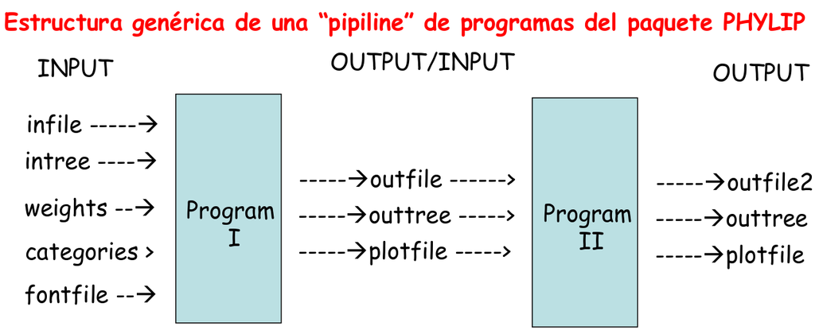

Para ello deberemos de llamar a los programas del paquete PHYLIP mostrados en la siguiente figura

[figure not shown]

1. $seqboot$ realiza el muestreo al azar con reemplazo (*bootstrapping*) de las columnas del alineamiento tantas veces como se le indique, escribiendo en su outfile ese número de alineamientos re-muestreados
2. $protdist$ calcula las matrices de distancias de cada alineamiento (pseudoréplica) bajo el modelo de sustitución indicado
3. $neighbor$ reconstruye los árboles tipo *neighbor-joining* de cada una de las matrices de distancia
4. $consense$ construye un árbol de consenso de mayoría

La llamada a cada binario se acompaña del archivo de entrada requerido, que los programas de PHYLIP esperan que se llamen *infile* o *intree*, escribiendo sus resultados en archivos *outfile* y/o *outtree*, según el programa.

Además, debemos pasarle a cada programa un archivo con los parámetros correspondientes, que controlan, según el caso, el número de réplicas de *bootstrap* a realizar, qué modelo de sustitución usar, qué tipo de árbol de distancia inferir (NJ|UPGMA), etc. Estos parámetros de le pasan a cada programa con la siguiente sintaxis:

- `seqboot < seqboot.params &> /dev/null`
- `protdist < protdist.params &> /dev/null`
- `neighbor < neighbor.params &> /dev/null`
- `consense < consense.params &> /dev/null`

Estos archivos de parámetros tienen una estructura muy sencilla, con un parámetro por línea, como muestra la siguiente imagen:

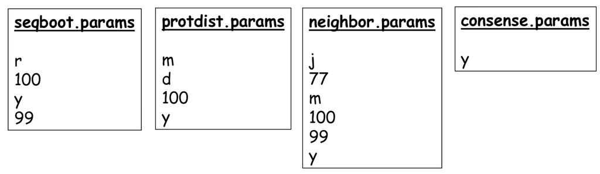

### 15.1.1 Cómo puedo saber cuáles son los parámetros que recibe un programa de phylip?

Simplemente llama al binario correspondiente con el archivo de entrada requerido ($infile$) y desplegará un menú textual como el que se muestra abajo para $seqboot$.

Teclea la letra correspondiente del menú para hacer las midificaciones que quieras a los valores por defecto. Al final deberás confirmar con “Y”. Algunos programas todavía pedirán un número impar para echar a andar.

```
cp primates.phy infile

seqboot

Bootstrapping algorithm, version 3.69

Settings for this run:
  D      Sequence, Morph, Rest., Gene Freqs?  Molecular sequences
  J  Bootstrap, Jackknife, Permute, Rewrite?  Bootstrap
  %    Regular or altered sampling fraction?  regular
  B      Block size for block-bootstrapping?  1 (regular bootstrap)
  R                     How many replicates?  100
  W              Read weights of characters?  No
  C                Read categories of sites?  No
  S     Write out data sets or just weights?  Data sets
  I             Input sequences interleaved?  Yes
  0      Terminal type (IBM PC, ANSI, none)?  ANSI
  1       Print out the data at start of run  No
  2     Print indications of progress of run  Yes

  Y to accept these or type the letter for one to change
y

Random number seed (must be odd)?
99

completed replicate number   10
completed replicate number   20
completed replicate number   30
completed replicate number   40
completed replicate number   50
completed replicate number   60
completed replicate number   70
completed replicate number   80
completed replicate number   90
completed replicate number  100

Output written to file "outfile"

Done.
```

- Veamos ahora la entrada a $dnadist$ para calcular una distancia F84+G con alpha=0.3 (CV=1.8257), aplicado a los 100 sets de alineamientos remuestreados mediante bootstrap.

```
mv outfile infile

dnadist

Nucleic acid sequence Distance Matrix program, version 3.697

Settings for this run:
  D  Distance (F84, Kimura, Jukes-Cantor, LogDet)?  F84
  G          Gamma distributed rates across sites?  No
  T                 Transition/transversion ratio?  2.0
  C            One category of substitution rates?  Yes
  W                         Use weights for sites?  No
  F                Use empirical base frequencies?  Yes
  L                       Form of distance matrix?  Square
  M                    Analyze multiple data sets?  No
  I                   Input sequences interleaved?  Yes
  0            Terminal type (IBM PC, ANSI, none)?  ANSI
  1             Print out the data at start of run  No
  2           Print indications of progress of run  Yes

  Y to accept these or type the letter for one to change
g

Nucleic acid sequence Distance Matrix program, version 3.697

Settings for this run:
  D  Distance (F84, Kimura, Jukes-Cantor, LogDet)?  F84
  G          Gamma distributed rates across sites?  Yes
  T                 Transition/transversion ratio?  2.0
  W                         Use weights for sites?  No
  F                Use empirical base frequencies?  Yes
  L                       Form of distance matrix?  Square
  M                    Analyze multiple data sets?  No
  I                   Input sequences interleaved?  Yes
  0            Terminal type (IBM PC, ANSI, none)?  ANSI
  1             Print out the data at start of run  No
  2           Print indications of progress of run  Yes

  Y to accept these or type the letter for one to change
t
Transition/transversion ratio?
4.5


Nucleic acid sequence Distance Matrix program, version 3.697

Settings for this run:
  D  Distance (F84, Kimura, Jukes-Cantor, LogDet)?  F84
  G          Gamma distributed rates across sites?  Yes
  T                 Transition/transversion ratio?  4.5000
  W                         Use weights for sites?  No
  F                Use empirical base frequencies?  Yes
  L                       Form of distance matrix?  Square
  M                    Analyze multiple data sets?  No
  I                   Input sequences interleaved?  Yes
  0            Terminal type (IBM PC, ANSI, none)?  ANSI
  1             Print out the data at start of run  No
  2           Print indications of progress of run  Yes

  Y to accept these or type the letter for one to change
m
Multiple data sets or multiple weights? (type D or W)
d
How many data sets?
100


Nucleic acid sequence Distance Matrix program, version 3.697

Settings for this run:
  D  Distance (F84, Kimura, Jukes-Cantor, LogDet)?  F84
  G          Gamma distributed rates across sites?  Yes
  T                 Transition/transversion ratio?  4.5000
  W                         Use weights for sites?  No
  F                Use empirical base frequencies?  Yes
  L                       Form of distance matrix?  Square
  M                    Analyze multiple data sets?  Yes, 100 data sets
  I                   Input sequences interleaved?  Yes
  0            Terminal type (IBM PC, ANSI, none)?  ANSI
  1             Print out the data at start of run  No
  2           Print indications of progress of run  Yes

  Y to accept these or type the letter for one to change
y

Coefficient of variation of substitution rate among sites (must be positive)
 In gamma distribution parameters, this is 1/(square root of alpha)
1.8257
Data set # 1:

Distances calculated for species
    Tarsius_sy   ...........
    Lemur_catt   ..........
    Homo_sapie   .........
    Pan          ........
    Gorilla      .......
    Pongo        ......
    Hylobates    .....
    Macaca_fus   ....
    M_mulatta    ...
    M_fascicul   ..
    M_sylvanus   .
    Saimiri_sc

Distances written to file "outfile"

Data set # 2:

Distances calculated for species
    Tarsius_sy   ...........
    Lemur_catt   ..........
    Homo_sapie   .........
    Pan          ........
    Gorilla      .......
    Pongo        ......
    Hylobates    .....
    Macaca_fus   ....
    M_mulatta    ...
    M_fascicul   ..
    M_sylvanus   .
    Saimiri_sc

...
```

De este último ejemplo vemos que las opciones que usamos fueron las siguientes, es este orden:

```
g
t
4.5
m
d
100
y
1.8257
```

Si guardamos estos valores en un archivo que podemos llamar por ejemplo dnadist.params, podríamos repetir la corrida con el siguiente código, asumiendo que tenemos un *infile* adecuado:

`dnadist < dnadist.params`.

Te dejo como **ejercicio** que explores las opciones que controlan a los programas $protdist$, $neighbor$ y $consense$. Compara sus parámetros con los mostrados para los archivos de configuración de la figura anterior.

Con estos ejemplos debería ser suficiente para que entiendas bien cómo funcionan los programas del paquete PHYLIP. Esto es esencial para que puedas entender lo que hace el $script$ *run_phylip.sh* que veremos en la siguiente sección, que nos permite automatizar todo el proceso, incluyendo el despliegue del árbol.

No es éste el espacio para describir con mayor detalle el funcionamiento de PHYLIP ni de los métodos filogenéticos, pero te pueden servir los siguientes tutoriales que he preparado al respecto para otros cursos:

### 15.1.2 Tutorial de uso de PHYLIP desde la línea de comandos de Linux

- Tutorial_Pablo_Vinuesa_uso_paqute_Phylip.pdf que encontrarás en el directorio docs/ del repositorio.

### 15.1.3 Tutoriales sobre filogenética de Pablo Vinuesa

Aquí encontrarás mucho material: teoría y práctica. Todo libremente disponible en GitHub: - [Taller 3 - Análisis comparativo de genomas microbianos: Pangenómica y filoinformática](https://github.com/vinuesa/TIB-filoinfo)

## 15.2 El $script$ **run_phylip.sh**

Estimar una filogenia con PHYLIP “a mano”, siguiendo los pasos arriba mostrados, es sin duda tedioso y tardado, con muchas operaciones repetitivas en las que es fácil equivocarse.

El $script$ *run_phylip.sh* se encarga de automatizar $pipelines$ similares a los mostrados en las figuras anteriores.

- Para ello implementa **funciones** que, entre otras, hacen lo siguiente:
  - verifican que la versión de $bash$ que corre en la computadora sea adecuada para el $script$
  - verifican detalles de configuración como la variable $LC\_NUMERIC$ que controla cómo se manejan los números según la configuración *local*.
  - imprimen menús de ayuda
  - verifican que el archivo de entrada está en formato PHYLIP y contiene al menos 4 secuencias
  - verifican que los parámetros pasados por el usuario al $script$ sean adecuados
  - escriben los archivos de parámetros en base a los argumentos que el usuario le pasa al $script$.
  - hacen las llamadas a los programas de PHYLIP (seqboot, dnadist|protdist, consense, neighbor) en el orden correcto, pasándole los archivos de parámetros pertinentes
  - verifican que existen los archivos de entrada y salida (infile, outfile, intree, outtree), renombrándolos adecuadamente con nombres informativos
  - borra los archivos que ya no se necesitan

Al concluir los análisis, el $script$ nos despliega la(s) filogenia(s) resultantes en la pantalla. Si están instalados correctamente los programas $nw\_support$ y $nw\_display$, son llamados para que calculen los valores de soporte de las biparticiones y las escriban sobre la filogenia original, la cual es desplegada con $nw\_display$, mostrando los valores de soporte. En caso de no estar instalados, la función $extract\_tree\_from\_outfile$ extrae las líneas que contienen los árboles NJ|UPGMA y consenso de mayoría de los archivos de salida correspondientes, desplegándolos igualmente en pantalla.

A modo de ejemplo, el siguiente bloque de código muestra la función *write_dnadis_params* encargadas de escribir el archivo de parámetros para correr el programa $dnadist$ de PHYLIP. Compara el código de la función con las capturas del menú textual del programa desplegado arriba.

```
function write_dnadist_params
{
    # writes a parameter file to run dnadist, based on provided arguments
    local model=$1
    local boot=$2
    local TiTv=$3
    local sequential=$4
    local gamma=$5
    local CV=$6

    # Runmode 1 = dnadist
    if [ "$model" = 'F84' ] || [ -z "$model" ]
    then
        {
          [ "$model" = 'Kimura' ]       && echo "D"
          [ "$model" = 'Jukes-Cantor' ] && echo -ne "D\nD\n"
          [ "$model" = 'LogDet' ]       && echo -ne "D\nD\nD\n"
          [ "$TiTv" != "2" ]            && echo -ne "T\n$TiTv\n"
          [ "$gamma" != "0" ]           && echo -ne "G\n"
          [ "$boot" -gt 0 ]             && echo -ne "M\nD\n$boot\n"
          [ "$sequential" -eq 1 ]       && echo -ne "I\n"
                                           echo -ne "Y\n"
          [ "$gamma" != "0" ]           && echo -ne "$CV\n"

        } > dnadist.params
   fi
}
```

Veamos ahora el $script$ *run_phylip.sh* completo, sección por sección, comentando algunos aspectos importantes de cada una.

Debes revisar con atención cada línea y consultar secciones previas de este tutorial o la [guía de usuario de bash](https://www.gnu.org/software/bash/manual/) para aclarar dudas sobre aspectos sintácticos que te surjan. Trata además de entender la lógica de las secciones de código.

Lo ideal es que modifiques partes pequeñas del código para que entiendas cómo funciona. Copia las funciones, pégalas en la terminal y llámalas con diversos parámetros para que entiendas bien lo que hacen.

### 15.2.1 Cabecera de **run_phylip.sh** - settings globales e inicialización de variables

En esta primera sección se definen:

1. la **línea shebang**
2. *settings globales*
- con el comando $set$ para obligar al intérprete de comandos $bash$ a ser muy estricto en la interpretación de las órdenes (ver comentarios)
- LC_NUMERIC=en_US.UTF-8 y exportamos LC_NUMERIC para forzar que los decimales se lean como 1.34
3. Declaración e inicialización de variables globales

```
#!/usr/bin/env bash

#-------------------------------------------------------------------------------------------------------
#: PROGRAM: run_phylip.sh
#: AUTHOR: Pablo Vinuesa, Center for Genomic Sciences, UNAM, Mexico
#:         https://www.ccg.unam.mx/~vinuesa/ twitter: @pvinmex
#
#: PROJECT START: October 16th, 2013
#    This program has been developed mainly for teaching purposes,
#    with improvements/new features added as the script was used in
#    diverse courses taught to undergrads at https://www.lcg.unam.mx
#    (LCG-UNAM) and the International Workshops on Bioinformatics (TIB)

#: AIM: run PHYLIP's distance methods [NJ|UPGMA] for DNA and proteins (dnadist|protdist) with optional bootstrapping
#       This script was written to teach intermediate Bash scripting to my students at the
#       Bachelor's Program in Genome Sciences at the Center for Genome Sciences, UNAM, Mexico
#       https://www.lcg.unam.mx
#
#: INPUT: multiple sequence alignments (PROT|DNA) with at least 4 distinct sequences in phylip format
#
#: OUTPUT: [NJ|UPGMA] phylogenies and, if requested, bootstrap consensus trees

#: SOURCE: Freely available on GitHub @ https://github.com/vinuesa/intro2linux
#          Released under the GPLv3 License.
#          http://www.gnu.org/copyleft/gpl.html

#### DEPENDENCIES
# Assumes that the following binaries and scripts are all in $PATH, checked by check_dependencies()
#
#   1) Binaries from the PHYLIP package:
#   seqboot dnadist protdist neighbor consense
#   NOTE: Linux-compatible PHYLIP binaries are supplied in the distro\'s bin/ directory
#           https://github.com/vinuesa/intro2linux/tree/master/bin

#: TODO:
#    implement also parsimony and ML analyses and parallelize bootstrapping

#: KNOWN BUGS: None.
#    Please report any errors you may encounter through the GitHub issue pages
#-------------------------------------------------------------------------------------------------------

# make sure the user has at least bash version 4, since the script uses standard arrays (introduced in version 4),
#  but future development may require hashes, introduced in version 4
[ "${BASH_VERSION%%.*}" -lt 4 ] && echo "$HOSTNAME is running an ancient bash: ${BASH_VERSION}; ${0##*/} requires bash version 4 or higher" && exit 1

# 0. Define strict bash settings
set -e              # exit on non-zero exit status
set -u              # exit if unset variables are encountered
set -o pipefail     # exit after unsuccessful UNIX pipe command

# set and export LC_NUMERIC=en_US.UTF-8, to avoid problems with locales tha use 1,32
LC_NUMERIC=en_US.UTF-8
export LC_NUMERIC

args="$*"
progname=${0##*/} # run_phylip.sh
VERSION=2.0

# GLOBALS
#DATEFORMAT_SHORT="%d%b%y" # 16Oct13
#TIMESTAMP_SHORT=$(date +${DATEFORMAT_SHORT})

date_F=$(date +%F |sed 's/-/_/g')-   # 2013_10_20
date_T=$(date +%T |sed 's/:/./g')    # 23.28.22 (hr.min.secs)
start_time="$date_F$date_T"
#current_year=$(date +%Y)

wkdir=$(pwd)

# initialize variables
def_DNA_model=F84
def_prot_model=JTT
input_phylip=
runmode=
boot=100
CV=1
model=
DEBUG=0
sequential=0
TiTv=2
upgma=0
outgroup=0
gamma="0.0"
outgroup=1

nw_utils_ok=

declare -a outfiles # to collect the output files written to disk
```

### 15.2.2 Funciones de **run_phylip.sh** - modularización del código

Las **funciones** en programas de $Bash$ se definen siempre en la parte alta del $script$, es decir tiene que estar definidas antes de que se llamen desde el bloque de código principal. A mí me gusta agruparlas por bloques de funciones relacionadas.

Es importante localizar las variables de las funciones con $local$, para evitar que los valores de las variables modificados en las funciones interfieran con las globales.

Las funciones son fundamentales para modularizar el código y evitar llamadas repetidas al mismo bloque de código. Una función como $check\_output$ se llama múltiples veces desde *run_phylip.sh*

Puede ser conveniente separar grupos de funciones relacionadas en archivos separados, que llamaremos librerías de funciones. Estas puden ser importadas al $script$, con cualquiera de las dos llamadas equivalentes que se muestran seguidamente:

- `source /path/to/lib_name`
- `. /path/to/lib_name`

```
#---------------------------------------------------------------------------------#
#>>>>>>>>>>>>>>>>>>>>>>>>>>>> FUNCTION DEFINITIONS <<<<<<<<<<<<<<<<<<<<<<<<<<<<<<<#
#---------------------------------------------------------------------------------#
function print_dev_history()
{
    cat <<EOF_

    $progname $VERSION has been developed mainly for teaching purposes,
      with improvements/new features added as the script was used in
      diverse courses taught to undergrads at https://www.lcg.unam.mx
      and the International Workshops on Bioinformatics (TIB)

    TODO: * implement also parsimony and ML analyses
          * parallelize bootstrapping

    # v2.0 2020-11-19; * fixed bug in write_protdist_params in the if [ $model == JTT ] || [ ...] conditional
               * fixed an error in the model name input checks, changing PMG for PMB
               * fixed grep in check_nw_utils_ok and made more robust conditional checking to call the function
               * use variable expansion only once in naming outfiles outtress, saving it to a variable
             to make the code more streamlined and possibly a tiny bit faster
               * removed useless [ -s outtre|outfile ] tests for the orignal tress|outfiles in the bootstrapping block,
               as these are already checked in the first code block computing tress from the original alignment

    # v1.6 2020-11-19; * streamlined write_PHYLIP_param functions by grouping echo calls in { } > params; avoiding concatenation
    #                  * improved description of write_PHYLIP_param functionality

    # v1.5 2020-11-15; * added check_phylip_ok to validate input phylip file with -ge 4 sequences and -ge 4 characters
                   * added remove_phylip_param_files
                   * added option -I to call print_install_notes
                   * added [ "${BASH_VERSION%%.*}" -lt 4 ] && die
                   * makes more extensive use of internal Bash variables and variable expansions, including \${var/pattern/string}

    # v1.4 2020-11-14; * added function check_nw_utils_ok, to check that nw_display and nw_support can be executed
                  as they may be in path but cannot find /lib64/libc.so.6: version GLIBC_2.14
                  when the binaries are compiled with dynamic linking to the libs

    # v1.3 2020-11-14; * improved layout of output messages;
                   * improved regex in extract_tree_from_outfile (now also for NJ tree)
                   * if nw_support and nw_display are not available,
                 prints both the NJ and boot trees to screen if bootstrap analysis was performed

    # v1.2 2020-11-11; set and export LC_NUMERIC=en_US.UTF-8, to avoid problems with locales that use 1,32 instead of 1.32

    # v1.1  2020-11-11; added function extract_tree_from_oufile and calls it on NJ|UPGMA bootRepl consensus trees
                          if nw_display is not available in PATH

    #v1.0  2020-11-09; This version has thorough error checking and reporting with improved code flow
         *  re-ingeneered the main code block. It now first runs the standard distance-matrix + clustering computations
            before doing bootstrapping. This helps in rapidly detecting problematic model parameters, as reflected in negative distances
     *  displays NJ|UPGMA tree without bootstrap values, if no bootstrapping is requested
     *  added functions:
          - check_matrix to check if they contain negative values, issuing an error message
          - display_treeOI display trees with nw_display, only if they do not contain negative branch lengths, issuing an error message
          - print_dev_history to clean up the script\'s header section
     *  made 100% shellcheck-compliant; prints all error messages to >&2 (STDERR)
         *  changed/fixed defaults for CV=1 & gamma="0.0";
     *  use outfiles+=() to capture outfiles for -R 1 and -R 2 when boot -eq 0; now runs with -i -R1|2 as single opts
     *  Changed default boot=100
     *  now accepts TiTv=real like 6.7 and checks for real numbers passed to -t
     *  checks if outtree contains negative branches before attempting to display with nw_display & prints proper message

    # v0.5 2020-11-09; added functions:
         *  rdm_odd_int to compute random odd integers to pass to PHYLIP programs
         *  check_output (silently checks for expected output files, dying if not found)

    #v0.4 2020-11-08; released to the public domain @ https://github.com/vinuesa/intro2linux
           * added nw_support and nw_display calls to map and display bottstrap support values onto NJ or UPGMA trees
           * fixed several warnings issued by shellcheck
           * added strict bash interpreter calling with set -e; set -u; set -o pipefail
           * localized variables received in functions
           * explicitly set default_DNA_model=F84 and default_prot_model=JTT
           * added option -v to print version and exit

    #v0.3 September 15, 2017; improved checking of user input
    #v0.2 September 16, 2015; basic options and parameter checking for protdist phylogenies
    #v0.1 October 16, 2013; basic options and parameter checking for dnadist phylogenies
EOF_

exit 0
}
#---------------------------------------------------------------------------------#

function print_install_notes()
{
   cat <<INSTALL

    #1. PHYLIP PHYLogeny Inference Package by Joe Felensetein https://evolution.genetics.washington.edu/phylip.html

    The bin/ directory of the intro2linux distribution provides precompiled Linux-x86_64 binaries
          for seqboot dnadist protdist neighbor consense. Copy them into your \$HOME/bin directory or any other in your PATH

    If you need executables for a different architecture, visit https://evolution.genetics.washington.edu/phylip/executables.html

    #2. Newick Utilities http://cegg.unige.ch/newick_utils
    The Newick Utilities have been described in an Open-Access paper (that is, available online for everyone):
```

```
    The Newick Utilities: High-throughput Phylogenetic tree Processing in the UNIX Shell
    Thomas Junier and Evgeny M. Zdobnov
    Bioinformatics 2010 26:1669-1670
    http://bioinformatics.oxfordjournals.org/content/26/13/1669.full
    doi:10.1093/bioinformatics/btq243

    The src/ dir contains the newick-utils-1.6-Linux-x86_64-disabled-extra.tar.gz source file

    Visit http://cegg.unige.ch/newick_utils if you need other pre-compiled versions

    Brief compilation notes

    1. Copy the newick-utils-1.6-Linux-x86_64-disabled-extra.tar.gz to a suitable directory in your \$HOME
    2. cd into the directory hoding the source *tar.gz file
    3. unpack and compile with the following commands
          tar -xvzf newick-utils-1.6-Linux-x86_64-disabled-extra.tar.gz
      cd newick-utils-1.6
      ./configure --prefix=$HOME  # if you do NOT have administrator privileges
          #./configure                # if you have superuser privileges
      make
      make check
      make install                # if you do NOT have administrator privileges
      # sudo make install         # if you have superuser privileges

INSTALL

exit 0

}
#---------------------------------------------------------------------------------#

function check_output()
{
    local outfile=$1
    if [ ! -s "$outfile" ]
    then
        echo
    echo " >>> ERROR! The expected output file $outfile was not produced, will exit now!" >&2
        echo
    exit 2
    fi
}
#---------------------------------------------------------------------------------#

function check_phylip_ok()
{
    # implements a rudimentary format validation check
    local phyfile=$1
    local num_tax=
    local num_char=

    num_tax=$(awk 'NR == 1 {print $1}' "$phyfile")
    num_char=$(awk 'NR == 1 {print $2}' "$phyfile")

    if [[ ! "$num_tax" =~ ^([0-9]+)$ ]] ||  [[ ! "$num_char" =~ ^([0-9]+)$ ]]
    then
         echo "ERROR: $phyfile is not a phylip-formatted input file!"
     echo
     exit 1
    elif [[ "$num_tax" =~ ^([0-9]+)$ ]] && [ "$num_tax" -lt 4 ]
    then
         echo "ERROR: $phyfile should contain at least 4 taxa"
     exit 1
    elif [[ "$num_char" =~ ^([0-9]+)$ ]] && [ "$num_char" -lt 5 ]
    then
         echo "ERROR: $phyfile should contain at least 5 aligned residues"
     exit 1
    else
        echo "# File validation OK: $phyfile seems to be a standard phylip file ..."
        echo '-------------------------------------------------------------------------------------------'
    fi
}
#---------------------------------------------------------------------------------#

function check_dependencies
{
    # check that the following PHYLIP binaries are in $PATH; die if not
    # optional: the Newick_utilities src is found in the src/ dir
    dependencies=(seqboot dnadist protdist neighbor consense)
    for programname in "${dependencies[@]}"
    do
       local bin=
       bin=$(type -P "$programname")
       if [ -z "$bin" ]; then
          echo
          echo "# ERROR: $programname not in place!" >&2
          echo "# ... you will need to install \"$programname\" first or include it in \$PATH" >&2
          echo "# ... exiting" >&2
          exit 1
       fi
    done

    echo
    echo '# Run check_dependencies() ... looks good: all required external dependencies are in place!'
    echo '-------------------------------------------------------------------------------------------'
}
#---------------------------------------------------------------------------------#

function check_nw_utils_ok()
{
    # This function checks that nw_display and nw_support can be executed
    #  as they may be in path but cannot find /lib64/libc.so.6: version GLIBC_2.14
    #  when the binaries are compiled with dynamic linking to the libs

    # The function returns 0 when nw_support nw_display cannot be executed and 1 when they can
    # The function does not run and return anything if nw_support nw_display are not in PATH

    dependencies=(nw_support nw_display)

    local nw_utils_ok=
    local bin=

    for programname in "${dependencies[@]}"
    do
        bin=$(type -P "$programname")
        if [ -n "$bin" ]; then
       # prints something like nw_support: /lib64/libc.so.6: version `GLIBC_2.14' not found
       "$programname" 2>> "nw_utils_check.out.tmp"
        fi
    done

    # check the contents of nw_utils_check.out.tmp and set proper flag
    if [ -s nw_utils_check.out.tmp ]
    then
           # set the nw_utils_ok flag to 0 if the lib is not found, to check later in the code when nw_support and nw_display are called
           grep -i error nw_utils_check.out.tmp &> /dev/null
       nw_utils_ok=$?
       [ "$nw_utils_ok" -eq 0 ] && echo "# WARNING: ${dependencies[*]} are in PATH but cannot find /lib64/libc.so.6: version GLIBC_2.14" >&2
           rm nw_utils_check.out.tmp
           echo  "$nw_utils_ok"
    fi
}
#---------------------------------------------------------------------------------#

function rdm_odd_int()
{
  # generate a random odd integer for seqboot and neighbor
  while true
  do
     i=$RANDOM
     if (( "$i" % 2 )) # true when odd
     then
         echo "$i"
     break
     fi
done

}
#---------------------------------------------------------------------------------#

function check_matrix()
{
    # check that the distance matrix does not contain negative values due to wrong model parameters
    local matrix=$1

    if grep -El ' \-[0-9\.]+' "$matrix"
    then
        echo "ERROR: computed negative distances!" >&2
         [ "$runmode" -eq 1 ] && echo "You may need to ajust the model and|or gamma value; try lowering TiTv if > 6" >&2
         [ "$runmode" -eq 2 ] && echo "You may need to ajust the matrix and|or gamma value" >&2
    exit 3
    fi
}
#---------------------------------------------------------------------------------#

function display_treeOK()
{
     # checks that tree does not contain branches with negative lengths,
     #    as these cannot be displayed  with nw_dsiplay
     local tree=$1

     # check that there are no negative branch lengths in the nj_tree
     if ! grep -El '\-[0-9\.]+' "$tree"
     then
         echo "# displaying $tree ..."
         echo
         nw_display -w 80 -Ir "$tree"
         echo
     else
         echo "ERROR: cannot display $nj_tree with nw_dsiplay, as it contains branches with negative lengths!" >&2
         [ "$runmode" -eq 1 ] && echo "You may need to adjust (lower?) TiTv=$TiTv" >&2
         [ "$runmode" -eq 2 ] && echo "You may need to use another matrix or adjunst gamma" >&2
         exit 4
     fi
}
#---------------------------------------------------------------------------------#
```

```
function extract_tree_from_outfile()
{
    # grep out lines containing tree characters | - and print to STDOUT
    local outfile=$1

    grep --color=never -E '[[:blank:]]+\||-' "$outfile" | grep -Ev 'Neighbor-|^---'
}

#------------------------------------- PHYLIP FUNCTIONS ---------------------------------------#
# >>> these are fucntions to write the command files to pass parameters to PHYLIP programs <<< #

function remove_phylip_param_files()
{
   [ -s dnadist.params ] && rm dnadist.params
   [ -s protdist.params ] && rm protdist.params
   [ -s seqboot.params ] && rm seqboot.params
   [ -s neighbor.params ] && rm neighbor.params
   [ -s consense.params ] && rm consense.params
   return 0
}
#------------------------------------- PHYLIP FUNCTIONS ---------------------------------------#

function write_dnadist_params
{
    # writes a parameter file to run dnadist, based on provided arguments
    local model=$1
    local boot=$2
    local TiTv=$3
    local sequential=$4
    local gamma=$5
    local CV=$6

    # Runmode 1 = dnadist
    if [ "$model" = 'F84' ] || [ -z "$model" ]
    then
        {
          [ "$model" = 'Kimura' ]       && echo "D"
          [ "$model" = 'Jukes-Cantor' ] && echo -ne "D\nD\n"
          [ "$model" = 'LogDet' ]       && echo -ne "D\nD\nD\n"
          [ "$TiTv" != "2" ]            && echo -ne "T\n$TiTv\n"
          [ "$gamma" != "0" ]           && echo -ne "G\n"
          [ "$boot" -gt 0 ]             && echo -ne "M\nD\n$boot\n"
          [ "$sequential" -eq 1 ]       && echo -ne "I\n"
                                           echo -ne "Y\n"
          [ "$gamma" != "0" ]           && echo -ne "$CV\n"

        } > dnadist.params
   fi
}
#---------------------------------------------------------------------------------#

function write_protdist_params
{
    # write_protdist_params "$model" "$boot" "$sequential" "$gamma" "$CV"
    # writes a parameter file to run protdist, based on provided arguments
    # Models: JTT, PMB, PAM, Kimura
    local model=$1
    local boot=$2
    local sequential=$3
    local gamma=$4
    local CV=$5

    if [ "$model" = 'JTT' ] || [ -n "$model" ]
    then
       { # Runmode 2 = protdist
         [ "$model" = 'PMB' ]     && echo "P"
         [ "$model" = 'PAM' ]     && echo -ne "P\nP\n"
         [ "$model" = 'Kimura' ]  && echo -ne "P\nP\nP\n"
         [ "$gamma" != "0" ]      && echo -ne "G\n"
         [ "$boot" -gt 0 ]        && echo -ne "M\nD\n$boot\n"
         [ "$sequential" -eq 1 ]  && echo -ne "I\n"
                                     echo -ne "Y\n"
         [ "$gamma" != "0" ]      && echo -ne "$CV\n"
       } > protdist.params
    fi
}
#---------------------------------------------------------------------------------#

function write_seqboot_params
{
    # writes a parameter file to run seqboot, based on provided arguments
    local boot=$1
    local sequential=$2

    # Write Seqboot params
    {
      [ "$boot" -gt 0 ]       && echo -ne "R\n$boot\n"
      [ "$sequential" -eq 1 ] && echo -ne "I\n"
                                 echo -ne "Y\n"
                                 echo -ne "$ROI\n"
    } > seqboot.params
}
#---------------------------------------------------------------------------------#

function write_neighbor_params
{
    # writes a parameter file to run neighbor, based on provided arguments
    local boot=$1
    local upgma=$2
    local outgroup=$3

    {
       # Write $ROI params
       [ "$upgma" -gt 0 ]    && echo -ne "N\n"
       [ "$outgroup" -gt 1 ] && echo -ne "O\n$outgroup\n"
       [ "$boot" -gt 0 ]     && echo -ne "M\n$boot\n$ROI\n"
                                echo -ne "Y\n"
    } > neighbor.params
}
#---------------------------------------------------------------------------------#

function write_consense_params
{
    #writes a parameter file to run consense; very difficult ;)
    [ -s consense.params ] && rm consense.params
    {
      [ "$outgroup" -gt 1 ]  && echo -ne "O\n$outgroup\n"
                                echo -ne "Y\n"
    } > consense.params
}
#---------------------------------------------------------------------------------#

# don't leave litter behind ... remove intermediate input/output files
function cleanup_dir
{
   [ -s infile ]  && rm infile
   [ -s outfile ] && rm outfile
   [ -s intree ]  && rm intree
   [ -s outtree ] && rm outtree

   for file in *.params
   do
       [ -s "$file" ] && rm "$file"
   done
}

#-------------------------------- END PHYLIP FUNCTIONS----------------------------#

function print_help
{
   #':b:c:m:I:o:R:t:hHIDsuv'
   cat<<EOF
   $progname v.$VERSION [OPTIONS]

   -h  prints this help message

 REQUIRED
   -i <input_phylip_file> (if sequential, use also flag -s)
   -R <integer>  RUNMODE
        1    run dnadist  (expects DNA  alignment in phylip format)
    2    run protdist (expects PROT alignment in phylip format)

 OPTIONAL
   -b <integer> No. of bootstrap pseudoreplicates [default: $boot]
   -g <real number> alpha for gamma distribution  [default: $gamma]
   -o <integer> outgroup sequence no.             [default: $outgroup]
   -s sequential format; -s (flag; no val)!       [default: interleaved]
   -t <digit> Transition/Transversion ratio       [default: $TiTv]
   -m <model name>  NOTE: TYPE AS SHOWN!
        DNA:  F84, Kimura, Jukes-Cantor, LogDet   [default: $def_DNA_model]
        PROT: JTT, PMB, PAM, Kimura               [default: $def_prot_model]
   -u <flag> use UPGMA for clustering             [default:  NJ]
   -v <flag> print program version and exit
   -D <flag> Activate debugging to keep cmd files [default: $DEBUG]
   -H <flag> print development history and exit
   -I <flag> print installation notes and exit

 AIM: run PHYLIP\'s distance methods [NJ|UPGMA] for DNA and proteins with bootstrapping
      This code was written to teach basic Bash scripting to my students at the
      Bachelor\'s Program in Genome Sciences, Center for Genome Sciences, UNAM, Mexico
      https://www.lcg.unam.mx/

 OUTPUT: [NJ|UPGMA] phylogenies and, if requested, bootstrap consensus trees
         and  [NJ|UPGMA] phylogenies with bootstrap support values mappend on bipartitions
```

```
 EXTERNAL DEPENDENCIES:
   * PHYLIP (https://evolution.genetics.washington.edu/phylip.html) programs:
      seqboot dnadist protdist neighbor consense
   * Newick utilities programs (http://cegg.unige.ch/newick_utils) programs:
      optional: nw_support and nw_display; need to install separately
   - Notes: PHYLIP Linux 64bit binaries available in the bin/ dir
            Copy them to your \$HOME/bin directory or any other in your PATH

 LICENSING & SOURCE
       Author: Pablo Vinuesa | https://www.ccg.unam.mx/~vinuesa/ | twitter: @pvinmex
       Released under the GNU General Public License version 3 (GPLv3)
       http://www.gnu.org/copyleft/gpl.html
       source: https://github.com/vinuesa/intro2linux

EOF

exit 1
}
```

### 15.2.3 El bloque de *getopts* - procesado y validación de opciones y argumentos pasados al $script$ por el usuario

Este bloque contiene código clave para procesar y validar las opciones y argumentos que el usuario le pasa al $script$. Es crítico que el programador verifique que el $script$ recibe los parámetros requeridos y que cada opción y parámetro tengan valores razonables. Verás una gran cantidad de condicionales para verificar los datos recibidos por el $script$.

Es muy deseable además, que el $script$ imprima mensajes de error informativos para el usuario, con el fin de hacerle claro y sencillo el manejo del programa.

Noten la sentencia `ROI=$(rdm_odd_int)` que define a la variable global *ROI*, que almacena un íntegro impar aleatorio generado por la función *rdm_odd_int*. Este número impar es requerido por varios programas del paquete PHYLIP como $seqboot$ y $neighbor$.

En un bloque final, si se pasan los *tests*, se imprimen los valores de las opciones, para que quede clara la parametrización de la corrida del $script$.

```
#-------------------------------------------------------------------------------------------------#
#---------------------------------------- GET OPTIONS --------------------------------------------#
#-------------------------------------------------------------------------------------------------#

# GETOPTS
while getopts ':b:g:i:m:R:o:t:hDHIsuv' OPTIONS
do
   case $OPTIONS in

   b)   boot=$OPTARG
        ;;
   g)   gamma=$OPTARG
    [ "$gamma" != 0 ] && CV=$(echo "1/sqrt($gamma)" | bc -l) && printf -v CV "%.4f\n" "$CV"
        ;;
   h)   print_help
        ;;
   i)   input_phylip=$OPTARG
        ;;
   s)   sequential=1
        ;;
   m)   model=$OPTARG
        ;;
   o)   outgroup=$OPTARG
        ;;
   R)   runmode=$OPTARG
        ;;
   t)   TiTv=$OPTARG
        ;;
   u)   upgma=1
        ;;
   v)   echo "$progname v$VERSION" && exit
        ;;
   D)   DEBUG=1
        ;;
   H)   print_dev_history
        ;;
   I)   print_install_notes
        ;;
   :)   printf "argument missing from -%s option\n" "$OPTARG"
    print_help
        exit 2
        ;;
   \?)  echo "need the following args: "
    print_help
        exit 3
    ;;
   esac >&2   # print the ERROR MESSAGES to STDERR

done

shift $((OPTIND - 1))

#--------------------------#
# >>> Check User Input <<< #
#--------------------------#

if [ -z "$input_phylip" ]
then
       echo
       echo "# ERROR: no input phylip file defined!"
       print_help
       exit 1
fi

if [ -z "$runmode" ]
then
       echo
       echo "# ERROR: no runmode defined!"
       print_help
       exit 1
fi

# automatically set TiTv=0 when running with protein matrices or the LogDet DNA model
[ "$runmode" -eq 2 ] && TiTv=0
[ "$model" == LogDet ] && TiTv=0


# check that bootstrap value is an integer
re='^[0-9]+$'
if [[ ! "$boot" =~ $re ]]
then
   echo
   echo "# ERROR: boot:$boot is not a positive integer >= 0; provide a value between 100 and 1000" >&2
   echo
   print_help
   echo
   exit 3
fi

# check that Ti/Tv is a real number, integer or decimal
re_TiTv='^[0-9.]+$'
if [[ ! "$TiTv" =~ $re_TiTv ]] && [ "$runmode" -eq 1 ]
then
   echo
   echo "# ERROR: TiTv:$TiTv is not an integer >= 0; provide a value between 0-10" >&2
   echo
   print_help
   echo
   exit 3
elif [[ "$TiTv" =~ $re_TiTv ]] && [ "$runmode" -eq 1 ] && { [ "$model" == Jukes-Cantor ] || [ "$model" == LogDet ]; }
then
       echo
       echo "# ERROR: $model is only valid when analyzing DNA alignments under the F84 or K2P models" >&2
       echo
       print_help
       exit 1
fi

if [ "$gamma" != 0 ] # note, need to treat as string, since gamma will be generalle a float like 0.5
then
    # this is to avoid having dots within filename (converts gamma==0.2 to gammaf=02)
    gammaf=${gamma/\./} #gammaf=${gamma%.*}${gamma##*.}
else
    gammaf="$gamma"
fi

# check model vs. runmode compatibility and suitable bootstrap values are provided
#   using two alternative sintaxes for educational purposes
if [ "$runmode" -eq 1 ] && { [ "$model" = JTT ] || [ "$model" = PMB ] || [ "$model" = PAM ] || [ "$model" = "$def_prot_model" ]; }
then
       echo
       echo "# ERROR: $model is only valid when analyzing protein alignments under -R 2" >&2
       echo
       print_help
       exit 1
elif [ "$runmode" -eq 2 ] && [[ "$model" =~ ^(F84|Jukes-Cantor|LogDet|"$def_DNA_model")$ ]]
then
       echo
       echo "# ERROR: $model is only valid when analyzing DNA alignments under -R 1" >&2
       echo
       print_help
       exit 1
elif [ "$boot" -lt 0 ]
then
       echo
       echo "# ERROR: bootstrap value=$boot is < 0 and not permitted" >&2
       echo
       print_help
       exit 1
elif [ "$boot" -gt 1000 ]
then
       echo
       echo "# WARNING: bootstrap value=$boot is > 1000. This may take a long time to run."
       echo -n "# Are you sure you want to continue anyway? Type Y|N "
       read -r answer
       if [ "$answer" = N ] || [ "$answer" = n ]
       then
           echo
       echo "# Ok, will exit then!"
       echo
       exit 2
       else
           echo
       echo "# Ok, will proceed running with $boot bootstrap pseudoreplicates ..."
       echo
       fi
elif [ "$boot" -gt 0 ] && [ "$boot" -lt 100 ]
then
       echo
       echo "# WARNING: bootstrap value=$boot is a bit low. Use a value >= 100."
       echo -n "# Are you sure you want to continue anyway? Type Y|N "
       read -r answer
       if [ "$answer" = N ] || [ "$answer" = n ]
       then
           echo
       echo "# Ok, will exit then!"
       echo
       exit 2
       else
           echo
       echo "# Ok, will proceed ..."
       echo
       fi
fi

# set the default DNA or PROT models, if not defined by the user
if [ "$runmode" -eq 1 ] && [ -z "$model" ]
then
       model="$def_DNA_model"
       #echo "# DNA model set to default: $def_DNA_model..."
fi

if [ "$runmode" -eq 2 ] && [ -z "$model" ]

then
       model="$def_prot_model"
       #echo "# Protein matrix set to default: $def_prot_model ..."
fi

# check that the user provided a valid DNA substitution model
if [ "$runmode" -eq 1 ] && [[ ! "$model" =~ ^(F84|Kimura|Jukes-Cantor|LogDet|"$def_DNA_model")$ ]]
then
   echo
   echo "# ERROR: $model is not a recognized substitution model for DNA sequences used by PHYLIP" >&2
   echo
   print_help
   echo
   exit 3
fi

# check that the user provided a valid name for empirical substitution matrix
#    note the much shorter and cleaner notation of this test using extended regexes, than the previous one
if [ "$runmode" -eq 2 ] && [[ ! "$model" =~ ^(JTT|PMB|PAM|Kimura)$ ]]
then
   echo
   echo "# ERROR: $model is not a recognized substitution matrix for protein sequences used by PHYLIP" >&2
   echo
   print_help
   echo
   exit 3
fi

#>>> Set the script's run random odd number required by diverse PHYLIP programs <<<
ROI=$(rdm_odd_int)

# print the run settings
echo
echo "### $progname v.$VERSION run on $start_time with the following parameters:"
echo "# work_directory=$wkdir"
echo "# input_phylip=$input_phylip"
echo "# model=$model | gamma=$gamma | CV=$CV | gammaf=$gammaf | ti/tv ratio=$TiTv |
     outgroup=$outgroup | UPGMA=$upgma | bootstrap no.=$boot | ROI=$ROI"
echo "# runmode=$runmode"
echo "# DEBUG=$DEBUG"
echo "# command: $progname ${args[*]}"
echo
```

*run_phylip* requiere necesariamente definir dos opciones:

- -i el archivo de entrada con secuencias alineadas en formato *phylip*
- -R definir un *runmode*:
  - -R 1 para secuencias de **DNA**, llamando a *dnadist* o
  - -R 2 para secuencias de **proteína**, llamando a *protdist*

Si no se pasan estos argumentos, el $script$ muere grácilmente imprimiendo un mensaje de ayuda

- *run_phylip* puede aceptar otras opciones que le permiten al usuario definir:
  - el modelo de sustitución (para DNA o Proteína)
  - el número de pseudoréplicas de *bootstrap* a correr (por defecto corre 100 réplicas)
  - el tipo de árbol a construir: NJ|UPGMA

Todas estas opciones vienen definidas y explicadas en el menú de ayuda. El bloque *getopts* recibe las opciones pasadas por el usuario y verifica que sean adecuadas.

### 15.2.4 El bloque principal de *run_phylip.sh*

El siguiente bloque les muestra el código principal, que hace las llamadas a las funciones mostradas en la sección anterior y controla el flujo del programa acorde a las opciones y parámetros pasado al $script$ por el usuario, procesados y validados en la sección anterior.

El $script$ *run_phylip.sh* consta de dos bloques principales. 1. El primero calcula la matriz de distancias (-R 1 = DNA; -R 2 = prot) y el árbol (NJ|UPGMA) correspondiente directamente a partir de los datos del alineamiento en formato PHYLIP que le pasa el usuario al $script$ (-i input_phylip). 2. El segundo se corre cuando el usuario le pide al $script$ hacer un **análisis de bootstrap**, el cual se realiza por defecto con 100 pseudoréplicas. Este bloque no se corre cuando el usuario le pasa $-b\ 0$ el $script$

Este bloque además se encarga de verificar que se van produciendo los resultados esperados, imprimiendo algunos mensajes del progreso del programa.

Si se corren réplicas de *bootstrap*, los valores de consenso se remapean sobre la filogenia NJ o UPGMA inferida directamente de los datos, usando $nw\_support$. Esta filogenia, con sus valores de *bootstrap*, se despliega en pantalla con $nw\_display$.

Una vez concluido el trabajo, se limpia el directorio, borrando los archivos temporales como los de argumentos escritos para cada uno de los programas de PHYLIP.

Finalmente se imprime un resumen de los archivos escritos a disco, cuyos nombres se fueron almacenados en el *arreglo* $outfiles$ a medida que se iban generando a lo largo del programa.

#### 15.2.4.1 Sección 1 del cuerpo principal del $script$, encargado de calcular una filogenia de distancias directamente del alineamiento (sin réplias de bootstrap)

En este bloque se calculan primero las matrices de distancia con la parametrización indicada por el usuario llamando a $dnadist$ o a $protdist$ desde funciones, según los datos sean de DNA o proteína.

La función $check\_matrix$ verifica que no se hayan estimado distancias negativas.

Finalmente se llama a $neighbor$ para que reconstruya el árbol (NJ|UPGMA).

Si el usuario le pasa $-b\ 0$ el $script$, éste termina desplegando el árbol de distancia en pantalla llamando a $nw\_display$ e imprime un resumen de los archivos escritos a disco.

```
#-------------------------------------------------------------------------------------------------#
#------------------------------------------ MAIN CODE --------------------------------------------#
#-------------------------------------------------------------------------------------------------#

# 1. make sure the external dependencies are found in PATH
#     and that nw_display and nw_support find the required GLIBC_2.14 in /lib64/libc.so.6
check_dependencies
nw_utils_ok=$(check_nw_utils_ok) # nw_utils_ok -eq 1 when OK, -eq 0 when not

# 2. Start processing the input file
# make sure there are no old outfile or outtree files lying around from previous runs
[ -s infile ] && rm infile
[ -s outfile ] && rm outfile
[ -s outtree ] && rm outtree
# nor old params files
remove_phylip_param_files

# 2.1) make sure we have an input file or die
if [ -s "$input_phylip" ]
then
     # make basic format validation check
     check_phylip_ok "$input_phylip"
     cp "$input_phylip" infile
else
     echo
     echo "# FATAL ERROR: input phylip file $input_phylip does not exist or is empty" >&2
     echo "# Make sure $input_phylip is in $wkdir. Exiting ..." >&2
     echo
     exit 1
fi

# ----------------------------------------------------------- #
# >>>>>>>>>>>>>>>> Compute distance matrices <<<<<<<<<<<<<<<< #
# ----------------------------------------------------------- #

# 3. In any case (with or without bootstrap) compute the NJ tree for the original phylip file
#     Run dnadist or protdist, as required
echo
echo ">>> Computing distance matrix for $input_phylip ..."

if [ "$runmode" -eq 1 ]
then
    echo "# running write_dnadist_params $model 0 $TiTv $sequential $gamma $CV"
    write_dnadist_params "$model" "0" "$TiTv" "$sequential" "$gamma" "$CV"
    echo "# running dnadist < dnadist.params"
    dnadist < dnadist.params &> /dev/null
    check_output outfile

    # https://fvue.nl/wiki/Bash:_Error_%60Unbound_variable%27_when_appending_to_empty_array
    # Set last item specifically
    # nstead of appending one element, set the last item specifically, without any "unbound variable" error
    # t[${#t[*]}]=foo
    dnadist_outfile="${input_phylip%.*}_${model}${gammaf}gamma_distMat.out"
    cp outfile "$dnadist_outfile" && \
      outfiles+=("$dnadist_outfile")

    # check that the distance matrix does not contain negative values due to wrong model parameters
    check_matrix "$dnadist_outfile"

    mv outfile infile
elif [ "$runmode" -eq 2 ]
then
    echo "# running write_protdist_params $model 0 $sequential $gamma $CV"
    write_protdist_params "$model" "0" "$sequential" "$gamma" "$CV"
    echo "# running protdist < protdist.params"
    protdist < protdist.params &> /dev/null
    check_output outfile

    protdist_outfile="${input_phylip%.*}_${model}${gammaf}gamma_distMat.out"
    cp outfile "$protdist_outfile" && \
      outfiles+=("$protdist_outfile")

    # check that the distance matrix does not contain negative values due to wrong model parameters
    check_matrix "$protdist_outfile"

    mv outfile infile
fi


# ------------------------------------------------------------------------------------ #
# >>>>>>>>>>>>>>>> Computing NJ|UPGMA trees from original alignments <<<<<<<<<<<<<<<<< #
# ------------------------------------------------------------------------------------ #

echo
echo ">>> Computing distance tree for $input_phylip ..."

# 4. now that we have the dist matrix, do the clustering with NJ or UPGMA
echo "# running write_neighbor_params 0 $upgma"
write_neighbor_params "0" "$upgma" "$outgroup"
echo "# running neighbor < neighbor.params"
neighbor < neighbor.params &> /dev/null
check_output outfile
check_output outtree

# 5.1 rename outtrees and tree outfiles; remap bootstrap values to bipartitions and display tree to screen
if [ "$upgma" -gt 0 ]
then
     # https://fvue.nl/wiki/Bash:_Error_%60Unbound_variable%27_when_appending_to_empty_array
     # Set last item specifically
     # instead of appending one element, set the last item specifically, without any "unbound variable" error
     # t[${#t[*]}]=foo
     upgma_tree=
     upgma_outfile=

     if [ -s outtree ]
     then
          upgma_tree="${input_phylip%.*}_${model}${gammaf}gamma_UPGMA.ph"
          mv outtree "$upgma_tree"
      echo "# wrote tree $upgma_tree to disk"
      outfiles[${#outfiles[*]}]="$upgma_tree"
     fi

     if [ -s outfile ]
     then
         upgma_outfile="${input_phylip%.*}_${model}${gammaf}gamma_UPGMA.outfile"
         mv outfile "$upgma_outfile"
         outfiles[${#outfiles[*]}]="$upgma_outfile"
     fi

     # check that there are no negative branch lengths in the nj_tree
     #  and display with nw_display, only if no bootstrapping is requested
     if [ "$boot" -eq 0 ] && [[ $(type -P nw_display) ]] && [[ "$nw_utils_ok" -eq 1 ]]
     then
         display_treeOK "$upgma_tree"
     elif [ "$boot" -eq 0 ] && { [[ ! $(type -P nw_display) ]] || [[ "$nw_utils_ok" -ne 1 ]]; }
     then
          echo "# extract_tree_from_outfile $upgma_outfile"
      echo
      extract_tree_from_outfile "$upgma_outfile"
      echo
     fi
else
     nj_tree=
     nj_outfile=

     if [ -s outtree ]
     then
      nj_tree="${input_phylip%.*}_${model}${gammaf}gamma_NJ.ph"
          mv outtree "$nj_tree"
          echo "# wrote tree $nj_tree to disk"
          outfiles[${#outfiles[*]}]="$nj_tree"
     fi

     if [ -s outfile ]
     then
          nj_outfile="${input_phylip%.*}_${model}${gammaf}gamma_NJ.outfile"
          mv outfile "$nj_outfile"
          outfiles[${#outfiles[*]}]="$nj_outfile"
     fi

     # check that there are no negative branch lengths in the nj_tree
     #  and display with nw_display, only if no bootstrapping is requested
     if [ "$boot" -eq 0 ] && [[ $(type -P nw_display) ]] && [[ "$nw_utils_ok" -eq 1 ]]
     then
         display_treeOK "$nj_tree"
     elif [ "$boot" -eq 0 ] && { [[ ! $(type -P nw_display) ]] || [[ "$nw_utils_ok" -ne 1 ]]; }
     then
         echo "# extract_tree_from_outfile $nj_outfile"
     echo
     extract_tree_from_outfile "$nj_outfile"
     echo
     fi
fi

echo "# > finished computing distance matrix and tree for $input_phylip!"

if [ "$boot" -eq 0 ]
then
    # 6. Print final output summary message
    echo
    echo '===================== OUTPUT SUMMARY ====================='
    no_outfiles=${#outfiles[@]}
    echo "# $no_outfiles output files were generated:"
    printf "%s\n" "${outfiles[@]}"

    echo
    echo -n "# FINISHED run at: "; date
    echo "   ==> Exiting now ..."
    echo
else
    echo "=================================================================="
    echo
fi
```

#### 15.2.4.2 Sección 2 del código principal - análisis de bootstrap

Este bloque sólo se corre si [ “$boot” -gt 0 ]. Por defecto el $script$ está programado para realizar 100 pseudoréplicas de *bootstrap* del alineamiento original, las cuales se ejecutan inmediatamente después de haber reconstruido las filogenias NJ|UPGMA a parir del alineamiento original en el bloque inicial.

Al igual que en el bloque anterior, el $script$ se encarga de hacer copias de los archivos infile|outfile|outtree con nombres informativos, que contienen el modelo y número de réplicas de *bootstrap* usados, y los guarda en el arreglo *outfiles*. Además verifica que cada archivo de salida fue realmente escrito con la función *check_output*.

Una vez estimada la filogenia de consenso de mayoría a partir de las réplicas de *bootstrap* el $script$ verifica si se encuentran en el PATH las aplicaciones externas *nw_support* y *nw_display*, llamándolas en su caso para desplegar el árbol original con los valores de soporte de *bootstrap* indicados sobre las biparticiones correspondientes. Si no se encuentran en el PATH, o no están correctamente instaladas (esto lo checa la función check_nw_utils_ok()), usa la función *extract_tree_from_outfile()* que, como indica su nombre, extrae las líneas que contienen el árbol que PHYLIP escribe en los archivos *outfile* correspondientes.

Finalmente el $script$ hace un resumen de los archivos escritos a disco.

```
# ----------------------------------------------------------- #
# >>>>>>>>>>>>>>>>>>>> Bootstrap Analysis <<<<<<<<<<<<<<<<<<< #
# ----------------------------------------------------------- #

# Run seqboot if requested
# run seqboot if -b > 0

if [ "$boot" -gt 0 ]
then
     # 1. restore the original infile for the bootstrapping and standard NJ/UPGMA analysis below
     cp "$input_phylip" infile
     check_output infile

     echo
     echo ">>> Bootstrap Analysis based on $boot pseudoreplicates for $input_phylip ..."
     echo "# running  write_seqboot_params $boot $sequential"
     write_seqboot_params "$boot" "$sequential"
     echo "# running seqboot < seqboot.params &> /dev/null"
     seqboot < seqboot.params &> /dev/null
     check_output outfile
     mv outfile infile

     echo "# > computing distance matrices on $boot bootstrapped alignments ..."
     # 2. if bootstrapping, then compute consensus tree
     # we need to run dnadist or protdist, depending on runmode
     if [ "$runmode" -eq 1 ]
     then
     echo "# running write_dnadist_params $model $boot $TiTv $sequential $gamma $CV"
         write_dnadist_params "$model" "$boot" "$TiTv" "$sequential" "$gamma" "$CV"
     echo "# running dnadist < dnadist.params &> /dev/null"
         dnadist < dnadist.params &> /dev/null
     check_output outfile

     # check that matrix does not contain negative values
     check_matrix outfile

     mv outfile infile
     elif [ "$runmode" -eq 2 ]
     then
     echo
     echo "# running write_protdist_params $model $boot $sequential $gamma $CV"
         write_protdist_params "$model" "$boot" "$sequential" "$gamma" "$CV"
     echo "# running protdist < protdist.params &> /dev/null"
         protdist < protdist.params &> /dev/null
     check_output outfile

     # check that matrix does not contain negative values
     check_matrix outfile

     mv outfile infile
     fi

     # 3. Now we have the distance matrices and we can proceed equaly for runmodes 1 and 2
     #    >>> Run neighbor
     echo "# > Computing distance trees from bootstrapped data ..."
     echo "# running write_neighbor_params $boot $upgma $outgroup"
     write_neighbor_params "$boot" "$upgma" "$outgroup"
     echo "# running neighbor < neighbor.params &> /dev/null"
     neighbor < neighbor.params &> /dev/null
     check_output outtree

     boot_trees=
     if [ -s outtree ]
     then
            # this is the file holding the trees for the n-distance matrices for n-boot replicated alignments
            boot_trees="${input_phylip%.*}_${model}${gammaf}gamma_${boot}bootRepl_trees.nwk"
            cp outtree "$boot_trees"

            # append to array with +=, otherwise will complain as unset with set -u
            # https://fvue.nl/wiki/Bash:_Error_%60Unbound_variable%27_when_appending_to_empty_array
            outfiles+=("$boot_trees")
     fi
     mv outtree intree
     rm outfile

     # 4. Compute consensus tree with consense
     echo "# > Computing MJR consensus tree from trees reconstructed from bootstrap pseudoreplicates ..."
     echo "# running write_consense_params"
     write_consense_params
     echo "# running consense < consense.params &> /dev/null"
     consense < consense.params &> /dev/null
     check_output outtree
     check_output outfile

     # variables holding consensus trees
     upgma_consensus_tree=
     upgma_consensus_outfile=
     nj_consensus_tree=
     nj_consensus_outfile=

     if [ "$upgma" -gt 0 ]
     then
           # https://fvue.nl/wiki/Bash:_Error_%60Unbound_variable%27_when_appending_to_empty_array
         # Set last item specifically
           # instead of appending one element, set the last item specifically, without any "unbound variable" error
           # t[${#t[*]}]=foo
           upgma_consensus_tree="${input_phylip%.*}_UPGMAconsensus_${model}${gammaf}gamma_${boot}bootRepl.ph"
           mv outtree "$upgma_consensus_tree"
           outfiles[${#outfiles[*]}]="$upgma_consensus_tree"

           upgma_consensus_outfile="${input_phylip%.*}_UPGMAconsensus_${model}${gammaf}gamma_${boot}bootRepl.outfile"
           mv outfile "$upgma_consensus_outfile"
           outfiles[${#outfiles[*]}]="$upgma_consensus_outfile"
     else
         nj_consensus_tree="${input_phylip%.*}_NJconsensus_${model}${gammaf}gamma_${boot}bootRepl.ph"
           mv outtree "$nj_consensus_tree"
           outfiles[${#outfiles[*]}]="$nj_consensus_tree"

           nj_consensus_outfile="${input_phylip%.*}_NJconsensus_${model}${gammaf}gamma_${boot}bootRepl.outfile"
           mv outfile "$nj_consensus_outfile"
           outfiles[${#outfiles[*]}]="$nj_consensus_outfile"
     fi

     # 5. Rename outtrees and tree outfiles; remap bootstrap values to bipartitions and display tree on screen
     if [ "$upgma" -gt 0 ]
     then
          # if we requested bootstrapping, map bootstrap values onto UPGMA tree using
          #   nw_support upgma.ph bootRepl_tree.ph > UPGMA_with_boot_support.ph
          if [ -s "$upgma_tree" ] && [ -s "$boot_trees" ] && [[ $(type -P nw_support) ]] && [ "$nw_utils_ok" -eq 1 ]
          then
                upgma_tree_with_boot="${input_phylip%.*}_${model}${gammaf}gamma_UPGMA_with_${boot}boot_support.ph"
                echo "# mapping bootstrap values on UPGMA tree with nw_support ..."
                nw_support "$upgma_tree" "$boot_trees" > "$upgma_tree_with_boot"

                if [ -s "$upgma_tree_with_boot" ] && [[ $(type -P nw_display) ]] && [ "$nw_utils_ok" -eq 1 ]
                then
                    outfiles[${#outfiles[*]}]="$upgma_tree_with_boot"

                      # check that there are no negative branch lengths in the nj_tree
                      #   before displaying with nw_display
                      display_treeOK "$upgma_tree_with_boot"
                fi
            elif [ -s "$upgma_outfile" ] && [ -s "$upgma_consensus_outfile" ] && { [[ ! $(type -P nw_support) ]] || [ "$nw_utils_ok" -ne 1 ]; }
            then
               echo "# extract_tree_from_outfile $upgma_outfile"
                 echo
                 extract_tree_from_outfile "$upgma_outfile"
                 echo
                 echo "# extract_tree_from_outfile $upgma_consensus_outfile"
                 echo
                 extract_tree_from_outfile "$upgma_consensus_outfile"
                 echo
            fi
     else
         # if we requested bootstrapping, map bootstrap values onto NJ tree using
         #   nw_support NJ.ph bootRepl_tree.ph > NJ_with_boot_support.ph
         if [ -s "$nj_tree" ] && [ -s "$boot_trees" ] && [[ $(type -P nw_support) ]] && [ "$nw_utils_ok" -eq 1 ]
         then
             nj_tree_with_boot="${input_phylip%.*}_${model}${gammaf}gamma_NJ_with_${boot}boot_support.ph"
               echo "# mapping bootstrap values on NJ tree with nw_support ..."
               nw_support "$nj_tree" "$boot_trees" > "$nj_tree_with_boot"

               check_output "$nj_tree_with_boot"

               if [ -s "$nj_tree_with_boot" ] && [[ $(type -P nw_display) ]] && [ "$nw_utils_ok" -eq 1 ]
               then
                   outfiles+=("$nj_tree_with_boot")

                     # check that there are no negative branch lengths in the nj_tree
                     #   before displaying with nw_display
                     display_treeOK "$nj_tree_with_boot"
               fi
            elif [ -s "$nj_outfile" ] && [ -s "$nj_consensus_outfile" ] && { [[ ! $(type -P nw_support) ]] || [ "$nw_utils_ok" -ne 1 ]; }
            then
                echo "# extract_tree_from_outfile $nj_outfile"
                  echo
                  extract_tree_from_outfile "$nj_outfile"
                    echo

                    echo "# extract_tree_from_outfile $nj_consensus_outfile"
                    echo
                    extract_tree_from_outfile "$nj_consensus_outfile"
                    echo
         fi
    fi
fi

# 6. Tidy up: remove the *params files and other temporary files
# that could interfere with future runs and litter the directory

[ "$DEBUG" -eq 0 ] && cleanup_dir

# 7. Print final output summary message
echo
echo '===================== OUTPUT SUMMARY ====================='

no_outfiles=${#outfiles[@]}
echo "# $no_outfiles output files were generated:"
printf "%s\n" "${outfiles[@]}"

echo
echo -n "# FINISHED run at: "; date
echo "   ==> Exiting now ..."
echo
```

### 15.2.5 Llamada a *run_phylip* para construir filogenia NJ de proteínas con 100 réplicas de bootstrap y modelo JTT+G (alpha=0.6)

La siguiente línea muestra una llamada a *run_phylip* para hacer lo arriba indicado usando el archivo *phylip* GDP_12_prokEuc.phy, que con tiene 12 secuencias de gliceraldehido-fosfato deshidrogenasas de representantes de los *dominios* *Eukarya* y *Bacteria*

- Veamos primero la cabecera del archivo GDP_12_prokEuc.phy

```bash
head -13 GDP_12_prokEuc.phy
```

```
##  12 234
## gpd1yeast    IAKVVAENQN VKYLPGITLP DNLVANPDLI DSVKDVDIIV FNIPHQFLPR
## gpdadrome    IAKIVGANEN VKYLKGHKLP PN-VAVPDLV EAAKNADILI FVVPHQFIPN
## gpdhuman     IAKIVGGNEN VKYLPGHKLP PNVVAVPDVV QAAEDADILI FVVPHQFIGK
## gpdamouse    IAKIVGSNEN VKYLPGHKLP PNVVAIPDVV QAATGADILV FVVPHQFIGK
## gpdarabit    IAKIVGGNEN VKYLPGHKLP PNVVAVPDVV KAAADADILI FVVPHQFIGK
## gpdacaeel    IARIVGSTEN IKYLPGKVLP NNVVAVTDLV ESCEGSNVLV FVVPHQFVKG
## gpdleish     LAMVLSKKEN VLFLKGVQLA SNITFTSDVE KAYNGAEIIL FVIPTQFLRG
## gpdtrybb     LACVLAKKEN VYFLPGAPLP ANLTFTADAE ECAKGAEIVL FVIPTQFLRG
## gpdaecoli    LAITLARNCN AAFLPDVPFP DTLHLESDLA TALAASRNIL VVVPSHVFGE
## gpdahaein    LAITFSRNQN YRFLPDVIFP EDLHLESNLA QAMEYSQDIL IVVPSHAFGE
## gpdabacsu    LALVLTDNEN KDYLPNVKLS TSIKGTTDMK EAVSDADVII VAVPTKAIRE
## gpdpseu      VAKTRWRNEN TAYLPGHPLP AALKATADFS LALDHVAQGD GLLIAATSVA
```

Un alineamiento en formato *phylip* debe contener una cabecera indicando las dimensiones de la matriz, en este caso ” 12 234”, es decir: 12 secuencias y 234 columnas o caracteres. Noten también que el formato *phylip estándar* acepta etiquetas con un máximo de 10 caracteres de longitud, por lo que los nombres de los taxa están truncados.

- Veamos ahora la salida de la siguiente llamada a *run_phylip.sh*, usando el modelo por defecto para proteínas (JTT), pero asumiendo una heterogeneidad de tasas entre sitios modelada por una *distribución gamma* con un valor de alpha=0.6.
  - `./run_phylip.sh -i GDP_12_prokEuc.phy -R 2 -g 0.6`

```
### run_phylip.sh v.2.0 run on 2020_11_21-11.09.04 with the following parameters:
# work_directory=/home/vinuesa/cursos/intro2linux
# input_phylip=GDP_12_prokEuc.phy
# model=JTT | gamma=0.6 | CV=1.2910
 | gammaf=06 | ti/tv ratio=0 |
     outgroup=1 | UPGMA=0 | bootstrap no.=100 | ROI=6475
# runmode=2
# DEBUG=0
# command: run_phylip.sh -i GDP_12_prokEuc.phy -R 2 -g 0.6


# Run check_dependencies() ... looks good: all required external dependencies are in place!
-------------------------------------------------------------------------------------------
# File validation OK: GDP_12_prokEuc.phy seems to be a standard phylip file ...
-------------------------------------------------------------------------------------------

>>> Computing distance matrix for GDP_12_prokEuc.phy ...
# running write_protdist_params JTT 0 0 0.6 1.2910

# running protdist < protdist.params

>>> Computing distance tree for GDP_12_prokEuc.phy ...
# running write_neighbor_params 0 0
# running neighbor < neighbor.params
# wrote tree GDP_12_prokEuc_JTT06gamma_NJ.ph to disk
# > finished computing distance matrix and tree for GDP_12_prokEuc.phy!
==================================================================


>>> Bootstrap Analysis based on 100 pseudoreplicates for GDP_12_prokEuc.phy ...
# running  write_seqboot_params 100 0
# running seqboot < seqboot.params &> /dev/null
# > computing distance matrices on 100 bootstrapped alignments ...

# running write_protdist_params JTT 100 0 0.6 1.2910

# running protdist < protdist.params &> /dev/null
# > Computing distance trees from bootstrapped data ...
# running write_neighbor_params 100 0 1
# running neighbor < neighbor.params &> /dev/null
# > Computing MJR consensus tree from trees reconstructed from bootstrap pseudoreplicates ...
# running write_consense_params
# running consense < consense.params &> /dev/null
# mapping bootstrap values on NJ tree with nw_support ...
# displaying GDP_12_prokEuc_JTT06gamma_NJ_with_100boot_support.ph ...

                                                          +---+ gpdleish
                                        +-100-------------+
                                        |                 +--------+ gpdtrybb
                                        |
                                        |                      +----+ gpdaecoli
 +-100----------------------------------+          +-94--------+
 |                                      |   +-79---+           +-+ gpdahaein
 |                                      |   |      |
 |                                      +-54+      +-----------------+ gpdpseu
 |                                          |
 |                                          +---------+ gpdabacsu
 |
 |        +---+ gpdadrome
=| 100 +-90
 |     |  +------+ gpdacaeel
 +-87--+
 |     | | gpdamouse
 |     | |
 |     +-79 gpdhuman
 |       | 78
 |       +-+ gpdarabit
 |
 +--------------+ gpd1yeast

 |---------------|----------------|---------------|----------------|--
 0               1                2               3                4
 substitutions/site



===================== OUTPUT SUMMARY =====================
# 7 output files were generated:
GDP_12_prokEuc_JTT06gamma_distMat.out
GDP_12_prokEuc_JTT06gamma_NJ.ph
GDP_12_prokEuc_JTT06gamma_NJ.outfile
GDP_12_prokEuc_JTT06gamma_100bootRepl_trees.nwk
GDP_12_prokEuc_NJconsensus_JTT06gamma_100bootRepl.ph
GDP_12_prokEuc_NJconsensus_JTT06gamma_100bootRepl.outfile
GDP_12_prokEuc_JTT06gamma_NJ_with_100boot_support.ph

# FINISHED run at: sáb 21 nov 2020 11:09:25 CST
   ==> Exiting now ...
```

### 15.2.6 Llamada a *run_phylip* con un archivo de secuencias FASTA

El $script$ revisa que el archivo de entrada tenga formato PHYLIP, comprobando además que tenga al menos 4 secuencias y 5 columnas de datos de secuencia (caracteres)

La función $check\_phylip\_ok$ es la encargada de ello:

```
function check_phylip_ok()
{
    # implements a rudimentary format validation check
    local phyfile=$1
    local num_tax=
    local num_char=

    num_tax=$(awk 'NR == 1 {print $1}' "$phyfile")
    num_char=$(awk 'NR == 1 {print $2}' "$phyfile")

    if [[ ! "$num_tax" =~ ^([0-9]+)$ ]] ||  [[ ! "$num_char" =~ ^([0-9]+)$ ]]
    then
         echo "ERROR: $phyfile is not a phylip-formatted input file!"
           echo
           exit 1
    elif [[ "$num_tax" =~ ^([0-9]+)$ ]] && [ "$num_tax" -lt 4 ]
    then
         echo "ERROR: $phyfile should contain at least 4 taxa"
           exit 1
    elif [[ "$num_char" =~ ^([0-9]+)$ ]] && [ "$num_char" -lt 5 ]
    then
         echo "ERROR: $phyfile should contain at least 5 aligned residues"
           exit 1
    else
        echo "# File validation OK: $phyfile seems to be a standard phylip file ..."
        echo '-------------------------------------------------------------------------------------------'
    fi
}
```

```
./run_phylip.sh -i recA_Byuanmingense_muscle.aln -R
1
```

```
### run_phylip.sh v.1.5 run on 2020_11_15-20.10.11 with the following parameters:
# work_directory=/home/vinuesa/cursos/intro2linux
# input_phylip=recA_Byuanmingense_muscle.aln
# model=F84 | gamma=0.0 | CV=1 | gammaf=00 | ti/tv ratio=2 |
     outgroup=1 | UPGMA=0 | bootstrap no.=100 | ROI=12349
# runmode=1
# DEBUG=0
# command: run_phylip.sh -i recA_Byuanmingense_muscle.aln -R 1


# Run check_dependencies() ... looks good: all required external dependencies are in place!
-------------------------------------------------------------------------------------------
ERROR: recA_Byuanmingense_muscle.aln is not a phylip-formatted input file!
```

### 15.2.7 Llamada a *run_phylip* para construir filogenia NJ de proteínas bajo modelo erróneo (de DNA)

El $script$ revisa que el usuario use correctamente las opciones de modelos para DNA (-R 1) o proteína (-R 2), haciendo uso del código que se muestra seguidamente:

```
# check model vs. runmode compatibility and suitable bootstrap values are provided
#   using two alternative sintaxes for educational purposes
if [ "$runmode" -eq 1 ] && { [ "$model" = JTT ] || [ "$model" = PMB ] || [ "$model" = PAM ] || [ "$model" = "$def_prot_model" ]; }
then
       echo
       echo "# ERROR: $model is only valid when analyzing protein alignments under -R 2" >&2
       echo
       print_help
       exit 1
elif [ "$runmode" -eq 2 ] && [[ "$model" =~ ^(F84|Jukes-Cantor|LogDet|"$def_DNA_model")$ ]]
then
       echo
       echo "# ERROR: $model is only valid when analyzing DNA alignments under -R 1" >&2
       echo
       print_help
       exit 1
...
```

- Veamos ahora la salida de la siguiente llamada a *run_phylip.sh* para correr con proteínas (-R 2), usando parámetros por defecto, salvo el modelo, que el usuario erróneamente quiere definir como F84.

  ```
  ./run_phylip.sh -i GDP_12_prokEuc.phy -R
  2 -m F84
  ```

```
# ERROR: F84 is only valid when analyzing DNA alignments under -R 1

   run_phylip.sh v.2.0 [OPTIONS]
   ...
```

- Otro ejemplo de invocación errónea: querer definir tasas de transiciones/transversiones para alineamiento de proteínas
  - `./run_phylip.sh -i GDP_12_prokEuc.phy -R 2 -t 10`

```
### run_phylip.sh v.2.0 run on 2020_11_21-11.09.04 with the following parameters:
# work_directory=/home/vinuesa/cursos/intro2linux
# input_phylip=GDP_12_prokEuc.phy
# model=JTT | gamma=0.0 | CV=1 | gammaf=00 | ti/tv ratio=0 |
     outgroup=1 | UPGMA=0 | bootstrap no.=100 | rnd_no=31435
# runmode=2
# DEBUG=0
   ...
```

En este caso corre, pero vean que lo hace bajo ti/tv = 0, es decir, ignorando la opción inadecuada ya que ésta no se le pasa a $protdist$ para calcular las distancias.

### 15.2.8 Llamada a *run_phylip* para construir filogenia NJ de ADN con valor incorrecto de Ti/Tv

Vimos en el caso anterior que el $script$ simplemente ignora que se le pase $-t\ valor$ cuando se va a correr con proteínas. Pero en el caso de que el usuario corra con secuencias de DNA, entonces sí se debe revisar que el usuario provea de un valor razonable a la opción $-t$. También revisa que no se pase $-t$ cuando los modelos especificados por el usuario son *Jukes-Cantor* o *LogDet.

Esto lo hace con el siguiente código:

```
# check that Ti/Tv is a real number, integer or decimal
re_TiTv='^[0-9.]+$'
if [[ ! "$TiTv" =~ $re_TiTv ]] && [ "$runmode" -eq 1 ]
then
   echo
   echo "# ERROR: TiTv:$TiTv is not an integer >= 0; provide a value between 0-10" >&2
   echo
   print_help
   echo
   exit 3
elif [[ "$TiTv" =~ $re_TiTv ]] && [ "$runmode" -eq 1 ] && { [ "$model" == Jukes-Cantor ] || [ "$model" == LogDet ]; }
then
       echo
       echo "# ERROR: $model is only valid when analyzing DNA alignments under the F84 or K2P models" >&2
       echo
       print_help
       exit 1
fi
```

- ejemplo de llamada incorrecta al $script$: en modo -R 1 se revisa que el argumento pasado a la opción $-t$ sea correcto

  ```
  ./run_phylip.sh -i primates.phy -R 1 -g 0.3 -t
  ttt
  ```

[output not shown]

### 15.2.9 Llamada a *run_phylip* para construir filogenia NJ de proteínas bajo con número de réplicas <0, 0 < repl < 100, o > 1000 o pasando números decimales o caracteres no numéricos.

El $script$ hace uso del siguiente código para asegurarse que el usuario sólo le pasa íntegros positivos a la opción $-b$

```
# check that bootstrap value is an integer
re='^[0-9]+$'
if [[ ! "$boot" =~ $re ]]
then
   echo
   echo "# ERROR: boot:$boot is not a positive integer >= 0; provide a value between 100 and 1000" >&2
   echo
   print_help
   echo
   exit 3
fi
```

Veamos algunos ejemplos

- ```
  ./run_phylip.sh -i GDP_12_prokEuc.phy -R 2 -t 2.3 -b
  -1000
  ```

```
# ERROR: boot:-1000 is not a positive integer >= 0; provide a value between 100 and 1000
...
```

- ```
  ./run_phylip.sh -i GDP_12_prokEuc.phy -R 2 -t 2.3 -b
  10
  ```

```
# WARNING: bootstrap value=10 is a bit low. Use a value >= 100.
# Are you sure you want to continue anyway? Type Y|N n

# Ok, will exit then!
```

- ```
  ./run_phylip.sh -i GDP_12_prokEuc.phy -R 2 -t 2.3 -b
  10000
  ```

```
# WARNING: bootstrap value=10000 is > 1000. This may take a long time to run.
# Are you sure you want to continue anyway? Type Y|N N

# Ok, will exit then!
```

### 15.2.10 Verificación de que el modelo o matriz pasados por el usuario al $script$ con $-m\ modelo$ son los que puede usar PHYLIP

Los “dedazos” son comunes al teclear texto. El $script$ revisa que los nombres de los modelos o matrices recibidos sean los correctos.

`./run_phylip.sh -i GDP_12_prokEuc.phy -R 2 -m PBM` # PBM en vez de PMB

```
# ERROR: PBM is not a recognized substitution matrix for protein sequences used by PHYLIP
```

`./run_phylip.sh -i primates.phy -R 1 -g 0.2 -m K2P`

```
# ERROR: K2P is not a recognized substitution model for DNA sequences used by PHYLIP
```

### 15.2.11 Comprobación de resultados

Dado que *run_phylip.sh* sólo hace análisis de matrices de distancias, no puede obtener estimas de los valores adecuados de los parámetros de los modelos de sustitución. Para ello hay que usar el criterio de optimización de *máxima verosimilitud*. Por tanto el usuario debe pasas estos valores al programa, en base a su experiencia o conocimiento previo. A veces ciertas combinaciones de valores de los parámetros, particularmente *alpha* y *ti/tv* pueden estar tan desviados de los que se ajustan a los datos, que puede hacer imposible la estima de las distancias. PHYLIP automáticamente da valores de -1.000 a distancias que no pudo estimar. Por ello, es importante revisar las salidas del programa:

1. Comprobar que se hayan producido los archivos esperados después de la llamada de cada programa de PHYLIP
2. Comprobar que la matriz de distancias no contenga valores negativos
3. Comprobar que los árboles resultantes no tengan ramas negativas

`./run_phylip.sh -i primates.phy -R 1 -g 0.2 -t 70.3`

```
### run_phylip.sh v.2.0 run on 2020_11_21-11.16.04 with the following parameters:
# work_directory=/home/vinuesa/cursos/intro2linux
# input_phylip=primates.phy
# model=F84 | gamma=0.2 | CV=2.2361
 | gammaf=02 | ti/tv ratio=70.3 |
     outgroup=1 | UPGMA=0 | bootstrap no.=100 | ROI=21609
# runmode=1
# DEBUG=0
# command: run_phylip.sh -i primates.phy -R 1 -g 0.2 -t 70.3


# Run check_dependencies() ... looks good: all required external dependencies are in place!
-------------------------------------------------------------------------------------------
# File validation OK: primates.phy seems to be a standard phylip file ...
-------------------------------------------------------------------------------------------

>>> Computing distance matrix for primates.phy ...
# running write_dnadist_params F84 0 70.3 0 0.2 2.2361

# running dnadist < dnadist.params
primates_F8402gamma_distMat.out
ERROR: computed negative distances!
You may need to ajust the model and|or gamma value; try lowering TiTv if > 6
```

Estos son algunos ejemplos de cómo pueden programar una interfaz para que el programa, además de robusto, sea amigable y sencillo de usar para el usuario.

### 15.2.12 Llamada a *run_phylip* para construir filogenia NJ de CDSs (DNA) con valores por defecto

Veamos la salida de la siguiente llamada al $script$ usando el archivo clásico de secuencias nucleotídicas (gen mitocondrial COI) de primates (*primates.phy*; usado por Hasayaka et al. (1988). Molecular phylogeny and evolution of primate mitochondrial DNA. Mol. Biol. Evol. 5:626-644) y opciones por defecto.

`./run_phylip.sh -i primates.phy -R 1`

```
### run_phylip.sh v.2.0 run on 2020_11_21-11.32.02 with the following parameters:
# work_directory=/home/vinuesa/cursos/intro2linux
# input_phylip=primates.phy
# model=F84 | gamma=0.0 | CV=1 | gammaf=00 | ti/tv ratio=2 |
     outgroup=1 | UPGMA=0 | bootstrap no.=100 | ROI=22589
# runmode=1
# DEBUG=0
# command: run_phylip.sh -i primates.phy -R 1


# Run check_dependencies() ... looks good: all required external dependencies are in place!
-------------------------------------------------------------------------------------------
# File validation OK: primates.phy seems to be a standard phylip file ...
-------------------------------------------------------------------------------------------

>>> Computing distance matrix for primates.phy ...
# running write_dnadist_params F84 0 2 0 0.0 1
# running dnadist < dnadist.params

>>> Computing distance tree for primates.phy ...
# running write_neighbor_params 0 0
# running neighbor < neighbor.params
# wrote tree primates_F8400gamma_NJ.ph to disk
# > finished computing distance matrix and tree for primates.phy!
==================================================================


>>> Bootstrap Analysis based on 100 pseudoreplicates for primates.phy ...
# running  write_seqboot_params 100 0
# running seqboot < seqboot.params &> /dev/null
# > computing distance matrices on 100 bootstrapped alignments ...
# running write_dnadist_params F84 100 2 0 0.0 1
# running dnadist < dnadist.params &> /dev/null
# > Computing distance trees from bootstrapped data ...
# running write_neighbor_params 100 0 1
# running neighbor < neighbor.params &> /dev/null
# > Computing MJR consensus tree from trees reconstructed from bootstrap pseudoreplicates ...
# running write_consense_params
# running consense < consense.params &> /dev/null
# mapping bootstrap values on NJ tree with nw_support ...
# displaying primates_F8400gamma_NJ_with_100boot_support.ph ...

 +--------------------------------+ Lemur catt
 |
 |                     +-----------------------------------------+ Saimiri sc
 |                     |
 |                     |                                     +--+ Macaca fus
 |                     |                                  +-99
 |                     |                             +-97-+  +--+ M mulatta
 +-100-----------------+                             |    |
 |                     |        +-100----------------+    +---------+ M fascicul
 |                     |        |                    |
 |                     |        |                    +-----------+ M sylvanus
=| 100                 +-96-----+
 |                              |         +--------------------+ Hylobates
 |                              |         |
 |                              +-100-----+   +------------------+ Pongo
 |                                        |   |
 |                                        +-97+         +-------+ Homo sapie
 |                                            |       +-87
 |                                            +-100---+ +---------+ Pan
 |                                                    |
 |                                                    +---------+ Gorilla
 |
 +------------------------------------------+ Tarsius sy

 |----------------|-----------------|----------------|---------------
 0              0.1               0.2              0.3
 substitutions/site



===================== OUTPUT SUMMARY =====================
# 7 output files were generated:
primates_F8400gamma_distMat.out
primates_F8400gamma_NJ.ph
primates_F8400gamma_NJ.outfile
primates_F8400gamma_100bootRepl_trees.nwk
primates_NJconsensus_F8400gamma_100bootRepl.ph
primates_NJconsensus_F8400gamma_100bootRepl.outfile
primates_F8400gamma_NJ_with_100boot_support.ph

# FINISHED run at: sáb 21 nov 2020 11:32:03 CST
   ==> Exiting now ...
```